Skip to manuscript

Recursive Industrial Intelligence r4.0

# Recursive Industrial Intelligence

## r4.0 · July 2026

**Leonardo Stern · Independent researcher**

*Orbital compute may be more than a data-center product: it can be tested as the first anchor demand for a physical stack that capable AI could improve and eventually expand beyond Earth. This paper prices that Earth-dependent bridge and models the conditions under which an autonomous industrial seed could maintain and expand operating capacity.*

## Abstract

SpaceX’s orbital-compute program motivates a broader conditional thesis: Starmind could function as an industrial seed rather than only as a standalone data-center product. An initially expensive, Earth-dependent deployment could create anchor demand and operating experience across reusable launch, spacecraft manufacturing, energy, thermal management, communications, silicon, robotics, and servicing. If capable AI accelerates the improvement of that physical stack, additional industrial capacity could support more compute and intelligence, coupling digital and physical growth. This paper tests the engineering and economic conditions for that interpretation without treating it as established corporate intent.

This paper expands the object of analysis from an abstract industrial substrate to a capacity-expanding autonomous seed: physical equipment, embodied autonomy, software and simulation, industrial memory, experimental capacity, and material-category-resolved supply. Part I implements a ten-sector, multisector capacity model with decomposed depreciation, repair, recycling, stockpiles, imports, common-cause shocks, and architecture-specific constraints for LEO, the lunar surface, and Mars. Its unit-invariant replication metric is balanced capacity doubling; its endpoint is realized post-shock growth, and its bottleneck diagnostic is a finite 1% supply-response test with explicit co-binding. The assumption ensembles produce outcomes ranging from collapse to sustained expansion, with electronics dominant on the Moon, electronics and power on Mars, and captured/recovered feed dominant in LEO. The ten-sector model begins with positive capacity in all ten sectors and omits construction lags, commissioning, yield ramps, and minimum efficient scales; its doubling times are stylized capacity-model first passages, not factory-construction or seed-commissioning forecasts. Part II builds an affine levelized-cost model for terrestrial and space compute, separating integrated disposable satellites from serviceable/reusable platforms. After completing the system boundary with communications, ground network, spacecraft bus, program NRE, insurance, regulatory and disposal costs, residual value, thermal margins, and separate financing, generic LEO compute costs 5.29 times Earth on the serviceable-platform architecture and 6.74 times Earth if integrated and disposable; the SpaceXAI AI1 disclosed-design case remains 3.17 and 3.80 times Earth, respectively. The analysis therefore supports neither a point forecast of autonomous industry nor present orbital-compute parity. It identifies the architecture-dependent measurements and demonstrations that would most change those conclusions. An 18-sector, 17-material-group integrated-bootstrap model then represents an installed operating seed — physical equipment with stylized autonomy, intervention, construction, and commissioning constraints — and asks how much installed mass is sufficient, whether its material graph can close first on the Moon and later across asteroidal sources, and whether aggregate operating capacity can double without routine human intervention. Under the declared central assumptions, the minimum-mass lunar design retaining an Earth-supplied strategic-material import stock is 217.0 t installed — 58.2 t (27%) of it that stock — but its slowest normalized sector falls to 0.54 operating cell-equivalents by year 40; the configured strict lunar-only source graph is structurally infeasible, with the shortfall quantified per material category; and a synthetic composite Moon–asteroid portfolio satisfies the same seed-LP constraints at 187.9 t, crosses two at 35.25 years, and reaches 3.28 sector-balanced equivalents at year 40. Keeping all 18 sectors stateful changes the interpretation: the intelligence–industry coupling is nearly inert in the material-starved terrestrial and lunar-bridge cases but operative in the Moon–asteroid network, where removing it reduces year-40 balanced capacity from 3.28 to 2.71. The assumed AI level also binds statically through seed feasibility. These are deterministic consequences of a stipulated architecture and assumption ensemble (Part I.8), not seed designs, engineering estimates, or forecasts. The model operationalizes the coupled loop and sharpens its material and autonomy conditions; it does not demonstrate that the assumed processes, source portfolio, AI gains, or industrial closure exist.

**Keywords:** recursive industrial improvement; space manufacturing; industrial closure; orbital compute; lunar industry; multisector capacity; autonomous industrial seed; embodied autonomy; lunar materials; techno-economics; Monte Carlo.

**On this page:** Executive Summary · Scope, Claims, and Evidence · Proposition ladder · How to read this document

## Executive Summary

SpaceX’s orbital data centers may be more ambitious than the product category suggests. This document examines whether they could serve as an industrial seed: initially costly, Earth-dependent infrastructure that creates anchor demand and operating experience for the launch, energy, manufacturing, communications, silicon, robotics, and servicing capabilities needed by a larger AI-driven space economy. If more capable AI can improve how that stack is designed, built, and operated, better intelligence could create more physical capacity, which could in turn support more intelligence.

This is not a comparative claim that the pathway outweighs health, science, terrestrial abundance, climate, governance, or other uses of advanced AI. The end state is not merely a rocket fleet, a settlement, a humanoid robot, or a frontier model, but a distributed industrial ecology able to sustain itself, expand productive capacity, and progressively reduce Earth dependence.

Three questions remain separate throughout: which uses of advanced AI most benefit humanity; which architecture creates the largest long-horizon physical-growth option; and which hypothesis best explains the observed corporate portfolio. The paper models the second and tests evidence relevant to the third. It does not rank the first against health, poverty reduction, science, climate, governance, or other welfare objectives.

Powerful AI could be transformative without any space-industrial program. Conversely, an industrial system that achieves embodied-production and reproductive-capital closure can compound under a bounded controller without open-ended AI self-improvement. Their conjunction may accelerate the pathway; neither thesis establishes the other.

> **Central proposition.** Once a space-based industrial system can obtain local energy and materials, maintain its machinery, manufacture additional productive equipment, and coordinate itself through AI, the primary constraint shifts from acquiring terrestrial inputs to allocating productive throughput over time.

That proposition distinguishes two growth regimes. An orbital data center whose servers, structures, power systems, and replacements continue to be made on Earth is **deployed capacity**, not a self-expanding industry:

$$\frac{\mathrm d C_{\mathrm{orbit}}}{\mathrm d t}
= q_c L_{E\rightarrow O}(t)-\delta_C C_{\mathrm{orbit}}.$$

Scroll equation →

(1)

**Explain equation (1)**

**Earth-fed orbital deployment**

Commissioned orbital compute rises with delivered launch service and falls with depreciation. With a fixed delivery rate, this is a bounded deployment process rather than self-compounding industrial growth.

**Terms**

**$t,\Delta t,T$**

elapsed time, discrete step, and declared horizon. **Units/domain:** years; $\Delta t,T>0$.

**$C_{\mathrm{orbit}}$**

commissioned orbital compute capacity. **Units/domain:** frontier-equivalent compute-capacity units.

**$q_c$**

compute capacity delivered per unit of Earth-to-orbit launch service. **Units/domain:** compute-capacity units per launch-service unit.

**$L_{E\rightarrow O}(t)$**

gross Earth-to-orbit launch-service flow. **Units/domain:** launch-service units/yr, $\ge0$.

**$\delta_C$**

orbital compute-capacity depreciation rate. **Units/domain:** yr$^{-1}$, $\ge0$.

**Indices and local domains**

- None.

**Operators**

- The time derivative is the instantaneous change in commissioned capacity.

**Validity and assumptions**

- Delivery productivity and depreciation are held fixed in the illustrative steady-state reading.

**Relation:** conceptual relation. **Model layer:** Executive Summary deployment. **Implementation:** Analytical comparison; the integrated model represents deployment with explicit annual flows.

Canonical definitions and scoped units.

At a constant Earth-to-orbit delivery rate $L_{E\rightarrow O}$, capacity grows approximately linearly while depreciation is small and ultimately approaches $q_cL_{E\rightarrow O}/\delta_C$. By contrast, a closed industrial stock that allocates a fraction of its own output to producing additional productive equipment follows the idealized endogenous law

$$\frac{\mathrm d H}{\mathrm d t}=(r-\delta_H)H,$$

Scroll equation →

(2)

**Explain equation (2)**

**Endogenous hardware growth**

Installed productive hardware compounds only when its gross reproduction rate exceeds its loss rate. The equation isolates the closure condition and does not imply that either rate stays constant in a real industrial system.

**Terms**

**$t,\Delta t,T$**

elapsed time, discrete step, and declared horizon. **Units/domain:** years; $\Delta t,T>0$.

**$H$**

installed productive hardware capacity. **Units/domain:** declared hardware- or capacity-equivalent units, $\ge0$.

**$r,\delta_H$**

gross hardware reproduction rate and hardware depreciation rate. **Units/domain:** yr$^{-1}$, $\ge0$.

**Indices and local domains**

- None.

**Operators**

- The derivative reports net hardware-capacity change per unit time.

**Validity and assumptions**

- The displayed exponential form is an idealized local approximation with aggregate rates.

**Relation:** conceptual relation. **Model layer:** conceptual hardware growth. **Implementation:** Conceptual benchmark; the sector model uses constrained, time-varying reproduction and loss.

Canonical definitions and scoped units.

and compounds only when $r>\delta_H$. Off-Earth location does not create that acceleration: **reproductive closure does**. The role of off-Earth industry is to combine that endogenous growth regime with access to matter, energy, and usable area outside Earth’s biosphere and society-priced siting constraints. Earth-fed orbital compute can therefore raise intelligence at a constant deployment rate without crossing the industrial-reproduction threshold; the two cases must not be conflated.

The framework separates three closures. **Verified AI-R&D closure** can produce and safely deploy accepted successor improvements. **Embodied-production closure** can execute every task on the active industrial minimum cut with available sensors, actuators, experiments, and recovery. **Reproductive-capital closure** can replace and expand every indispensable capital stock after depreciation and obsolescence. None implies the others. When all are present, the digital and physical loops can reinforce one another:

$$\begin{aligned}
\mathbf c_{t+1}
&= \Pi_{[0,\mathbf c^{\max}]}\!\left[
\mathbf c_t+f_c(I_t;\theta_c)\right],\\
\mathbf K_{t+1}
&= (1-\Delta t\,\boldsymbol\delta_K)\odot\mathbf K_t
+\boldsymbol\Gamma_{K,t}\odot
f_K(\mathbf c_{t-\tau_c},\mathbf R_t;\theta_K),\\
C_{t+1}
&= (1-\Delta t\,\delta_C)C_t
+\Gamma_{C,t}f_C(\mathbf K_{t-\tau_K},E_t,H_t;\theta_C),\\
I_{t+1}
&= \Pi_{[0,I^{\max}]}\!\left[
I_t+\Gamma_{I,t}f_I(C_{t-\tau_C},D_t,V_t;\theta_I)\right].
\end{aligned}$$

Scroll equation →

(3)

**Explain equation (3)**

**Coupled RSI causal system**

Intelligence, task-level autonomy, productive capacity, and usable compute form a delayed four-stage causal loop. Resource states, depreciation, saturation, construction, commissioning, verification, and authorization prevent an unconstrained or instantaneous conversion between stages.

**Terms**

**$t,\Delta t,T$**

elapsed time, discrete step, and declared horizon. **Units/domain:** years; $\Delta t,T>0$.

**$H$**

installed productive hardware capacity. **Units/domain:** declared hardware- or capacity-equivalent units, $\ge0$.

**$z_n^{\mathrm{tech}},z_n^{\mathrm{int}},z_r^{\mathrm{pub}}$**

technical-validation, bounded-internal-authorization, and external/public-authorization indicators. **Units/domain:** binary indicators in $\{0,1\}$ with distinct evidence and authorization semantics.

**$C_{\mathrm{train}}$**

realized physical training compute. **Units/domain:** FLOP, $\ge0$.

**$\delta_{\mathrm{total}},\delta_{\mathrm{wear}},\delta_{\mathrm{catastrophic}},\delta_{\mathrm{obsolescence}},\delta_{\mathrm{logistics}}$**

total and component depreciation hazards. **Units/domain:** yr$^{-1}$, each $\ge0$.

**$I_t,\mathbf c_t,\mathbf K_t,C_t,\mathbf R_t,E_t,H_t,D_t,V_t,\tau_x,\boldsymbol\delta_K,\delta_C,\Gamma_{x,t},\Pi,f_x,\theta_x,G_{\mathrm{loc}},\epsilon_{xy},\rho(J_t)$**

intelligence, task-coverage, productive-capacity, and usable-compute states; limiting resources, energy, compute hardware, data, and verification; delays, depreciation, active gates, ceiling projection, saturating response functions and parameters; and local elasticity/Jacobian amplification diagnostics. **Units/domain:** capability index; task fractions; sector-capacity vector; usable-compute units; declared resource-state units; years; rates/yr; gates in $[0,1]$; state-preserving mappings; dimensionless local diagnostics.

**Indices and local domains**

- None.

**Operators**

- The projection operators impose declared ceilings; elementwise products apply sector-specific loss and gate vectors; each response function is saturating and resource bounded. The local elasticity product or Jacobian spectral radius diagnoses only perturbation amplification near one state.

**Validity and assumptions**

- The compact system summarizes separately implemented model layers. Local gain above one is neither physical closure nor a guarantee of global growth, stability, safety, or indefinite improvement.

**Relation:** conceptual relation. **Model layer:** integrated causal architecture. **Implementation:** Operationalized across the digital, industrial, compute, and governance modules.

Canonical definitions and scoped units.

Here $I_t$ is the intelligence-capability index, $\mathbf c_t$ is the vector of task coverage and autonomy, $\mathbf K_t$ is installed productive capacity by sector, and $C_t$ is usable compute. $\mathbf R_t$, $E_t$, $H_t$, $D_t$, and $V_t$ are the limiting material-resource, energy, compute-hardware, data, and verification states. The $\tau$ terms are stage-specific delays; $\boldsymbol\delta_K$ and $\delta_C$ are depreciation rates; the $\Gamma$ terms collect construction, commissioning, verification, and authorization gates; and $\Pi$ imposes declared capability ceilings. The response functions are saturating, resource-bounded mappings, not constant gains. In plain language: better intelligence can improve automation; verified automation can expand productive capacity; commissioned capacity can add usable compute; and usable compute can support further verified intelligence improvement.

A dimensionless local diagnostic may be formed from the product of the four elasticities around this path, $G_{\mathrm{loc}}=\epsilon_{cI}\epsilon_{Kc}\epsilon_{CK}\epsilon_{IC}$, or, for the complete coupled state, from the spectral radius $\rho(J_t)$ of its one-step Jacobian. A value above one means only that a small perturbation is locally amplified at that state and under those active gates. It is not sufficient for physical closure, stable or safe operation, global growth, or indefinite improvement.

That coupled case is the strongest acceleration branch, not the definition of all endogenous growth. The central Moon–asteroid model still reaches balanced physical doubling in 36.75 years when digital capability growth is frozen, versus 35.25 years with both loops active; with capital reproduction blocked, digital improvement alone never produces physical doubling. Control and verification are separate constraints in every branch.

The economic argument compresses to two walls and two escapes. The capital wall: expansion purchased through markets runs into scarcity pricing and supply-elasticity limits as ambitions scale; the escape is self-replication, which re-denominates expansion from dollars into materials, energy, and time. The operating wall: on Earth, society-priced costs — land, permits, politics, waste heat — rise with scale and cannot be closed away; the escape is space, where permission attaches to the gateway rather than the complex. Both escapes pass through one passage: the bridge, in which the first self-replicating seed is bought at full market price, operated where depreciation is most severe, and financed by intermediate products.

Orbital compute is a candidate bridge product because it exercises many of the required systems before they are locally reproducible. Its first generation need not be cost-optimal to create learning across launch cadence, spacecraft production, power, thermal management, communications, silicon, autonomy, and servicing. That strategic value is a hypothesis, not a free credit in the economic model: it must appear as attributable cost reduction, faster capacity activation, cross-program reuse, or declining Earth dependence. Capable AI could accelerate design and operating cycles across the stack, but it cannot remove construction, qualification, heat-rejection, or material-flow constraints.

This paper prices the passage and models the seed. Five headline results:

1. **The active bottleneck is architecture-specific.** A unit-invariant finite-response diagnostic relaxes each material balance by 1%, then divides credit among rows whose positive response is within 5% of the largest. Electronics receives about 94–97% of co-binding credit on the lunar surface; electronics and power divide most credit on Mars; and capture/mining receives about 86–100% in LEO. The LEO architecture has no ore body and depends on captured and recovered feed. Import-cut experiments are small, margin-conditional samples, so their defensible executive-level result is ordinal rather than a precise frequency: import dependency is architecture-dependent, and electronics is often load-bearing where the sampled strategic-material gap is deepest. That identity is conditional on a homogeneous electronics-productivity assumption, not a measurement of real electronics closure.
2. **Balanced-capacity doubling and sustained expansion are different outcomes.** The headline replication metric is λ(t) = min_j K_j(t)/K_j(0) ≥ 2: every modeled sector has doubled in its own capacity units. It is not a claim that a commissioned second physical factory exists. The endpoint records realized, post-shock growth; the pre-shock allocation endpoint remains a diagnostic. In the declared central sampling measure, expansion at year 30 occupies a much larger region than sustained positive realized growth throughout years 25–30. Median balanced doubling among sampled runs that reach it is about 26.0 years in LEO, 5.0 on the Moon, and 11.0 on Mars. Exact occupancy counts and intervals are reported in Part I.8. The Earth-import-cut LEO result is expressly conditional on continued capture feed and is not an autonomous-ecology result.
3. **The space-compute crossover is an architecture story, not a launch-price story.** At central inputs, generic LEO compute is 5.29× Earth on a serviceable/reusable platform and 6.74× if the satellite is integrated and disposable. The SpaceXAI AI1 disclosed-design scenario is 3.17× and 3.80×, respectively. No sampled point in the declared 2,000-draw shared design-space sweep favors space in any reported architecture/reference cell. This is design-space occupancy under the stated measure, not a calibrated probability. Negative median break-even launch prices show why: qualification cost, hardware and platform life, and utilization can dominate launch. The deterministic aspirational case is still 1.09× Earth after the completed cost boundary, versus 0.76× for the deliberately omitted-cost diagnostic. It combines company targets with three favorable, unpublished model bounds and is assigned no probability.
4. **The installed seed is a material-and-knowledge graph, not a cargo total.** The 18-sector, 17-material-group layer requires physical equipment, digital tools, industrial memory, experiments, task-resolved autonomy, gravity-compatible processes, and aggregate operating-capacity growth. The LP sizes an installed seed, while a separate deployment diagnostic moves delivered mass through staged, installed, commissioned, startup-failure, recovery, and operating states. For the lunar bridge, 217.0 t installed corresponds to 303.6 t delivered under the declared packaging, site, spares, calibration, and startup-energy assumptions. Its doubling metric is first passage of the *slowest normalized sector* to two operating-cell equivalents, not a discretely commissioned second factory. Under the declared central assumptions, the lunar strategic-material bridge requires 217.0 t installed, of which 58.2 t (27%) is Earth-supplied strategic-material stock — a substantially Earth-provisioned seed, not a nearly closed one — but the slowest sector reaches only 0.54 cell-equivalents at year 40. The terrestrial rehearsal similarly reaches only 0.47. The configured strict lunar-only source graph is structurally infeasible — its trace inputs cannot supply the assumed electronics and process-equipment stack, in the central case and in every draw. A deliberately synthetic composite Moon–asteroid portfolio satisfies the same seed-LP constraints at 187.9 t, crosses two at 35.25 years, and reaches 3.28 sector-balanced equivalents at year 40. Across 200 deterministic assumption draws, the lunar-bridge, strict-lunar, and Moon–asteroid cases occupy the satisfying region in 126, 0, and 187 of 200 declared draws (the terrestrial rehearsal in 81). These counts describe design-space occupancy under the stated log-uniform measure, not empirical frequencies or success probabilities.
5. **The declared AI coupling matters only after material bottlenecks relax.** In the terrestrial and lunar-bridge cases, material availability caps construction in roughly nine-tenths of quarterly steps, so coupling ablations change the year-40 endpoint by less than 0.1%. In the Moon–asteroid network, only 48/160 steps are material-limited and the fully uncoupled run reaches 2.71 balanced equivalents versus 3.28 at baseline — 75% of baseline net growth. This is a within-model regime change, not evidence that the stipulated AI coefficients are real. The assumed AI level is also load-bearing *statically*: at base autonomy the lunar-bridge and Moon–asteroid seeds fail the feasibility threshold outright. Only the Moon–asteroid network reaches two equivalents by year 40 and is terminal-window expanding.

The integrated layer also makes one architecture boundary stateful: **industrial closure does not license a dense orbital shell.** Active, derelict, and fragment stocks feed a **five-year fragment creation-to-clearance ratio** $R_{\mathrm{debris}}$ — a flow ratio over the final five years, not a branching-process reproduction number or a derived criticality threshold. In the declared year-40 scenarios, the Earth-fed orbital cases clear more fragments than they create ($R_{\mathrm{debris}}=0.61$ with weak mitigation and 0.35 with strong), while dense endogenous deployment creates substantially more than it clears under both mitigation levels ($R=4.40$ weak and 3.97 strong, while the fragment index falls from 3.18 to 1.69). This remains a stress-test indicator rather than a safety measure. A sparse distributed topology sits at the boundary ratio of 1.00 with an empty fragment stock only because its collision-kernel multiplier is explicitly set to 0.01. These are topology stress tests, not orbital traffic forecasts or cascade-threshold results [S45–S49].

The strategic assessment (Part III): the evidence **documents an integrated off-world portfolio direction (P4a — Documented portfolio direction) but does not establish one coordinated technical architecture**. The initiative list and first-party messaging rule out a purely terrestrial reading. They are consistent with a physical-stack seeding hypothesis in which orbital compute creates anchor demand and shared learning, while the matched H0 still explains co-ownership, portfolio promotion, supply hedging, and adjacent commercial projects without a common systems plan. The evidence therefore does not establish the seeding hypothesis as management’s actual strategy.

It also **does not establish recursive closure as the objective (P4b — Recursive-closure intent)**: the closure-specific observables — seed bills of materials, reproduction metrics, minimum-cut roadmaps, locally reproducible production equipment — remain absent. The discriminating indicators are *model-ranked*: the rational next moves of a closure-seeking actor — electronics-closure engineering, loss-tolerant orbital-compute persistence, materials-recovery recycling — are exactly the observations the models identify as informative.

## Scope, Claims, and Evidence

This is a strategic hypothesis and research program with an quantitative core — not a techno-economic demonstration. It identifies necessary conditions, bottlenecks, and discriminating tests for a self-expanding industrial system, computes what its own assumptions imply, and states throughout which of its six propositions each conclusion rests on.

The reference system in this paper is **machine-only**: no resident human population, agriculture, or biosphere-scale life-support loop is required for industrial reproduction. Human settlement can create demand and impose additional requirements, but it is not a prerequisite of the thesis. Water, hydrogen, carbon, nitrogen, and oxygen remain important as propellants, reductants, coolants, lubricants, polymers, process gases, and chemical feedstocks; removing agriculture narrows the closure problem but does not remove volatile chemistry from it.

## Proposition ladder

The six claims assessed in this document have one canonical definition and current evidential status:

### P1 — Conceptual possibility

**Canonical claim:** A recursively expanding industrial system is conceptually possible.

**Current status:** A respectable conceptual case is made; no demonstrated closure is required.

### P2 — Technical feasibility

**Canonical claim:** A recursively expanding industrial system might eventually be technically feasible.

**Current status:** Quantitatively explored across named assumption sets; complete-system feasibility is not demonstrated.

### P3a — Earth-dependent bridge economics

**Canonical claim:** Orbital and lunar compute during the Earth-dependent bridge would be economically competitive.

**Current status:** Quantified and negative at anchored values; crossover requires a specific, currently unanchored parameter corner.

### P3b — Mature high-closure economics

**Canonical claim:** A mature, high-physical-closure space-industrial ecology would eventually obtain a structural economic advantage over terrestrial expansion.

**Current status:** Scenario-modeled but unresolved; neither tested space case becomes self-financing inside 40 years under the declared assumptions.

### P4a — Documented portfolio direction

**Canonical claim:** The companies are deliberately integrating launch, communications, AI, compute, chip manufacture, and prospective off-world energy and manufacturing.

**Current status:** The portfolio direction is documented; shared technical interfaces, binding milestones, and joint resource allocation are not publicly established.

### P4b — Recursive-closure intent

**Canonical claim:** The integrated portfolio is intended to produce recursive industrial closure.

**Current status:** Inferential; no closure program, seed bill of materials, reproduction metric, or minimum-cut roadmap is published.

The filing record behind the documented portfolio direction names orbital compute, lunar manufacturing and energy, in-orbit manufacturing, manufacturing on the Moon and Mars, asteroid mining, and “interplanetary industrialization” among the initiatives (Form S-1 pp. 164, 171; roadshow slides 42–44) [S27]. The recursive-closure reading remains assessed against competing explanations in Part III.

The P4 split matters because its two halves carry materially different evidential status. Conclusions are licensed by the strongest proposition they rest on, not by the conjunction of all six.

**Evidential classes.** Documented statements; announced initiatives; technically grounded pathways; inferred strategy; and speculative closure are supplemented by one additional rung: **computed**, meaning derived mechanically from stated assumptions by the companion model (public repository with checksummed output manifest, Appendix C). A computed result inherits the epistemic class of its weakest input; structural coefficients are ASSUMPTION-class throughout, so no computed result is a measurement. Every computed number below carries its assumption-set label (conservative / central / optimistic); a result quoted without its set label is a misquotation.

Claim status and input provenance are separate taxonomies. The six evidential classes above qualify propositions and conclusions. Model inputs instead use five source classes: `peer_reviewed`, `technical_report`, `reporting`, `company_statement`, and `ASSUMPTION`. A computed output inherits the weakest input class in its dependency chain.

Table 1. Evidential status of the article’s proposition ladder.

| evidential category | proposition or observation | current status |
| --- | --- | --- |
| Documented | Mars-city objective; integrated energy and manufacturing programs; AI research mission; the SEC-filed off-world initiative list (P4a — Documented portfolio direction) | direct statements and regulatory filing |
| Announced / partly advanced | Terafab, Intel participation, executed county agreements, and a named orbital-silicon line | declared initiative with unsettled implementation |
| Technically grounded | ISRU, autonomous excavation, robotic construction, and the self-replicating-factory literature (P1 — Conceptual possibility/P2 — Technical feasibility pathway) [S4] [S5] [S23] [S24] | recognized engineering pathway; system closure undemonstrated |
| Computed | industrial-substrate feasibility, material-category-resolved seed and aggregate-capacity-growth scenarios (P2 — Technical feasibility), and bridge-economy compute costs (P3a — Earth-dependent bridge e… | mechanical implications of assumption-class inputs, not measurements or empirical probabilities |
| Inferred | the observed portfolio is intended to progress from integrated off-world industry to recursive closure (P4b — Recursive-closure intent) | strategic synthesis; closure-specific observables remain absent |
| Speculative | a mature high-closure ecology obtains a structural economic advantage (P3b — Mature high-closure economics) | symmetric dynamic economics are implemented as assumption-class scenarios; neither tested space case self-finances inside 40 years, and empirical mature-system advantage remains unresolved |

## How to read this document

The four parts carry different kinds of claim and can be read independently:

- **Part I** is model: the ten-sector capacity model and the integrated-bootstrap layer. Its results are computed implications of declared assumption sets, never measurements. The canonical numeric tables are in I.8; every restatement elsewhere (Abstract, this summary, III.6, IV.1) follows them.
- **Part II** is techno-economics: the levelized-cost crossover model and its reconciliation with independent studies. Canonical tables in II.3.
- **Part III** is interpretation: an ordinal, evidence-tabled assessment of corporate strategy. It contains no model outputs, only their use as ranking criteria for observables.
- **Part IV** is quarantined scenario extrapolation plus the limitations statement; nothing in it feeds back into Parts I–II.

Readers who want only the load-bearing results should read the Executive Summary, I.8, II.3, and the Limitations section. The epistemic rules — source classes, ASSUMPTION labeling, and the frequency-not-probability convention — are defined in Scope, Claims, and Evidence and apply everywhere. Appendix A carries parameter provenance, Appendix B the implementation and provenance record, Appendix C reproducibility, and Appendix D the complete model specification.

# Part I — Technical Feasibility

## I.1 Recursive self-improvement: the digital loop

Recursive self-improvement (RSI) occurs when an intelligent system contributes to the process that produces a more capable successor. The useful unit must be named relative to the use being claimed. A technically validated gain has survived the applicable held-out and regression tests. An authorized internal loop additionally permits that gain to advise or act in a specified monitored role, with consequence-appropriate access, rollback, and observation. A public release is a later and separate event requiring broader external assurance. The common pipeline is: identify a weakness, form a hypothesis, implement a change, train or run an experiment, evaluate it, authorize its claimed use, and observe the result. A proposal or training run that has not passed technical validation is work performed, not a capability gain; public release is not required to complete a bounded internal loop.

### Observed precursors are narrower than closure

Three public systems implement substantial pieces of that pipeline, but they modify different objects and stop at different gates:

Table 2. Observed bounded self-improvement and automated-research systems. Download original CSV (6 KB).

| system | object modified | search topology | evaluation signal and observed result | human role | verification boundary | does not demonstrate |
| --- | --- | --- | --- | --- | --- | --- |
| Karpathy `autoresearch` [S86] | `train.py`: model architecture and training procedure, not the acting model’s weights | serial keep/discard hill climb | fixed `val_bpb` after five minutes on one GPU; approximately 12 attempts/hour and 100 overnight are design capacity, while the canonical run ledger is unpublished | supplies or approves the agent instructions and starts/stops the run | fixed evaluator; no independent transfer, safety, or deployment gate | a measured success rate, successor-model closure, or open-ended improvement |
| Darwin Gödel Machine (DGM) [S87] | coding-agent scaffold, tools, and workflow around frozen foundation models | branching archive search that can retain weaker stepping stones | after 80 iterations, SWE-bench rose from 20.0% to 50.0% and full Polyglot from 14.2% to 30.7%; both no-self-improvement and no-archive ablations were weaker | fixes the search process, benchmarks, model APIs, sandbox, and oversight | staged benchmark tests plus transfer checks, lineage inspection, and sandboxing; objective hacking was found separately | improvement of foundation-model weights, indefinite returns, or an authorized successor-model loop |
| AI Scientist-v2 [S88] | hypotheses, experiment code, results, figures, and manuscripts, not foundation-model weights | progressive agentic tree search followed by human portfolio selection | three selected manuscripts entered an ICLR-workshop experiment; one scored 6, 6, and 7 (mean 6.33/10), while two were rejected | supplies the theme, selects three ideas from roughly forty, allocates multiple runs, and selects the strongest complete outputs | independent workshop review of selected outputs; under the prearranged protocol, the authors withdrew the potentially accepted paper | an autonomous success frequency, main-conference-quality research closure, or successor-model improvement |

These are observed, bounded precursors—not evidence that verified AI-R&D closure, recurrent successor-model improvement, or any milestone time in this article has been reached. `autoresearch` contributes candidate throughput and a narrow accept/reject gate; DGM contributes self-modification, lineage/archive memory, transfer tests, and direct evidence of evaluator gaming; AI Scientist-v2 covers more of the research workflow but retains human meta-selection. The non-monotone DGM lineage is especially important: industrial memory should preserve provenance-linked branches and failed stepping stones rather than assume a single improving lineage. Because the tasks, budgets, evaluators, interventions, and success units are not commensurable, none of the reported values calibrates $\nu_{\mathrm{verified}}$, $\mathbb E[\mathbf G_n]$, or $T_{\mathrm{AIR\&D}}$. The generated Download original CSV (6 KB) keeps unavailable attempt, retention, elapsed-compute, and independence fields blank rather than converting absence into a favorable value.

Sakana AI’s 2026 RSI Lab announcement proposes a future loop in which Agent-Native Models power an AI Scientist that builds better Agent-Native Models [S89]. That is a declared strategy and intended transition. It becomes closure evidence only after a versioned model-to-research-to-successor-model cycle records candidate and retained counts, independent evaluation, safe deployment, and recurrence.

### Closure and milestone taxonomy

Three different closure claims must be tested independently:

Table 3. Distinct operational closure gates.

| closure | operational gate | what it does not imply |
| --- | --- | --- |
| verified AI-R&D closure | a system proposes, tests, independently evaluates, and safely deploys accepted changes to successors | physical task execution or capital reproduction |
| embodied-production closure | controllers complete the active industrial minimum cut with available sensing, actuation, experiments, and recovery | successor-model improvement or replacement of every indispensable machine |
| reproductive-capital closure | the system replaces and expands every indispensable capital stock after depreciation and obsolescence | open-ended AI improvement or legitimate authorization |

Their milestone times are $T_{\mathrm{AIR\&D}}$, $T_{\mathrm{emb}}$, $T_{\mathrm{cl},E}$, $T_{\mathrm{cl},S}$, and $T_{\mathrm{ctrl}}$: verified AI-R&D closure, adequate embodiment, terrestrial reproductive closure, off-world reproductive closure, and control readiness, respectively. “Control readiness” means independent verification, authorization, secure command, audit, and stop capacity adequate for the corresponding capability and replication rate. These are separate clocks, not five names for a single takeoff event.

The distinction creates a 2×2 causal map:

Table 4. Coupling between verified AI-R&D and reproductive-production closure.

|  | production not reproductively closed | production reproductively closed |
| --- | --- | --- |
| verified AI-R&D loop absent | externally supplied capital with bounded technical progress | endogenous physical growth with a bounded controller |
| verified AI-R&D loop active | digital improvement bottlenecked by externally supplied capital | coupled recursive industrial intelligence |

The Moon–asteroid ablation makes Table 4 executable. With the implemented verified AI-R&D proxy frozen but new-capacity orders permitted, balanced physical doubling occurs at 36.75 years and the system reaches 2.71 cell-equivalents at year 40. With both channels active, it doubles at 35.25 years and reaches 3.28. Either row with capital reproduction blocked fails to double and depreciates to 0.0015 balanced equivalents by year 40. The AI-R&D switch is a stylized verified capability-growth channel, not evidence that full research closure exists. Machine-readable: Download original CSV (2 KB).

Mapped to the canonical proposition ladder through the six semantic links below, the closure dependencies are:

Table 5. Proposition-to-closure dependency map.

| proposition | abbreviated claim | closure premise or evidence |
| --- | --- | --- |
| P1 — Conceptual possibility | logical coherence of recursive industrial expansion | no demonstrated closure required |
| P2 — Technical feasibility | eventual complete-system feasibility | embodied-production and reproductive-capital closure; verified AI-R&D closure is an accelerator, not a logical prerequisite |
| P3a — Earth-dependent bridge economics | operating economics while Earth inputs remain load-bearing | compares an Earth-dependent regime; no AI-R&D closure premise |
| P3b — Mature high-closure economics | stipulated mature high-physical-closure economics | assumes a declared high-physical-closure regime but does not require AI-R&D closure |
| P4a — Documented portfolio direction | observed program direction | documented initiatives and integration evidence; no closure proof |
| P4b — Recursive-closure intent | inferred intent to transition toward closure | closure-specific indicators of intent, not proof of achieved closure |

The external record supports pieces of this loop at very different evidence levels. Table 6 keeps company self-evaluation, external evaluation, framework thresholds and scenario assumptions visibly separate.

Table 6. Cross-lab AI-R&D evidence and its bounded interpretation. Download original CSV (22 KB).

| source and version/date | construct | unit of evaluation | threshold or comparator | published result or status | article loop stage informed | what this does not establish |
| --- | --- | --- | --- | --- | --- | --- |
| Anthropic operational account, 2025-09-17 [S81] | execution throughput versus research direction | reported internal coding and research workflow | prior human-led workflow | substantial assistance and fixed-goal execution reported; research taste remains human-led | implementation, experiment execution, debugging | audited productivity, autonomous successor design or closure |
| METR Time Horizon 1.1 [S83] | long-horizon software and research task completion | human-equivalent task duration at 50% success | skilled-human completion time | rising horizon on the tested distribution; the GPT-5.6 Sol estimate was not considered robust because of detected cheating [S98] | implementation, experiment execution, debugging, evaluation | delegation reliability, realized R&D acceleration, an automation fraction or physical transfer |
| RSI survey, arXiv v1, 2026-07-14 [S84] | taxonomy of self-improvement research | 1,250-paper corpus | two-axis classification | maps a young and rapidly changing literature | taxonomy across candidate loop stages | mature consensus or demonstrated open-ended improvement |
| *AI 2027*, June 2025 update [S80] | fast digital feedback scenario | forecast trajectory | authors’ scenario counterfactual | explicit software/hardware and internal/public clocks | scenario structure across the loop | observed capability, its calendar or any measured multiplier |
| OpenAI Preparedness Framework v2, 2025-04-15 [S96] | AI Self-Improvement High and Critical thresholds | lab-wide assistant impact or generational improvement | 2024 research-engineer and AI-R&D baselines | High is assistant-equivalent acceleration; Critical includes superhuman research agency or sustained generational improvement in about one-fifth the 2024-equivalent time | four analytic gates, especially assistant capability and recursive closure | that a current model has crossed either threshold |
| PaperBench initial release, 2025-04-02 [S97] | AI-research replication | 20 ICML 2024 papers and 8,316 rubric items | author-developed rubric and a top-ML-PhD subset baseline | Claude 3.5 Sonnet (New) with the open-source scaffold averaged 21.0%, below the reported human baseline | hypothesis generation, implementation, execution, debugging, evaluation | research taste, frontier training, successor gain or recurrence |
| GPT-5.6 system card, 2026-07-09 [S98] | debugging, kernels, small pretraining, post-training, ML engineering and long-horizon work | six component evaluations with distinct budgets and harnesses | suite-specific baselines and Preparedness High | OpenAI assessed Sol, Terra and Luna below High as of July 2026 | multiple component stages and safety verification | no acceleration, no risk, general safety, broad automation or closure |
| DeepMind technical AGI-safety analysis, 2025-04-02 [S100] | automated-R&D positive feedback | conceptual mechanism under stated assumptions | more- versus less-than-proportional subsequent R&D output | treats the mechanism as plausible and safety-relevant | research-to-successor feedback | a realized loop, a timeline, safe recurrence or physical closure |
| DeepMind Frontier Safety Framework 3.1, 2026-04-17 [S101] | realized ML-R&D acceleration and broad ML-R&D automation | organization-level progress or team-equivalent work | historical progress rates or comparable all-inclusive team cost | defines distinct capability levels; does not report either as reached | realized-acceleration and broad-automation gates | verified safe-successor deployment or recurring closure |

The comparison is intentionally not a score ranking. Anthropic supplies an operational self-report and makes the execution-versus-direction gap concrete; METR supplies independent task-horizon measurements; *AI 2027* supplies a fast-digital scenario rather than observed evidence; OpenAI publishes AI-self-improvement thresholds plus component and end-to-end AI-R&D evaluations; and Google DeepMind separates realized R&D acceleration from broad R&D automation while locating capability in models integrated with workflows. The benchmark, harness, compute, tool, scaffold, human and evaluation boundaries are therefore part of every observation, not optional metadata.

OpenAI’s High threshold is comparable to giving every OpenAI researcher a strong mid-career research-engineer assistant relative to a 2024 baseline. Its Critical threshold instead covers a superhuman research-scientist agent or sustained generational improvement in roughly one-fifth of the 2024-equivalent wall-clock time [S96]. High is an assistant/acceleration threshold, not loop closure. PaperBench is an AI-research-replication benchmark—not a recursive-improvement benchmark. Its initial release asks agents to reproduce 20 ICML 2024 Spotlight or Oral papers from scratch against 8,316 author-developed rubric items. The best tested configuration, Claude 3.5 Sonnet (New) with the released open-source scaffold, averaged 21.0% and remained below the reported top-ML-PhD subset baseline [S97].

The July 9, 2026 GPT-5.6 card decomposes OpenAI’s current evaluation suite: 41 real internal research-code bugs plus six alignment-auditing tasks; KernelGen 1P correctness and non-gamed latency improvement; NanoGPT pretraining-loop improvement on one H100; PostTrainBench Lite over twelve model-task combinations with one H100, internet and five hours; MLE-Bench Revised over 72 Kaggle-style problems; and METR Time Horizon 1.1, run by the external evaluator [S98]. The internal tasks and some rubrics are only partly auditable. Benchmark saturation, unsolvable items, contamination, invalid shortcuts, scaffolding dependence, evaluator validity and the gap between small-scale tasks and frontier training remain load-bearing qualifications. METR’s GPT-5.6 observation appears once in the registry with both source references; it is not counted again as independent OpenAI evidence.

DeepMind’s technical safety analysis supplies conceptual support for the positive-feedback mechanism while labeling its paradigm, timeline and continuity premises as assumptions and leaving some superintelligence questions outside its scope [S100]. Frontier Safety Framework 3.1 then keeps two different thresholds separate. “ML R&D acceleration level 1” is a lagging outcome: systems have actually accelerated AI progress substantially beyond historical rates. “ML R&D automation level 1” is a capability and economic-substitution threshold: a system can automate any Google AI-capabilities research team’s work at approximately comparable all-inclusive cost [S101]. DeepMind expects acceleration from systems of models integrated into workflows, not a model in isolation, and separately governs external release and high-risk internal deployment. This reinforces the article’s split between internal capability and public observation without treating internal use as automatically safe.

Across the record, frontier labs increasingly treat AI-enabled R&D as measurable and safety-relevant, and public evaluations show meaningful performance on several component tasks. No cited public source demonstrates a verified, recurring, end-to-end successor-model loop. OpenAI’s Critical threshold helps operationalize that endpoint and DeepMind’s feedback account supports the mechanism; neither establishes embodied-production or reproductive-capital closure. The normalized evidence boundaries are available in the Download original CSV (22 KB) and Download original CSV (28 KB).

The Anthropic figures remain `company_statement`: selection, attribution, counterfactual, and same-family evaluator bias are unresolved, so code share or lines of code cannot become a capability-growth coefficient. METR’s own limitations are equally load-bearing: its time horizon is serial human labor replaced at a stated reliability level, differs sharply by domain, is not a delegation threshold, and does not determine human intervention or research uplift. The July 2026 survey is arXiv v1; 74% of its papers were posted in 2026, classification used one annotator, and the authors disclose recency bias, peripheral-query bleed, and lab-publication censoring [S84]. It maps a moving field rather than certifying closure.

Indexing candidate-improvement attempts by $n$ and public-release events by $r$, the resource-constrained internal update and public observation are

$$\begin{aligned}
\mathbf I^{\mathrm{int}}_{n+1}
&=\mathbf I^{\mathrm{int}}_n
+z^{\mathrm{tech}}_n z^{\mathrm{int}}_n\,\mathbf G_n
\!\left(\mathbf I^{\mathrm{int}}_n,\mathcal D_n,\mathcal A_n,
C_{\mathrm{eff},n},\mathcal V_n\right),\\
\mathbf I^{\mathrm{pub}}_{r+1}
&=\mathbf R_r\!\left(
\mathbf I^{\mathrm{int}}_{\tau(r)};
z^{\mathrm{pub}}_r,\mathcal E^{\mathrm{pub}}_r
\right).
\end{aligned}$$

Scroll equation →

(4)

**Explain equation (4)**

**Internal capability update and public release mapping**

A candidate enters internally available capability only after technical validation and authorization for its bounded internal role. Publicly observable capability is a separately authorized, potentially lagged, narrowed, or differently optimized release mapping of an internal state.

**Terms**

**$\mathbf I_n^{\mathrm{int}},\mathbf I_r^{\mathrm{pub}},\mathbf G_n$**

internally available capability vector, publicly observable capability vector, and observed candidate gain. **Units/domain:** declared component scales; vector gain in the corresponding component scales.

**$z_n^{\mathrm{tech}},z_n^{\mathrm{int}},z_r^{\mathrm{pub}}$**

technical-validation, bounded-internal-authorization, and external/public-authorization indicators. **Units/domain:** binary indicators in $\{0,1\}$ with distinct evidence and authorization semantics.

**$\mathcal D_n,\mathcal A_n,\mathcal V_n$**

data, architecture/algorithm, and technical-verification state for attempt $n$; $\mathbf R_r$, $\tau(r)$, and $\mathcal E_r^{\mathrm{pub}}$ are the release mapping, selected internal state, and public evidence/exposure conditions. **Units/domain:** structured state, not scalar scores.

**$C_{\mathrm{eff}},C_{m,0},\beta_m$**

cumulative effective effort, its scale constant, and curvature. **Units/domain:** equivalent useful FLOP; $C_{\mathrm{eff}}\ge0$, $C_{m,0},\beta_m>0$.

**Indices and local domains**

- n indexes candidate-improvement attempts; r indexes public-release events; tau maps a release to the internal state it exposes.

**Operators**

- Bold symbols are vectors; multiplication by the technical and internal binary gates suppresses invalid or unauthorized internal updates; the release operator need not preserve every capability component.

**Validity and assumptions**

- Capability components retain declared scales rather than being collapsed into one universal intelligence scalar.
- The conceptual release mapping does not impose universal componentwise nesting; the implemented three sensitivity cases use nested public slices and label the resulting gap as assumption-class.

**Related resources**

- **configuration:** [capability-gate assumptions](https://github.com/fperegrinvs/rsi-model/blob/main/params/integrated_model.yaml)
- **implementation:** [digital-progress implementation](https://github.com/fperegrinvs/rsi-model/blob/main/src/rsimodel/extensions.py)
- **test:** [gate-separation tests](https://github.com/fperegrinvs/rsi-model/blob/main/tests/test_extensions.py)
- **result table:** Download original CSV (90 KB)

**Relation:** conceptual relation. **Model layer:** digital improvement. **Implementation:** The vector relation is conceptual; the implemented scalar projection tracks experiment, technical-validation, internal-adoption, and public-release clocks separately.

Canonical definitions and scoped units.

Here $\mathbf I^{\mathrm{int}}_n$ and $\mathbf I^{\mathrm{pub}}_r$ are vectors of internally available and publicly observable task-relevant capability. $z^{\mathrm{tech}}_n$ records whether the candidate is a genuine validated gain rather than noise, leakage, reward hacking, or regression; $z^{\mathrm{int}}_n$ records authorization for the claimed bounded internal role; and $z^{\mathrm{pub}}_r$ records external/public authorization. All three are binary conceptual indicators, not estimated probabilities. $\mathbf G_n$ is the observed vector gain and depends on the current data state $\mathcal D_n$, architecture and algorithm state $\mathcal A_n$, effective training effort $C_{\mathrm{eff},n}$, and technical-verification regime $\mathcal V_n$. The release mapping $\mathbf R_r$ exposes the internal state selected by $\tau(r)$ under the public evidence and exposure conditions $\mathcal E^{\mathrm{pub}}_r$; it can lag, narrow, or differently optimize the public capability slice. The equation therefore does not require componentwise nesting in every product, although the implemented illustrative branches use nested slices. Components retain their own units or normalized scales; this paper does not collapse loss, benchmark scores, parameter count, and physical productivity into one scalar “intelligence.”

Within a stable architecture, dataset, objective, and evaluation regime, a useful sensitivity model for capability component $m$ is a saturating frontier,

$$I_m(C_{\mathrm{eff}})
= I_{m,0}
+ A_m\!\left[
1-\left(1+\frac{C_{\mathrm{eff}}}{C_{m,0}}\right)^{-\beta_m}
\right].$$

Scroll equation →

(5)

**Explain equation (5)**

**Diminishing-return capability frontier**

Capability increases with cumulative effective effort while its marginal gain declines toward a fixed-regime ceiling. The curve is a sensitivity family, not an empirical law of recursive improvement.

**Terms**

**$I_m,I_{m,0},A_m$**

held-out capability component, its starting value, and attainable fixed-regime improvement. **Units/domain:** one declared component scale; $A_m\ge0$.

**$C_{\mathrm{eff}},C_{m,0},\beta_m$**

cumulative effective effort, its scale constant, and curvature. **Units/domain:** equivalent useful FLOP; $C_{\mathrm{eff}}\ge0$, $C_{m,0},\beta_m>0$.

**Indices and local domains**

- m identifies a held-out capability component.

**Operators**

- The first and second derivative signs impose positive but diminishing marginal response.

**Validity and assumptions**

- The attainable improvement, scale, and curvature are scenario parameters and the regime is held fixed.

**Related resources**

- **related equation:** effective training compute
- **configuration:** [integrated-model assumptions](https://github.com/fperegrinvs/rsi-model/blob/main/params/integrated_model.yaml)
- **result table:** Download original CSV (43 KB)

**Relation:** conceptual relation. **Model layer:** digital sensitivity. **Implementation:** Implemented as a bounded sensitivity option and compared with alternative progress regimes.

Canonical definitions and scoped units.

In Eq. (5), $I_m$ is held-out performance on capability component $m$; $C_{\mathrm{eff}}\ge0$ is cumulative effective training or search effort in equivalent useful FLOP; $I_{m,0}$ is starting performance; $A_m\ge0$ is the regime-specific attainable improvement; $C_{m,0}>0$ is a scale constant in the same units as $C_{\mathrm{eff}}$; and $\beta_m>0$ controls curvature. The imposed shape has $\partial I_m/\partial C_{\mathrm{eff}}>0$ and $\partial^2 I_m/\partial C_{\mathrm{eff}}^2<0$: more effective effort helps, but each additional unit helps less. This is an **ASSUMPTION-class sensitivity form**, not an empirical law of RSI. It makes diminishing marginal gain a function of cumulative effort rather than calendar time. The analysis retains three regimes: a power-law-like smooth decline over the observed range; the saturating case above; and a piecewise frontier in which a discrete architecture, algorithm, data, post-training, tool-use, or test-time-compute innovation changes $(A_m,C_{m,0},\beta_m)$ after paying its own search and verification cost.

Training compute is not itself effective effort. For a fixed held-out target, the accounting identity used here is

$$C_{\mathrm{eff}}
= C_{\mathrm{train}}\,
\eta_{\mathrm{hw}}\eta_{\mathrm{util}}
\eta_{\mathrm{alg}}\eta_{\mathrm{arch}},
\qquad
C_{\mathrm{train}}\simeq k_{\mathrm{train}}N_{\mathrm{act}}D.$$

Scroll equation →

(6)

**Explain equation (6)**

**Effective training compute**

Physical training work is converted to task-relevant effective compute by separate hardware, utilization, algorithmic, and architecture factors. Sparse and dense models therefore need not obtain the same useful effort from the same nominal FLOP.

**Terms**

**$C_{\mathrm{train}}$**

realized physical training compute. **Units/domain:** FLOP, $\ge0$.

**$\eta_{\mathrm{hw}},\eta_{\mathrm{util}},\eta_{\mathrm{alg}},\eta_{\mathrm{arch}}$**

hardware, utilization, algorithmic, and architecture efficiency relative to named baselines. **Units/domain:** dimensionless ratios, $\ge0$.

**$N_{\mathrm{act}},D,k_{\mathrm{train}}$**

mean active parameters/token, training tokens, and training-compute proportionality factor. **Units/domain:** parameters, tokens, and FLOP/(parameter-token).

**Indices and local domains**

- None.

**Operators**

- The approximate equality is an operation-count model, not an exact hardware measurement.

**Validity and assumptions**

- Every efficiency ratio must name a baseline and a matched held-out target.

**Relation:** accounting identity. **Model layer:** digital compute account. **Implementation:** Implemented in the digital-progress sensitivity and reported by component.

Canonical definitions and scoped units.

$C_{\mathrm{train}}$ is realized training compute in FLOP; $N_{\mathrm{act}}$ is the mean number of parameters activated per token; $D$ is the number of training tokens after deduplication and filtering; and $k_{\mathrm{train}}$ is an operation-count coefficient fixed by the training procedure. The dimensionless factors $\eta_{\mathrm{hw}}$, $\eta_{\mathrm{util}}$, $\eta_{\mathrm{alg}}$, and $\eta_{\mathrm{arch}}$ measure, respectively, hardware efficiency, realized utilization after memory/interconnect/restart losses, algorithmic efficiency, and architecture efficiency relative to a named baseline at the same held-out target. They are comparative measurements, not free multipliers. Peak FLOP/s, FLOP/J, memory traffic, communication overhead, power, cooling, and wall-clock duration determine the first two; compute or data required to reach a fixed score determines the latter two.

Those hours also have mutually exclusive uses. The annual allocation model partitions physical accelerator time among successor training, inference for research agents, research experiments, data generation and filtering, verification and safety, and external productive service:

$$\begin{aligned}
\sum_{s\in\mathcal S_C} C_s^{\mathrm{phys}}
&=C_{\mathrm{tot}}^{\mathrm{phys}},
\qquad
C_s^{\mathrm{eff}}=\eta_s C_s^{\mathrm{phys}},\\
R_{\mathrm{eff}}
&=\min\!\left\{
\frac{C_{\mathrm{inf}}^{\mathrm{phys}}}{c_R},
U_R
\right\},\\
\nu_{\mathrm{verified}}
&=\min\!\left\{
\rho_R R_{\mathrm{eff}},
\frac{C_{\mathrm{exp}}^{\mathrm{eff}}}{c_{\mathrm{exp}}},
\frac{y_D C_{\mathrm{data}}^{\mathrm{phys}}}{c_D},
\frac{q_V C_{\mathrm{ver}}^{\mathrm{phys}}}{c_V},
\frac{1}{\tau_{\mathrm{serial}}}
\right\}.
\end{aligned}$$

Scroll equation →

(7)

**Explain equation (7)**

**AI-R&D compute allocation**

A conserved accelerator-hour budget is split across research uses, and verified progress is limited by the slowest researcher, experiment, data, verification, or serial-time stage. More model copies cannot bypass a physical or verification bottleneck.

**Terms**

**$\mathcal S_C,C_{\mathrm{tot}}^{\mathrm{phys}},C_s^{\mathrm{phys}},C_s^{\mathrm{eff}},\eta_s$**

compute-use set, conserved total physical accelerator hours, use-$s$ physical/effective hours, and conversion efficiency. **Units/domain:** set; accelerator-hours/yr; accelerator-hours/yr; baseline-equivalent hours/yr; ratio $\ge0$.

**$R_{\mathrm{eff}},c_R,U_R,\rho_R$**

effective automated researchers, inference hours per instance, useful-task limit, and candidate rate per researcher. **Units/domain:** instances; accelerator-hours/(instance-yr); task-equivalent instances; candidates/(instance-yr).

**$C_{\mathrm{inf}}^{\mathrm{phys}},C_{\mathrm{exp}}^{\mathrm{eff}},C_{\mathrm{data}}^{\mathrm{phys}},C_{\mathrm{ver}}^{\mathrm{phys}}$**

inference, effective experiment, data-generation/filtering, and verification compute allocations. **Units/domain:** accelerator-hours/yr or baseline-equivalent hours/yr as superscripted.

**$c_{\mathrm{exp}},c_D,c_V,y_D,q_V,\tau_{\mathrm{serial}},\nu_{\mathrm{verified}}$**

compute per experiment/data/verification candidate, accepted-data yield, evaluator-independence yield, serial experiment cycle, and verified-progress rate. **Units/domain:** accelerator-hours/candidate; fractions; years/candidate; verified candidates/yr.

**Indices and local domains**

- s indexes compute uses in the allocation set.

**Operators**

- Each minimum selects the binding capacity; the sum enforces conservation of physical accelerator hours.

**Validity and assumptions**

- Conversion efficiencies and per-candidate compute costs are scenario inputs with compatible units.

**Related resources**

- **implementation:** [integrated analysis module](https://github.com/fperegrinvs/rsi-model/blob/main/src/rsimodel/integrated_analysis.py)
- **test:** [integrated-analysis tests](https://github.com/fperegrinvs/rsi-model/blob/main/tests/test_integrated_analysis.py)
- **result table:** Download original CSV (6 KB)

**Relation:** implemented model equation. **Model layer:** AI-R&D compute allocation. **Implementation:** Implemented in the integrated digital-loop allocation analysis.

Canonical definitions and scoped units.

$\mathcal S_C$ is the six-use partition; $C_{\mathrm{tot}}^{\mathrm{phys}}$ is the conserved physical accelerator-hour budget; $C_s^{\mathrm{phys}}$ and $C_s^{\mathrm{eff}}$ are physical and effective hours for use $s$; and $\eta_s$ is its declared efficiency conversion. $R_{\mathrm{eff}}$ is the effective automated-researcher count, limited by inference hours per instance $c_R$ and useful research tasks $U_R$. $\rho_R$ is candidate output per effective researcher. The remaining rates are experiment compute $C_{\mathrm{exp}}^{\mathrm{eff}}/c_{\mathrm{exp}}$, accepted-data signal $y_D C_{\mathrm{data}}^{\mathrm{phys}}/c_D$, independent verification $q_V C_{\mathrm{ver}}^{\mathrm{phys}}/c_V$, and the inverse serial experiment-cycle floor $1/\tau_{\mathrm{serial}}$. Algorithmic improvement changes $\eta_s$; it does not enlarge $C_{\mathrm{tot}}^{\mathrm{phys}}$.

At the central efficiency setting, the 5%-grid raw-capability optimizer allocates 25%, 35%, 20%, 15%, 0%, and 5% to the six uses. It reports 35 raw candidate units/year but zero verified progress because it reserves no verification compute. The verified-progress optimizer allocates 20%, 30%, 15%, 15%, 15%, and 5%, producing 30 verified units/year while foregoing $1.9 million of the illustrative all-service revenue account. The physical-growth score assigns all hours to current external productive service and produces no research progress. Raising the effective-compute conversion from 0.75 to 1.50 increases the best verified rate from 25 to 35 without changing the one-million-hour physical budget. These are ASSUMPTION-class allocation comparisons, not organizational prescriptions; no scenario share is imported from a narrative forecast. Machine-readable: Download original CSV (6 KB).

Empirical language-model scaling laws show diminishing loss improvements with model size, data, and compute, while the Chinchilla experiments show that compute-optimal training requires joint allocation between model size and training tokens [S58] [S59]. These are evidence about loss in observed model families, not evidence that a scalar intelligence must keep rising or that RSI is active. Architecture also changes the resource surface: selective state-space models trade attention’s sequence-length behavior for different hardware kernels, while sparsely activated mixture-of-experts models separate total from active parameters but add routing, load-balancing, communication, and stability costs [S60] [S61]. “Transformer versus Mamba” and “dense versus sparse” therefore name sensitivity branches, not universal efficiency rankings. Observed algorithmic progress at fixed performance can shift the frontier, but its historical rate cannot be extrapolated unchanged into autonomous research [S26].

The implemented attribution screen therefore avoids fitting one historical headline rate. It gives compute, data, model-size, hardware, algorithm, and architecture elasticities separate low/central/high **ASSUMPTION** bounds and retains a declared positive-semidefinite correlation matrix among them. A companion log-additive accounting sensitivity freezes compute, data, hardware, algorithm, or architecture progress one at a time. Under the illustrative annual channel rates, the full annual multiplier is 1.821; the one-channel counterfactuals range from 1.543 when compute is frozen to 1.686 when architecture is frozen. Those numbers are neither a causal decomposition nor a forecast—they expose how much of the assumed composite rate was assigned to each channel. The exact bounds, correlations, and freezes are in Download original CSV (2 KB) and Download original CSV (816 B).

A chronological release backtest provides a deliberately narrow external screen. The split was fixed before fitting: GPT-3, Gopher, Chinchilla, and PaLM releases from 2020–2022 form the training set [S59] [S72]; LLaMA and Llama 2 releases from 2023 form the validation set [S73] [S74]; and Llama 3.1 70B is the 2024 holdout [S75]. Every observation is a base pretrained dense model evaluated on five-shot MMLU. The candidate relation is

$$\begin{aligned}
\operatorname{logit}(p_i)
&=\beta_0+\beta_C\log_{10}\!\left(\frac{6N_iD_i}{C_{\mathrm{ref}}}\right)
+\beta_B\log_{10}(b_i),
\\
p_i&=\frac{M_i-25}{100-25},
\qquad
b_i=\min\!\left\{
\frac{D_i}{20N_i},\frac{20N_i}{D_i}
\right\}.
\end{aligned}$$

Scroll equation →

(8)

**Explain equation (8)**

**Chronological release backtest**

Chance-adjusted benchmark performance is fitted to training-compute scale and distance from a declared compute-optimal token allocation. The chronology separates training, validation, and holdout releases.

**Terms**

**$M_i,p_i,N_i,D_i,C_{\mathrm{ref}},b_i$**

release-$i$ five-shot MMLU accuracy, chance-adjusted score, dense parameters, pretraining tokens, compute reference, and data-balance fraction. **Units/domain:** percentage points; fraction $(0,1)$; parameters; tokens; FLOP; fraction $(0,1]$.

**$\beta_0,\beta_C,\beta_B$**

fitted intercept, log-compute coefficient, and log-balance coefficient. **Units/domain:** dimensionless on the chance-adjusted logit scale.

**Indices and local domains**

- i indexes publicly released models in chronological order.

**Operators**

- logit maps a probability to log odds; the minimum makes the balance score symmetric around the target token-to-parameter ratio.

**Validity and assumptions**

- The small historical sample supports a diagnostic backtest, not a universal scaling law.

**Relation:** calibrated relation. **Model layer:** chronological release backtest. **Implementation:** Implemented as a reproducible historical fit with held-out release checks.

Canonical definitions and scoped units.

Here $M_i$ is release $i$’s five-shot MMLU accuracy in percentage points; $p_i$ is its chance-adjusted score; $N_i$ and $D_i$ are dense parameter and pretraining-token counts; $6N_iD_i$ is a training-FLOP proxy; $C_{\mathrm{ref}}=10^{23}$ FLOP fixes the log scale; $b_i\in(0,1]$ measures distance from the declared Chinchilla-style allocation of 20 tokens per parameter; and $\beta_0,\beta_C,\beta_B$ are fitted only on the four training observations. The compute-only comparison sets $\beta_B=0$.

The compute-only relation has 6.64 percentage-point mean absolute error on the two 2023 validation releases and 1.48 points on the single 2024 holdout. Including the declared data-balance term reduces 2023 validation error to 0.99 points but gives 1.71 points on the holdout. The holdout token input is the published lower bound of 15 trillion tokens, not an exact training count. These results are too small, family-confounded, and protocol-sensitive to calibrate capability growth: the apparent validation benefit does not improve the one-observation holdout. The coefficients therefore remain a retrospective screen and do not enter the recursive-loop dynamics. The release rows, source locators, fitted coefficients, and split errors are in Download original CSV (5 KB) and Download original CSV (6 KB).

Calendar speed is a separate quantity. Let $\nu_v(t)$ be verified loops per elapsed calendar year at time $t$. It is constrained by the slowest required stage:

$$\nu_v(t)=\min\!\left\{
\nu_{\mathrm{train}},\nu_{\mathrm{data}},\nu_{\mathrm{experiment}},
\nu_{\mathrm{evaluate}},\nu_{\mathrm{safety}},
\nu_{\mathrm{deploy}},\nu_{\mathrm{observe}}
\right\}.$$

Scroll equation →

(9)

**Explain equation (9)**

**Verified-loop bottleneck**

End-to-end improvement throughput equals the capacity of the slowest required stage. Training speed alone cannot determine loop speed when data, experiments, evaluation, safety, deployment, or observation bind.

**Terms**

**$\nu_v,\nu_s$**

verified-loop throughput and required stage-$s$ capacity. **Units/domain:** completed-loop equivalents/yr, $\ge0$.

**Indices and local domains**

- None.

**Operators**

- The minimum selects the binding serial stage.

**Validity and assumptions**

- All stage rates are measured in completed-loop equivalents per year over the same boundary.

**Relation:** accounting identity. **Model layer:** digital improvement. **Implementation:** Implemented as the digital-loop throughput bottleneck.

Canonical definitions and scoped units.

Each $\nu_{\cdot}$ is stage capacity in completed-loop equivalents per year. The training stage is itself limited by model and active-parameter size, tokens, context length, memory capacity and bandwidth, accelerator interconnect, parallelism efficiency, power, cooling, wall-clock training time, failures, and restart policy. The experiment and observation stages also impose irreducible physical time. Multiplying throughput by conditional gain gives a rate without resurrecting constant $G$:

$$\frac{\mathrm d\mathbf I}{\mathrm dt}
=\nu_v(t)\,
\mathbb E\!\left[\mathbf G_n\mid
\mathbf I(t),\mathcal D(t),\mathcal A(t),\mathcal V(t)\right].$$

Scroll equation →

(10)

**Explain equation (10)**

**Capability gain rate**

Capability changes at verified-loop throughput multiplied by the conditional expected gain of a successful loop. Because the expected gain depends on current state and evidence, the relation does not assume constant progress per loop.

**Terms**

**$t,\Delta t,T$**

elapsed time, discrete step, and declared horizon. **Units/domain:** years; $\Delta t,T>0$.

**$\mathbf I_n^{\mathrm{int}},\mathbf I_r^{\mathrm{pub}},\mathbf G_n$**

internally available capability vector, publicly observable capability vector, and observed candidate gain. **Units/domain:** declared component scales; vector gain in the corresponding component scales.

**$z_n^{\mathrm{tech}},z_n^{\mathrm{int}},z_r^{\mathrm{pub}}$**

technical-validation, bounded-internal-authorization, and external/public-authorization indicators. **Units/domain:** binary indicators in $\{0,1\}$ with distinct evidence and authorization semantics.

**$\nu_v,\nu_s$**

verified-loop throughput and required stage-$s$ capacity. **Units/domain:** completed-loop equivalents/yr, $\ge0$.

**Indices and local domains**

- n identifies the candidate loop whose conditional gain distribution is evaluated.

**Operators**

- The expectation averages gain conditional on the current capability, data, architecture, compute, and verification state.

**Validity and assumptions**

- Loop throughput and conditional gain use compatible time and capability units.

**Relation:** conceptual relation. **Model layer:** digital improvement. **Implementation:** Operationalized by the discrete intelligence update in Appendix D.

Canonical definitions and scoped units.

In Equation (10), $t$ is elapsed calendar time in years and the conditional expectation averages heterogeneous successes, failures, and regressions in a declared regime. Higher capability may improve coding, architecture search, synthetic-data generation, hardware design, factory scheduling, scientific modeling, and evaluation design, but the result is bounded by Eq. (9) and by the frontier being approached. Superlinear, linear, logarithmic, and saturating trajectories remain hypotheses to distinguish with completed-loop telemetry.

The period ledger makes the bottleneck visible rather than reporting only $\nu_v$. In the declared 0–7 year baseline, observation binds at 2 verified loops/year while progress moves along the fixed scaling curve. The year-7 frontier event is followed by a safety-limited 3 loops/year during years 7–14; after the year-14 frontier event, experiment throughput binds at 4 loops/year through year 20. These are scenario mechanics, not forecasts. Download original CSV (641 B) records every stage rate and distinguishes movement along a curve from a discrete frontier shift.

Verification is not one fungible stage. For verifier class $k$,

$$\begin{aligned}
\nu_{v,k}
&=\min\{\nu_{\mathrm{candidate},k},\nu_{\mathrm{capacity},k}\}
\,y_k(1-f_k)q_k,\\
\nu_{\mathrm{licensed},k}
&=\min\{\nu_{v,k},\nu_{\mathrm{direction}},
\nu_{\mathrm{execution}}\}.
\end{aligned}$$

Scroll equation →

(11)

**Explain equation (11)**

**Independent verification throughput**

Candidate throughput is reduced by acceptance yield, false positives, and evaluator dependence, then capped by direction-setting and execution capacity. This keeps producing candidates distinct from licensing verified progress.

**Terms**

**$\nu_{v,k},\nu_{\mathrm{candidate},k},\nu_{\mathrm{capacity},k},y_k,f_k,q_k$**

independently supported throughput, candidate and verifier capacity, acceptance yield, false-positive fraction, and evaluator independence for verifier class $k$. **Units/domain:** iterations/yr; iterations/yr; iterations/yr; fractions in $[0,1]$.

**$\nu_{\mathrm{licensed},k},\nu_{\mathrm{direction}},\nu_{\mathrm{execution}}$**

licensed loop rate for verifier class $k$, research direction-setting rate, and fixed-target execution rate. **Units/domain:** completed-loop or task equivalents/yr, each $\ge0$.

**Indices and local domains**

- k indexes verification classes with different evidence requirements.

**Operators**

- Minimum operators select the binding verification and licensing capacities.

**Validity and assumptions**

- Yield, false-positive, and independence factors are bounded fractions measured for each class.

**Relation:** implemented model equation. **Model layer:** verification hierarchy. **Implementation:** Implemented in the verification-hierarchy sensitivity.

Canonical definitions and scoped units.

$\nu_{v,k}$ is independently supported throughput for class $k$; $\nu_{\mathrm{candidate},k}$ and $\nu_{\mathrm{capacity},k}$ are candidate and verifier capacity; $y_k$ is acceptance yield; $f_k$ is false-positive fraction; and $q_k$ is evaluator independence across model lineage, training data, tools, authority, and audit access. $\nu_{\mathrm{licensed},k}$ is licensed loop throughput, additionally bounded by research direction-setting $\nu_{\mathrm{direction}}$ and fixed-target execution $\nu_{\mathrm{execution}}$. The six classes are reported separately, from formal/executable invariants and destructive physical acceptance tests through independent held-out experiments, causal operational outcomes, human/AI rubrics, and model self-assessment. They are not added into a universal “verified-equivalent” total.

The limiting test gives the self-assessing producer zero independence by definition: 1,000 self-scored iterations do not become independent evidence, whereas one destructive physical test can license its narrow physical claim. Stress rows separately apply evaluator drift, reward hacking, self-confirming selection, evaluator-diversity collapse, and synthetic-data model collapse. In the self-confirming case, preserving all positive records but only 10% of negative and 5% of null records raises the apparent positive share from 0.10 to 0.625 without improving the underlying record. This is the survivorship-bias failure the industrial-memory pipeline must prevent. Machine-readable: Download original CSV (20 KB).

Operational experience closes the loop only if it survives deployment and is converted into a verified change. A durable learning record binds observations, actions, outcomes, task and hardware state, environment, model/controller version, human intervention, timestamps, and provenance. It retains failures, near misses, null results, unsuccessful recoveries, and negative experiments as well as successes. The versioned pipeline is: ingestion; integrity and access checks; episode construction; causal attribution with uncertainty; replay or simulation; conversion into a procedure, controller, retrieval item, or training example; held-out evaluation; staged deployment; monitoring; and rollback. Temporary context, persistent retrieval within one generation, revised recipes or control policies, offline post-training, and transfer into a successor generation are five distinct mechanisms. Continuous weight updates are unnecessary, but a later generation must be able to trace every accepted lesson back to evidence and every rejected lesson to its gate. Learning yield and latency—not bytes stored—are the relevant outputs.

The synthetic intergenerational rehearsal makes that condition executable without pretending that the physical campaign has occurred. Four fault families—sensor bias, actuator stiction, calibration shift, and communications partition—each have a training case and a structurally similar hidden transfer case. Across four controller generations, the hidden case is never exposed to training; the output records learning latency, retention, transfer success, recurrence, recovery time, verification compute, and regression on earlier tasks. A post-update row passes only if transfer and retention exceed their preregistered gates and prior-task regression stays below its gate. Download original CSV (7 KB) carries the complete split and result record with `evidence_status=synthetic_protocol_execution`; it does not replace the execution-pending terrestrial rehearsal.

Those observed synthetic metrics feed the digital loop rather than remaining a disconnected dashboard. Median event-to-deployment latency caps observation and deployment rates; verification compute per fault family caps evaluation and safety throughput; and retention, hidden-case transfer, and non-recurrence multiply into the technical-validation fraction for retained learning. Download original CSV (887 B) compares the unadjusted assumption case with that constrained case. In the declared synthetic campaign, median latency is 183 days, mean retained lesson strength is 0.804, mean hidden-case transfer is 0.846, mean recurrence is 0.088, and mean verification cost is 1,312.5 compute-hours per family and generation. Evaluation/safety capacity then limits verified throughput to 1.524 loops/year, the combined technical-validation fraction is 0.620, and year-20 capability is 1.480 rather than the unadjusted 1.765. The connection demonstrates data flow and prevents instantaneous learning; only physical rehearsal measurements can replace the synthetic inputs.

Synthetic volume and accepted signal are also separate states. For generation $g$, the sensitivity records

$$S_g
=V_g^{\mathrm{syn}}(1-d_g)y_g p_g(1-e_g)D_g
+N_g^{\mathrm{phys}}c_g(1-e_g).$$

Scroll equation →

(12)

**Explain equation (12)**

**Accepted training signal**

Useful training signal is the portion of synthetic and physical records that survives deduplication, filtering, provenance, evaluator-error, diversity, and causal-linkage losses. Raw data volume is therefore not treated as learning value.

**Terms**

**$S_g,V_g^{\mathrm{syn}},d_g,y_g,p_g,e_g,D_g,N_g^{\mathrm{phys}},c_g$**

accepted training signal; generated synthetic records; deduplication, filter acceptance, provenance, evaluator error, and diversity factors; physical episodes; causal linkage. **Units/domain:** signal units; records; fractions in $[0,1]$; episodes; fraction in $[0,1]$.

**Indices and local domains**

- g indexes successive learning generations.

**Operators**

- Multiplicative fractions act as sequential acceptance filters; the two additive terms distinguish synthetic and physical evidence.

**Validity and assumptions**

- All record counts are converted to the same accepted-signal unit before addition.

**Relation:** implemented model equation. **Model layer:** intergenerational learning. **Implementation:** Implemented in the data/evaluator co-evolution scenarios.

Canonical definitions and scoped units.

$S_g$ is accepted training-signal units; $V_g^{\mathrm{syn}}$ is generated synthetic records; $d_g$ is deduplication fraction; $y_g$ is filtering acceptance; $p_g$ is valid provenance; $e_g$ is evaluator error; $D_g$ is data-diversity retention; $N_g^{\mathrm{phys}}$ is the number of resource-limited physical episodes; and $c_g$ is their causal-linkage fraction across state, action, outcome, and hardware configuration. Physical episodes are capped independently by experiment time, equipment wear, destructive samples, and verification capacity.

Public releases are lagging indicators: benchmarks, open weights, products, and launches observe the public frontier, not necessarily the latent internal frontier. An organization can obtain research, engineering, operational, and successor-training benefits from a validated change in a bounded internal role before completing broader assurance for heterogeneous users, uncontrolled distribution, external misuse, legal exposure, and unfamiliar environments. Release cadence can therefore understate the feedback-loop speed that matters to this thesis. Internal use is not gate-free: technical validation must reject noise, evaluator leakage, reward hacking, and regression, while risk-based authorization must match consequence, authority, reversibility, containment, and privileged access. Advice with human execution and rollback can be authorized earlier than autonomous authority; live infrastructure, physical actuation, destructive experiments, cyber or biological work, weight modification, and successor training can require stringent controls even when wholly internal.

The internal frontier is only partially observable. Relevant indirect observations include internal task productivity, experiment throughput, code or research contribution, training cadence, inference use, access tiers, staged deployment, and later disclosure of prerelease performance. None is a direct overhang measurement. A long release interval may instead reflect assurance, product strategy, compute scheduling, integration, regulation, or weak results; secrecy and capability are different variables. The implemented zero-lag, slower-publication, and internal-overhang cases are consequently **ASSUMPTION** sensitivities, with separate experiment, technical-validation, internal-adoption, and public-release clocks: Download original CSV (90 KB). The nested public slices in those three cases are illustrative, not a claim that every public product is componentwise weaker than every internal system. *AI 2027* distinguishes in-house deployment from external exposure and task performance from honest oversight [S80]; that scenario motivates the state separation but supplies no numerical lag parameter. Part III.4 attaches the three gates to their distinct hazards.

### Gross capability is not authorized capacity

The control state is deliberately not one “intelligence” scalar. It records task capability $I_{\mathrm{task}}$, coordination capability $I_{\mathrm{coord}}$, evaluator capability $I_{\mathrm{eval}}$, and controllability confidence $p_{\mathrm{ctrl}}$ separately. For high-consequence physical actions, gross production becomes authorized operating capacity only at the slowest required control channel:

$$\begin{aligned}
\dot K_{\mathrm{auth}}(t)
&=\frac{1}{a_K}\min\!\left\{
a_K\dot K_{\mathrm{gross}}^{+}(t),
V_{\mathrm{rel}}(t),V_{\mathrm{adv}}(t),C_{\mathrm{cmd}}(t),
E_{\mathrm{env}}(t),L_{\mathrm{treaty}}(t),H_{\mathrm{human}}(t)
\right\},\\
K_{\mathrm{unauth}}(t)
&=\max\!\left\{K_{\mathrm{gross}}(t)-K_{\mathrm{auth}}(t),0\right\}.
\end{aligned}$$

Scroll equation →

(13)

**Explain equation (13)**

**Authorized capacity throughput**

New authorized capacity cannot exceed the slowest applicable reliability, adversarial, command, environmental, treaty, or human-authorization channel. Any gross capacity beyond that cumulative authorization account is reported separately as unauthorized.

**Terms**

**$I_{\mathrm{task}},I_{\mathrm{coord}},I_{\mathrm{eval}},p_{\mathrm{ctrl}}$**

task, coordination, and evaluator capability coordinates plus controllability confidence. **Units/domain:** declared capability indices; probability in $[0,1]$.

**$K_{\mathrm{gross}},K_{\mathrm{auth}},K_{\mathrm{unauth}}$**

gross, authorized, and unauthorized operating capacity. **Units/domain:** capacity units, each $\ge0$.

**$\dot K_{\mathrm{gross}}^{+},a_K$**

proposed positive gross-capacity addition rate and required high-impact actions per added capacity. **Units/domain:** capacity/yr; actions/capacity.

**$V_{\mathrm{rel}},V_{\mathrm{adv}},C_{\mathrm{cmd}},E_{\mathrm{env}},L_{\mathrm{treaty}},H_{\mathrm{human}}$**

reliability verification, adversarial verification, secure command, environmental limit, treaty limit, and human-comprehension throughput. **Units/domain:** high-impact authorization actions/yr, each $\ge0$.

**Indices and local domains**

- None.

**Operators**

- The minimum is a rate constraint; the positive-part gross addition excludes retirement from proposed additions.

**Validity and assumptions**

- Only controls applicable to the scenario boundary enter the minimum, with all channels converted to authorization actions per year.

**Relation:** implemented model equation. **Model layer:** authorized-capacity control. **Implementation:** Implemented in the authorized-capacity control trajectory.

Canonical definitions and scoped units.

$K_{\mathrm{gross}}$, $K_{\mathrm{auth}}$, and $K_{\mathrm{unauth}}$ are gross, authorized, and unauthorized capacity; $\dot K_{\mathrm{gross}}^{+}$ is the proposed positive capacity-addition rate; and $a_K$ is the number of high-impact authorization actions required per unit of added capacity. $V_{\mathrm{rel}}$ and $V_{\mathrm{adv}}$ are reliability and independent adversarial-verification throughput; $C_{\mathrm{cmd}}$ is secure-command throughput; $E_{\mathrm{env}}$ and $L_{\mathrm{treaty}}$ are environmental and treaty limits; and $H_{\mathrm{human}}$ is included only when human approval is required. The minimum is a rate constraint, not a claim that these unlike quantities can be substituted for one another.

Five ASSUMPTION-class stress cases make the distinction executable. In the balanced case, gross and authorized capacity both reach 2.587 at year 12. The verification-lag case reaches 97.017 gross but only 1.864 authorized capacity; proposed actions exceed human comprehension from year zero, so a nominal human signature would be ceremonial rather than substantive. A matched monitor pair isolates common mode: independent monitors authorize all 8.271 units, whereas shared lineage, data, tools, and observations leave only 6.037 authorized despite the same gross trajectory. A final case is limited by treaty throughput and authorizes only 1.600 of 6.571 gross units. These are stress-test implications, not empirical forecasts. Machine-readable: Download original CSV (3 KB) and Download original CSV (47 KB).

## I.2 Recursive industrial improvement: the physical loop

Digital intelligence depends on a physical substrate: chips, data centers, electricity, cooling, networks, factories, labor, materials, logistics, maintenance — a dependency inventory, not a sum; any term can bind. The physical recursive loop begins when AI and robotics improve the production of those inputs: better intelligence designs and operates better machines; better machines expand energy and manufacturing; expanded industry produces more compute; more compute supports better intelligence.

The loop does not require an indefinitely self-improving controller once embodied production and reproductive capital are closed. A bounded controller can operate a fixed productive recipe that replaces and expands its own capital; verified AI-R&D then improves the rate or reachable designs rather than creating the logical possibility of physical compounding.

Trammell and Korinek provide the closest formal economic lineage for that split [S82]. In their aggregate framework, production automation can accelerate growth when capital substitutes sufficiently for labor and can self-replicate; the result also depends on saving relative to depreciation, returns to scale, substitution, and fixed natural-resource factors. Automating R&D accelerates the transformation but need not generate explosive growth in isolation when research is weakly parallelizable or retains serial and fixed-input constraints. Their capital stock is aggregate. The balanced minimum-sector doubling test used here is stricter: every indispensable sector must replace and expand, so a surplus of structures or compute cannot compensate for a missing metrology, electronics, power, or repair capability. The formal result is a conceptual cross-check, not proof that this off-world engineering graph closes.

Intelligence is therefore one factor among complementary stocks: experiment capacity, high-quality causal data, inference compute, embodiment, materials, energy, deployment capacity, verification, legal authority, and human consent. Its local physical return in regime $r$ is measured here by a finite response with every named complement held fixed:

$$\operatorname{MP}_{I}^{(r)}(T;\Delta I)
=
\frac{
K_r(T;I_{r,0}+\Delta I,\mathbf X_r)
-K_r(T;I_{r,0},\mathbf X_r)
}{\Delta I}.$$

Scroll equation →

(14)

**Explain equation (14)**

**Marginal response to intelligence**

The finite-difference quotient measures how much a regime’s terminal operating capacity changes under a declared capability perturbation while complementary stocks and gates are held fixed. It is a local scenario diagnostic, not a price or universal production coefficient.

**Terms**

**$t,\Delta t,T$**

elapsed time, discrete step, and declared horizon. **Units/domain:** years; $\Delta t,T>0$.

**$\operatorname{MP}_{I}^{(r)},K_r,I_{r,0},\Delta I,\mathbf X_r$**

regime-$r$ finite marginal response, endpoint capacity, baseline intelligence, capability perturbation, and fixed complement vector. **Units/domain:** capacity/capability-index; capacity; capability index; capability index; declared mixed-unit state vector.

**Indices and local domains**

- r indexes the modeled industrial regime.

**Operators**

- The quotient is a finite difference rather than an infinitesimal derivative.

**Validity and assumptions**

- The perturbation is positive and all components of the complementary-state vector remain fixed.

**Relation:** implemented model equation. **Model layer:** intelligence marginal response. **Implementation:** Implemented as a two-sided scenario comparison over declared perturbations.

Canonical definitions and scoped units.

$\operatorname{MP}_{I}^{(r)}$ is the change in balanced operating-capacity units at horizon $T$ per capability-index unit; $K_r$ is the regime-$r$ operating-capacity endpoint; $I_{r,0}$ is its baseline capability; $\Delta I>0$ is the declared perturbation; and $\mathbf X_r$ is the fixed vector of complementary stocks and gates. The quotient is a local scenario diagnostic, not a price, welfare measure, or universal production-function coefficient.

This is also the transferable part of Amodei’s “marginal returns to intelligence” framework [S79]. His “country of geniuses in a datacenter” assumes millions of copies operating 10–100 times faster; those quantities remain scenario assumptions. The useful classification is the complement set: outside-world speed, missing data, intrinsic complexity, human constraints, and physical law. Intelligence can sometimes design around the first four over time, but construction, observation, reaction, and propagation still have elapsed-time costs, and physical law is not an optimization target. The bottleneck-project sensitivity separates reducible constraints, observation-time floors, physical floors, and external-authority constraints accordingly.

Energy hardware is not energy: “with solar, energy equals hardware” expresses a recursion, not an identity. Installed arrays generate power that supports production of additional arrays; the system still pays in materials, machine-hours, maintenance, and conversion losses. Robotic labor is manufactured productive capacity: when robots participate in producing factories, energy systems, and additional robots, labor becomes partially reproducible, and the robot reproduction ratio must exceed one *after* depreciation, failures, and the equipment needed for high-complexity components — stated with the horizon and unit it requires, R_robot,T = discounted lifetime robot-equivalent capacity produced over T ÷ robot-equivalent capacity retired, consumed, or irreversibly committed over T, since a factory is not “consumed” merely because it helped build robots. In the long run the decisive competitive variable — under the threshold-like, small-α branch of the capability model examined in II.5 — is not model quality but the doubling time of productive hardware — and Part I.4 examines what that replication must outrun.

**The intelligence–embodiment compatibility frontier.** The durable question is two-sided: for task $k$, does the available embodiment expose enough observable state and controllable action for a sufficiently capable controller, and has intelligence actually reached the level required for that particular hardware? RSI being active is not the same event as reaching that level, and neither event proves that the system can design and manufacture a better embodiment.

Let the embodiment vector $\mathbf E$ record degrees of freedom, workspace, reach, payload, force, torque, compliance, dexterity, tool compatibility; sensor modality, coverage, resolution, accuracy, sample rate, calibration and occlusion; local servo and planning latency, jitter, bandwidth and compute; precision, repeatability, stability and vibration; power, thermal margin, duty cycle, mobility and environmental tolerance; interfaces and fixtures; and fault detection, redundancy, safe states, maintainability and repairability. Let $\mathbf R_k$ state task $k$’s requirements in the same dimensions. The non-substitutable physical gate is

$$A_k(\mathbf E,\mathbf R_k,\mathcal E)
=\prod_{p\in\mathcal P_k}
\mathbf 1\!\left[E_p(\mathcal E)\ge R_{k,p}\right],
\qquad A_k\in\{0,1\}.$$

Scroll equation →

(15)

**Explain equation (15)**

**Embodiment adequacy gate**

Hardware is adequate for a task only if every required sensing, actuation, latency, safety, and process dimension clears its threshold. Greater intelligence cannot compensate for a physically impossible or unobservable task interface.

**Terms**

**$\mathbf E,\mathbf R_k,\mathcal E$**

embodiment capabilities, task-$k$ requirements, and operating environment. **Units/domain:** matched normalized or physical dimensions.

**$\mathcal P_k,A_k$**

task-$k$ hard-gate dimensions and physical-adequacy indicator. **Units/domain:** set; $A_k\in\{0,1\}$.

**Indices and local domains**

- k indexes tasks; p indexes the task’s hard embodiment dimensions.

**Operators**

- The indicator is one when a threshold passes, and the product implements an all-required logical AND.

**Validity and assumptions**

- Each dimension is oriented so that a larger signed adequacy margin is better.

**Relation:** constraint. **Model layer:** embodiment compatibility. **Implementation:** Implemented in the task–embodiment compatibility sweep.

Canonical definitions and scoped units.

Here $\mathcal E$ is the operating environment; $\mathcal P_k$ is the set of hard physical, observability, controllability, safety, and process dimensions for task $k$; and $\mathbf 1[\cdot]$ is one when its condition is true and zero otherwise. The direction of a dimension is normalized so that higher is adequate; maximum latency, vibration, or error limits are represented by their signed margins. Failure of one hard gate cannot be averaged away by excellent scores elsewhere.

Conditional on physical adequacy, the manuscript uses the following bounded compatibility surface as an **ASSUMPTION-class** sensitivity form:

$$S_k(I,\mathbf E,\mathbf R_k,\mathcal E)
=A_k\,S_{k,\max}(\mathbf E,\mathcal E)
\left[1-\exp\!\left(
-\left[\frac{I-I_{k,0}(\mathbf E)}{\sigma_k}\right]_+
\right)\right].$$

Scroll equation →

(16)

**Explain equation (16)**

**Intelligence–embodiment compatibility**

Conditional on adequate hardware, task success rises sigmoidally with sufficiently high intelligence toward an embodiment-specific ceiling. If the hardware gate fails, the attainable success score remains zero regardless of intelligence.

**Terms**

**$\mathbf E,\mathbf R_k,\mathcal E$**

embodiment capabilities, task-$k$ requirements, and operating environment. **Units/domain:** matched normalized or physical dimensions.

**$\mathcal P_k,A_k$**

task-$k$ hard-gate dimensions and physical-adequacy indicator. **Units/domain:** set; $A_k\in\{0,1\}$.

**$S_k,S_{k,\max},\bar S_k$**

verified task score, hardware-imposed ceiling, and required score. **Units/domain:** normalized $[0,1]$.

**$I,I_{k,0},\sigma_k$**

effective task intelligence, onset, and response scale. **Units/domain:** same declared capability-index scale; $\sigma_k>0$.

**Indices and local domains**

- k indexes a task–embodiment pair.

**Operators**

- The logistic term is a bounded S-curve; multiplication by the adequacy gate enforces the physical prerequisite.

**Validity and assumptions**

- The sigmoid location and slope are assumption-class sensitivity parameters, not measured universal constants.

**Relation:** conceptual relation. **Model layer:** embodiment compatibility. **Implementation:** Implemented as a bounded two-direction sensitivity surface.

Canonical definitions and scoped units.

$S_k$ is a dimensionless verified task score, not a calibrated probability; $S_{k,\max}\in[0,1]$ is the hardware-and-environment ceiling; $I$ is a declared coordination, perception, planning, recovery, and tool-use capability measure; $I_{k,0}(\mathbf E)$ is the onset level for that embodiment; $\sigma_k>0$ is an intelligence scale; and $[x]_+=\max(x,0)$. Increasing intelligence approaches but cannot exceed the embodiment ceiling. Better sensing, standardized tool APIs, telemetry, digital twins, fixtures, machine-readable interfaces, or actuators can raise that ceiling and reduce the controller burden without adding generic “intelligence.”

For a required verified score $\bar S_k$, define the embodiment-specific threshold and its first-passage time by

$$I_k^\ast(\mathbf E)
=\inf\{I:S_k(I,\mathbf E,\mathbf R_k,\mathcal E)\ge\bar S_k\},
\qquad
T_k^\ast
=\inf\{t:I(t)\ge I_k^\ast(\mathbf E)
\ \land\ V_k(t)=1\}.$$

Scroll equation →

(17)

**Explain equation (17)**

**Embodied-task first passage**

The first threshold identifies the minimum intelligence that can reach the required task score with the available hardware. The second gives the first time both that intelligence and independent verification are present, which may be never within the modeled horizon.

**Terms**

**$t,\Delta t,T$**

elapsed time, discrete step, and declared horizon. **Units/domain:** years; $\Delta t,T>0$.

**$\mathbf E,\mathbf R_k,\mathcal E$**

embodiment capabilities, task-$k$ requirements, and operating environment. **Units/domain:** matched normalized or physical dimensions.

**$S_k,S_{k,\max},\bar S_k$**

verified task score, hardware-imposed ceiling, and required score. **Units/domain:** normalized $[0,1]$.

**$I,I_{k,0},\sigma_k$**

effective task intelligence, onset, and response scale. **Units/domain:** same declared capability-index scale; $\sigma_k>0$.

**$I_k^\ast,T_k^\ast,V_k(t)$**

intelligence threshold, verified first-passage year, and verification indicator. **Units/domain:** capability index; years; $\{0,1\}$.

**Indices and local domains**

- k indexes a task–embodiment pair.

**Operators**

- The infimum selects the earliest or smallest value satisfying the condition; logical AND requires capability and verification together.

**Validity and assumptions**

- If no feasible value exists, the threshold is infinite rather than missing.

**Relation:** definition. **Model layer:** embodiment compatibility. **Implementation:** Implemented as a threshold and first-passage diagnostic.

Canonical definitions and scoped units.

$I_k^\ast$ is infinite when the embodiment cannot attain $\bar S_k$; $T_k^\ast$ is elapsed years from the declared baseline; and $V_k(t)$ is the independent task-verification gate. “Not reached within the modeled horizon” is an outcome, not missing data. Higher intelligence means sufficiently high intelligence for this task–embodiment pair after a potentially long sequence of training, evaluation, failed loops, and deployments—not instant competence when RSI begins.

In the limiting hypothesis, sufficiently capable intelligence can learn to operate unfamiliar hardware *within* a physically adequate, observable, and controllable envelope. It cannot infer state from absent sensors, supply unavailable motion or force, defeat excessive latency, or exceed precision, energy, reliability, or process limits. It may compensate by active perception, planning, tool use, calibration, recovery, or multi-agent work, but those consume time, energy, wear, risk, and capacity. Redesigning, manufacturing, commissioning, and validating a better embodiment is a separate physical loop; a versatile robot also does not replace a furnace, vacuum chamber, cleanroom, or metrology stack. Present humanoid programs, including Optimus, evidence an intended general-purpose form, not closure of the unscripted diagnosis, construction, repair, recovery, and verification task set.

The validation outputs test both causal directions independently. For every declared industrial task, Download original CSV (11 KB) holds the hybrid embodiment fixed while sweeping intelligence, then holds intelligence at 4.0 while scaling embodiment quality. The terrestrial rehearsal fault matrix separately degrades sensors, actuators, calibration, communications, tool familiarity, observability, and out-of-distribution tolerance. Hard-gate failures remain `embodiment_limited` even at the high intelligence setting; low scores with adequate hardware remain `intelligence_limited`. Download original CSV (11 KB) records the failed dimensions and score for all eight tasks. These are normalized **ASSUMPTION** tests; the thresholds must be replaced with measured task, bill-of-material, and fault logs before they support deployment claims.

Benchmark success is only the first rung of an industrial reliability ladder: single attempt; repeated success; low-context long task; high-context production task; safety-critical field task; unscripted recovery; and sustained operation with bounded intervention. Each task row records duration, consequence, verifier class, trials, reliability, prompting/checking time, failure recovery and cleanup, rollback, out-of-distribution recovery, and intervention events. Economic substitution requires both the task’s rung and its consequence-specific reliability threshold.

The limiting cases prevent a benchmark score from becoming a deployment claim. A 50% success rate passes the single-attempt gate for cheap reversible search. The configured 99.5% destructive-fabrication, 99.9% launch, 99.95% critical-power, and 99.99% replication-authorization tasks all fail their stricter reliability or rung requirements. A separate synthetic commissioning row passes only because it supplies destructive physical verification, unscripted recovery, 1,000 sustained operating hours, at most two interventions per 100 tasks, and sufficient rollback and out-of-distribution recovery. Rare failure can dominate labor: the launch row has fewer interventions than production coding but more expected human recovery/cleanup hours per task. Software task-duration trends are therefore not extrapolated into mining, chemistry, maintenance, or commissioning. Machine-readable: Download original CSV (5 KB).

This compatibility layer is not costless. The integrated seed and growth graphs add six explicit hardware classes—sensors, actuators, end effectors, modular spares, calibration equipment, and local controllers—to each applicable sector’s material bill and annual replacement-service demand. Download original CSV (21 KB) exposes every added coefficient and its producer-sector dependency. These values are bounding assumptions pending a task-resolved hardware inventory and terrestrial maintenance logs; their purpose is to prevent adequate embodiment from entering the model as a free capability.

The loops couple through a second channel: **data as the exhaust of the physical loop**. Operating physical industry generates data that exists nowhere else — test telemetry, process parameters, failure archives, fleet traces. It commoditizes less readily than public text, for four reasons: negative results (the map of what does not work survives only in the archives of whoever paid for the failures); sim-to-real ground truth (real telemetry is the verification fuel for AI-proposed physical designs); legal fencing (export-controlled data cannot lawfully enter open corpora — and equally cannot feed publicly served models, so the strongest-moat data is harvestable only in an internal, access-controlled variant); and temporal lead time (longitudinal data imposes a minimum calendar-time barrier to a like-for-like archive: a rival beginning today matches the sampling rate but cannot reproduce the historical intervention-and-outcome sequence retroactively, though capital compresses much of the disadvantage through acquisition, larger current fleets, accelerated and parallel experimentation, simulation, transfer learning, and newer processes that make the old archive less relevant [S34] — a lead-time barrier, not an impossibility). The data-closure index κ_D is a direction-of-effort indicator, not a computable ratio: its denominator is not measurable, and value depends on quality, linkage, and integration, not origin. The honest caveat: proprietary physical data is lead time, not permanence — any actor operating comparable fleets and factories generates comparable exhaust, at national scale in China’s case.

The public record supplies two applications of the same supplemental-training mechanism, which is evidence of an emerging pattern rather than proof of a repeatable one. In July 2026, days after an in-house engineering model was reported to have received a supplemental pass over the coding data of an acquired developer-tools company, Musk said that the SpaceX engineering corpus — excluding ITAR-controlled material — would enter supplemental training of its roughly two-trillion-parameter successor [S11–S13]. The relevant advantage is therefore not raw ownership alone:

$$\mathbf d
=\left(
d_{\mathrm{unique}},d_{\mathrm{causal}},d_{\mathrm{coverage}},
d_{\mathrm{quality}},d_{\mathrm{access}},d_{\mathrm{integration}},
d_{\mathrm{verification}}
\right),
\qquad
\kappa_D=F(\mathbf d).$$

Scroll equation →

(18)

**Explain equation (18)**

**Data-advantage profile**

Data advantage is represented first as seven separately auditable dimensions. Any aggregate score is a declared mapping from that profile and cannot conceal the underlying evidence and uncertainty.

**Terms**

**$\mathbf d,d_j$**

seven-component operational-data-advantage profile and component $j$. **Units/domain:** normalized $[0,1]$ with uncertainty interval.

**$\kappa_D,F$**

optional data-advantage aggregate and declared aggregation rule. **Units/domain:** dimensionless; not measured unless calibrated.

**Indices and local domains**

- j indexes the seven data-advantage dimensions.

**Operators**

- Bold d is a vector; F is an explicitly chosen scalarization, not an empirically fixed law.

**Validity and assumptions**

- Every component is normalized to a common direction and accompanied by an uncertainty interval and evidence class.

**Related resources**

- **related equation:** gated data-advantage scalarization
- **result table:** Download original CSV (592 B)

**Relation:** definition. **Model layer:** data advantage. **Implementation:** Implemented as a reported component profile plus optional scalar sensitivity.

Canonical definitions and scoped units.

The primary output of Equation (18) is the seven-component profile $\mathbf d$, not the aggregate $\kappa_D$. Each component is normalized to $[0,1]$, higher is better, and must be accompanied by an uncertainty interval and evidence class:

Table 7. Operational components of the data-advantage vector. Download original CSV (592 B).

| component | operational measurement |
| --- | --- |
| uniqueness | one minus the estimated fraction reproducible from lawful, contemporaneously available substitute corpora at matched cost |
| causal linkage | fraction of sampled episodes linking intervention, state, and outcome strongly enough for the declared causal-identification procedure |
| coverage | weighted fraction of the target task, environment, failure-mode, and operating-regime matrix represented above minimum sample support |
| quality | fraction passing declared integrity, calibration, labeling, timestamp, and contamination checks |
| access | fraction legally and technically usable by the named training or retrieval system at decision time |
| integration | fraction transformed into the versioned schema and retrievable within the required training or operational latency |
| verification | fraction whose proposed lesson survives held-out, counterfactual, safety, and regression tests |

These fractions are measured on declared samples and weighting schemes, not assumed from data ownership. Missing observations remain missing rather than being imputed as average. Because inaccessible, causally unlinked, unintegrated, or unverifiable records can have zero learning value, a compensatory weighted sum is unsafe. If a scalar sensitivity is required, the explicit **ASSUMPTION-class** candidate is

$$\begin{aligned}
\kappa_D^{(\mathrm{assump})}
={}&
\mathbf 1[d_{\mathrm{access}}\ge a_{\min}]
\mathbf 1[d_{\mathrm{causal}}\ge c_{\min}]
\mathbf 1[d_{\mathrm{verification}}\ge v_{\min}]\\
&{}\times
\prod_{j\in\mathcal J_D} d_j^{\,w_j},
\\
w_j&\ge0,\quad \sum_{j\in\mathcal J_D}w_j=1.
\end{aligned}$$

Scroll equation →

(19)

**Explain equation (19)**

**Gated data-advantage scalar**

Access, causal linkage, and verification must clear hard floors before a weighted geometric mean can summarize the profile. The construction prevents a strong component from numerically compensating for a failed prerequisite.

**Terms**

**$\mathbf d,d_j$**

seven-component operational-data-advantage profile and component $j$. **Units/domain:** normalized $[0,1]$ with uncertainty interval.

**$\kappa_D,F$**

optional data-advantage aggregate and declared aggregation rule. **Units/domain:** dimensionless; not measured unless calibrated.

**$a_{\min},c_{\min},v_{\min}$**

access, causal-linkage, and verification hard gates. **Units/domain:** normalized $[0,1]$.

**$w_j,\mathcal J_D$**

component weights and included data-component set. **Units/domain:** $w_j\ge0$, $\sum_jw_j=1$.

**Indices and local domains**

- j indexes data dimensions included in the aggregate.

**Operators**

- Indicators enforce hard gates; the weighted geometric mean is zero if an included component is zero.

**Validity and assumptions**

- Weights, thresholds, and missing-data treatment are scenario choices with no claimed empirical calibration.

**Relation:** conceptual relation. **Model layer:** data advantage. **Implementation:** Implemented only as an assumption-class sensitivity; the full profile remains primary.

Canonical definitions and scoped units.

Here $\mathcal J_D$ indexes the seven components; $w_j$ are declared dimensionless weights; and $a_{\min}$, $c_{\min}$, and $v_{\min}$ are minimum access, causal-linkage, and verification thresholds. The indicators impose hard gates and the weighted geometric mean prevents a zero component from being hidden by another. No empirical calibration for $F$, the weights, or the gates is claimed; reported results must therefore retain $\mathbf d$ and sweep alternative weights, gates, and missing-data assumptions.

Generation alone is insufficient. Telemetry creates an advantage only after the industrial-memory pipeline defined in I.1 preserves provenance, attributes cause with uncertainty, grants lawful access, integrates the record, and transfers a lesson into a procedure, controller, retrieval system, current model, or successor generation that passes held-out verification. Tesla’s first CIO has described building the custom Warp enterprise system in roughly four months in 2012 after the company rejected off-the-shelf ERP, then extending it continuously so operations could change without waiting on a vendor [S15]. SpaceX independently built its own internal manufacturing and enterprise system, Warp Drive [S16]. The convergence on the same build-don’t-buy pattern is evidence that iteration speed, not a common brand name, drives the architecture.

For an autonomous seed, this record is more than training data: it is part of the transported productive system. Process recipes, material models, calibration procedures, controller firmware, CAD/CAM files, compilers, simulators, verification suites, dependency mirrors, failure histories, and intervention records determine whether physical equipment can be operated, repaired, and adapted after communication or supply is cut. The manuscript calls this package **industrial memory**. It is not equivalent to “all industrial knowledge,” an incoherent completion standard; it is a machine-readable operating foundation coupled to the experimental capacity to discover what the initial package omitted.

Scale proxies require disciplined interpretation. By mid-2026 the vehicle fleet had accumulated more than ten billion miles under supervised autonomy, against roughly 220 million fully driverless miles disclosed by another operator [S17] [S30]. No valid conversion exists between those regimes, so the figures are not an advantage multiple. More informative disclosures concern structure: an occupancy network trained on 1.4 billion fleet video frames and an auto-labeling system replacing roughly five million hours of manual annotation [S17]. The aerospace analogue is thirteen heavy-lift flight tests by mid-2026: few observations, each with high information content [S31]. These quantities demonstrate data generation and integration capacity, not autonomous industrial closure.

## I.3 Why space changes the cost structure

On Earth, useful locations compete with communities, ecosystems, jurisdictions, and alternative uses. Off Earth, the monetary price of unused area approaches zero — but infrastructure does not become free; the composition may change. A matched comparison uses the same lifecycle categories in each environment $e\in\{\mathrm{Earth},\mathrm{space}\}$:

$$\begin{aligned}
C_e(u,T)
={}&
\sum_{k\in\mathcal K}
\operatorname{PV}_e\!\left(C_{k,e}^{\mathrm{external}}
+C_{k,e}^{\mathrm{internal}}\right)
\\
&-\operatorname{PV}_e(V_{\mathrm{residual},e}),\\
R_C&=\frac{C_{\mathrm{space}}}{C_{\mathrm{Earth}}},
\qquad
\Delta C=C_{\mathrm{space}}-C_{\mathrm{Earth}}.
\end{aligned}$$

Scroll equation →

(20)

**Explain equation (20)**

**Matched lifecycle cost**

Each environment is charged for the same lifecycle categories, including internal opportunity costs and terminal residual value, over a common functional unit and horizon. The ratio and difference expose relative and absolute cost gaps.

**Terms**

**$t,\Delta t,T$**

elapsed time, discrete step, and declared horizon. **Units/domain:** years; $\Delta t,T>0$.

**$C_e(u,T)$**

discounted matched lifecycle cost in environment $e$ for functional output $u$ over horizon $T$. **Units/domain:** constant-currency dollars per declared functional unit.

**$\mathcal K,C_{k,e}^{\mathrm{external}},C_{k,e}^{\mathrm{internal}}$**

common cost-category set and external-purchase/internal-opportunity-cost streams. **Units/domain:** constant-currency dollars by dated cash flow.

**$\operatorname{PV}_e,V_{\mathrm{residual},e}$**

environment-specific present-value operator and terminal residual value. **Units/domain:** constant-currency dollars at declared discount convention.

**$R_C,\Delta_C$**

space/Earth cost ratio and difference under the same functional unit. **Units/domain:** dimensionless; constant-currency dollars/unit.

**Indices and local domains**

- e indexes environment; k indexes matched lifecycle categories.

**Operators**

- Present value discounts dated flows; the category sum enforces the matched accounting boundary.

**Validity and assumptions**

- Currency year, functional unit, horizon, discounting, and system boundary are identical across the compared environments.

**Related resources**

- **implementation:** [lifecycle-cost module](https://github.com/fperegrinvs/rsi-model/blob/main/src/rsimodel/lco.py)
- **test:** [lifecycle-cost tests](https://github.com/fperegrinvs/rsi-model/blob/main/tests/test_lco.py)
- **result table:** Download original CSV (5 KB)

**Relation:** accounting identity. **Model layer:** matched lifecycle economics. **Implementation:** Implemented in the lifecycle-cost decomposition and Monte Carlo comparison.

Canonical definitions and scoped units.

In Equation (20), $C_e(u,T)$ is discounted lifecycle cost in a stated currency year per functional unit $u$ over lifetime $T$; $\operatorname{PV}_e$ converts dated flows to present value using the environment-specific discount-rate scenario; $k$ indexes the common category set $\mathcal K$; “external” is a purchase across the modeled system boundary; “internal” is the opportunity cost of capacity consumed inside it; and $V_{\mathrm{residual},e}$ is terminal residual value. The categories are site or access rights; regulation and permitting; transport and logistics; energy; feedstock and materials; extraction and processing; manufacturing; construction and commissioning; labor or human intervention; maintenance, repair and replacement; coordination and verification; decommissioning/disposal; externalities; financing; and residual value. A term is zero only when the scenario and evidence justify zero.

The comparison reports both $R_C$ and $\Delta C$. A positive denominator is required for $R_C$; a zero or negative Earth cost makes the ratio undefined and leaves the signed difference as the valid comparison. Monetary cost, physical mass and energy, intervention time, environmental burden, and coordination or verification work remain parallel accounts unless a documented conversion prices them. The declared Part II functional unit is discounted dollars per frontier-equivalent kilowatt-year of delivered IT load; its system boundary, utilization, availability, currency convention, financing, replacement lives, and terminal value are specified in II.2.

The conceptual categories and the implemented Part II boundary reconcile as follows:

Table 8. Mapping from a common lifecycle account to the implemented Part II boundary.

| common lifecycle account | Part II treatment |
| --- | --- |
| hardware; power, thermal, storage, structure; construction shell | priced as component capex with component-specific lives |
| transport and logistics | launch mass and destination multiplier priced; launch-site, turnaround, and replenishment logistics omitted |
| energy and operations | electricity, PUE, pumping, ground segment, station-keeping, and utilization priced |
| regulation, insurance, disposal, financing, residual value | explicit scenario terms |
| extraction, feedstock, manufacturing, repair and replacement | local-closure and serviceable/disposable scenarios; physical capacity constraints remain in Part I |
| intervention, coordination, verification, externalities | partially represented through operations and utilization; collision externality and detailed intervention/coordination accounts remain omitted |

Part II therefore does not infer an advantage merely because off-Earth land is cheap. Its contribution outputs must use this category order, show uncertainty ranges, and expose the terms driving $\Delta C$. The claim that cost “changes kind” is supported only where contribution shares actually change under sensitivity analysis.

The land term declines sharply, but useful positions can remain scarce because of illumination, thermal conditions, communications geometry, orbital stability, resource proximity, political accessibility, and transport energy. The first system must still arrive, survive, obtain or import matter, reject heat, maintain operations, and replace failed equipment. Space removes neither scarcity nor cost; it changes their composition.

The standard external objections — station-keeping, collision management, imported mass, maintenance, coordination — become *internal product categories* once the complex can manufacture the required systems: propellant lines, tracking and maneuver capability, local extraction and recycling, inspection robots and modular spares, compute and communications. The crucial question is never whether these requirements exist but whether the complex can reproduce the industries that satisfy them faster than the system depreciates.

This is the causal boundary of the expansion claim. Moving an Earth-manufactured factory or data center into orbit changes its environmental and transport terms but leaves its growth exogenous to the off-world system. Moving a reproducible production graph off Earth does two different things: closure makes growth endogenous, while location relaxes terrestrial biosphere, land, and political rate limits. Either property can exist without the other. “Free industrial expansion” is shorthand for their conjunction, never for costless matter, energy, control, or time.

**Gravity is a process variable, not a system prerequisite.** Industrial operations divide into at least three classes: processes that tolerate or benefit from microgravity; bulk operations for which a stable downward acceleration assists excavation, hopper flow, phase separation, drainage, and conventional machine layout; and processes that need a specified acceleration, hydrostatic head, or convection regime. Lunar gravity (approximately $0.165g$) supplies the second class with a persistent “down,” although lower weight also reduces traction and changes granular flow. It cannot be declared sufficient for every casting, chemical, lubrication, thermal, or separation process without testing that process.

Where greater acceleration is needed, the relevant intervention is normally a rotating drum, centrifuge, or production module—not artificial gravity for the entire industrial ecology. For radius $R$ and angular speed $\omega$,

$$a_c=\omega^2R.$$

Scroll equation →

(21)

**Explain equation (21)**

**Centrifugal acceleration**

Radial acceleration grows with rotor radius and the square of angular speed. The relation converts a process acceleration requirement into a mechanical design constraint, not a claim that an entire facility needs artificial gravity.

**Terms**

**$a_c,\omega,R$**

centrifugal acceleration, angular speed, and rotor radius. **Units/domain:** m/s$^2$, rad/s, m.

**Indices and local domains**

- None.

**Operators**

- None.

**Validity and assumptions**

- The expression assumes uniform circular motion at the stated radius.

**Relation:** definition. **Model layer:** process-environment physics. **Implementation:** Used to derive process-specific centrifuge penalties.

Canonical definitions and scoped units.

One terrestrial $g$ requires about 30 rpm at a one-meter radius or 9.5 rpm at ten meters. An ideal rotor consumes energy to spin up and stores $E_{\mathrm{rot}}=\tfrac12 J_{\mathrm{rot}}\omega^2$, where $E_{\mathrm{rot}}$ is rotational energy in joules and $J_{\mathrm{rot}}$ is rotor moment of inertia in $\mathrm{kg\,m^2}$; $I$ is reserved for intelligence capability. Uniform rotation does not itself require continuous power. The engineering cost lies in structural mass, containment, bearings or magnetic suspension, balance control, vibration, rotating power/data interfaces, spin losses, maintenance, and the inability to share one acceleration geometry across every process. Lunar gravity is therefore plausibly enough for many bulk operations, while local centrifugation is the fallback for gravity-sensitive steps. No credible single dollar estimate exists without a process list, throughput, rotor radius, and maintenance architecture. The ten-sector model has none of these variables; the integrated layer adds declared per-process gravity requirements, centrifuge radii, and structural-mass and parasitic-power penalties (D.1) — stylized equipment overheads, not simulations of the underlying processes.

The complex need not be one self-contained factory: a distributed network of specialized nodes — lunar mines, orbital refineries, propellant depots, solar arrays, shipyards, robot factories, compute centers — whose combined input-output graph is closed. A caution on aggregation applies to every use of the word “space” in this document: LEO, high orbit, cislunar space, the lunar poles, Mars, and asteroids differ in radiation, thermal cycling, illumination, dust, gravity, resources, transport energy, and serviceability. Feasibility claims cannot be aggregated across them; the model of Part I.7 therefore uses three explicit reference architectures (LEO / lunar surface / Mars) rather than “space.”

## I.4 Depreciation: the harsh term

$$\frac{\mathrm d H}{\mathrm d t} = (r-\delta)H$$

Scroll equation →

(22)

**Explain equation (22)**

**Net hardware growth**

Hardware expands when gross replication exceeds aggregate depreciation and contracts when losses dominate. The simple law is a diagnostic benchmark; repair, recycling, obsolescence, and logistics are modeled separately downstream.

**Terms**

**$t,\Delta t,T$**

elapsed time, discrete step, and declared horizon. **Units/domain:** years; $\Delta t,T>0$.

**$H$**

installed productive hardware capacity. **Units/domain:** declared hardware- or capacity-equivalent units, $\ge0$.

**$r,\delta_H$**

gross hardware reproduction rate and hardware depreciation rate. **Units/domain:** yr$^{-1}$, $\ge0$.

**Indices and local domains**

- None.

**Operators**

- The derivative is the instantaneous net change in installed productive capacity.

**Validity and assumptions**

- Aggregate reproduction and depreciation rates summarize heterogeneous sectors only for this conceptual comparison.

**Relation:** conceptual relation. **Model layer:** conceptual hardware growth. **Implementation:** Replaced operationally by the multisector stock-and-flow model.

Canonical definitions and scoped units.

Every claim ultimately reduces to whether gross replication r exceeds depreciation δ. Terrestrial industry operates inside an ambient repair economy; an off-Earth system must import, pre-position, or build its own.

Published measurements constrain a few component classes without bounding the depreciation of an autonomous industrial ecology:

- **GEO solar arrays** degrade 0.4–1.7%/yr [S19], overlapping a terrestrial PV median of 0.5–0.6%/yr at the low end and reaching several times it at the high end [S18] — one component class, silent about bearings, seals, lubricated mechanisms, batteries, machine tools, robots, radiators, dust-exposed joints, and optical metrology.
- **Constellation figures** are cohort-dependent: reported early-generation failure fractions near 3% fall below 0.5% for later generations, the underlying tracker separates early deorbit, uncontrolled decay, retirement, and disposal, and a fleet fraction without a cohort definition, observation interval, and satellite-years is not a hazard rate [S22].
- **Large-training-run figures** near one interruption per two thousand accelerator-days mix permanent component failures with recoverable host, network, and software events, most automatically recovered: a **cluster interruption frequency**, not a component hazard rate.

The space penalty is not faster wear — it is the five-to-fifteen-year no-repair design envelope, the internality of every repair chain, and discrete loss without salvage. Meanwhile the most advanced terrestrial capital — fab tools on 2–5-year schedules, accelerators retired within 3–6 years — is written off faster than a space solar array physically degrades, because obsolescence sets the terrestrial clock.

Five quantities must be kept apart: **physical degradation**, **functional failure**, **accounting depreciation**, **economic obsolescence**, and **frontier-equivalent capacity loss**. The last two are not physical — an accelerator does not vanish because a better one exists — so obsolescence enters a growth equation only where H is measured in quality-adjusted or frontier-equivalent capacity, which is why the terrestrial paradox above is a statement about accounting and frontier equivalence rather than about matter. The corrected form, decomposed per environment,

$$\delta_{\mathrm{total}}
= \delta_{\mathrm{wear}}
+ \delta_{\mathrm{catastrophic}}
+ \delta_{\mathrm{obsolescence}}
+ \delta_{\mathrm{logistics}}$$

Scroll equation →

(23)

**Explain equation (23)**

**Depreciation decomposition**

Total frontier-equivalent depreciation is separated into wear, catastrophic loss, obsolescence, and logistics loss. The decomposition keeps repair and recycling visible instead of hiding them inside a reduced loss rate.

**Terms**

**$\delta_{\mathrm{total}},\delta_{\mathrm{wear}},\delta_{\mathrm{catastrophic}},\delta_{\mathrm{obsolescence}},\delta_{\mathrm{logistics}}$**

total and component depreciation hazards. **Units/domain:** yr$^{-1}$, each $\ge0$.

**Indices and local domains**

- None.

**Operators**

- None.

**Validity and assumptions**

- Components use a common capacity-equivalent rate and are additive over the declared reporting interval.

**Relation:** accounting identity. **Model layer:** depreciation accounting. **Implementation:** Implemented per sector and environment.

Canonical definitions and scoped units.

is what the sector model implements per sector and location: space raises the catastrophic and logistics terms, Earth raises the obsolescence term, and wear differs modestly. The environment drives gross transition rates through radiation, thermal cycling, micrometeoroids and debris, vacuum effects, regolith dust, and service availability. Equation (23) is a diagnostic aggregation, however; repair and recycling must not be represented merely by lowering $\delta$.

The compute-cohort sensitivity keeps age and generation explicit. Physical failure removes hardware units; radiation degrades delivered performance; economic obsolescence removes a cohort from frontier training without destroying it; and the remaining hardware is reassigned down a workload ladder—training, inference, verification, control, and non-frontier simulation. At year 18, both branches retain 503.3 of 700 installed physical units after 196.7 cumulative physical failures. Under continued specialized progress, 80.8% of surviving stock is reassigned; under the architectural-convergence branch, new-generation performance growth slows after year 9 but persistent workload mismatch still leaves 63.6%, or 320.1 units, economically obsolete for frontier training and physically useful elsewhere. Convergence can reduce turnover pressure; it does not set the obsolescence term to zero.

Rice’s peer-reviewed two-asset growth model independently motivates the distinction: specialized AI hardware is modeled as adjusting much faster than conventional capital because economic obsolescence drives replacement [S78]. Its approximately seven-quarter calibrated AI-capacity half-life is a terrestrial macroeconomic result, not an off-world depreciation input. Machine-readable: Download original CSV (2 KB) and Download original CSV (60 KB).

The lifecycle extension instead tracks the stock vector

$$\mathbf x_{t+\Delta t}
=\mathbf x_t
+\Delta t\!\left[\mathbf Q_t^\mathsf T\mathbf x_t
-\operatorname{diag}(\mathbf Q_t\mathbf 1)\mathbf x_t
+\mathbf b_t\right],
\quad
\mathbf x=
(O,D,A_s,R,C,S,F,W,U)^\mathsf T .$$

Scroll equation →

(24)

**Explain equation (24)**

**Orbital lifecycle state transition**

Orbital assets move among operating, degraded, service, repair, recovery, waste, and debris states while deployments and removals enter through an external-flow vector. This makes repair and recycling explicit stock transitions.

**Terms**

**$t,\Delta t,T$**

elapsed time, discrete step, and declared horizon. **Units/domain:** years; $\Delta t,T>0$.

**$\mathbf x_t,\mathbf Q_t,\mathbf b_t$**

nine-state orbital lifecycle stock, transition-rate matrix, and external flow vector. **Units/domain:** capacity-equivalent mass; yr$^{-1}$; capacity-equivalent mass/yr.

**$(O,D,A_s,R,C,S,F,W,U)$**

operating, degraded, awaiting-service, under-repair, cannibalized, salvaged, recycled-feedstock, disposed-waste, and uncontrolled-debris stocks. **Units/domain:** capacity-equivalent mass, each $\ge0$.

**Indices and local domains**

- i and j index lifecycle states; t indexes discrete simulation time.

**Operators**

- Matrix transpose routes inflows; diag of outward rates subtracts departures from each state.

**Validity and assumptions**

- Transition rates are nonnegative and the time step is small enough for the explicit update to preserve valid stocks.

**Related resources**

- **implementation:** [integrated orbital-lifecycle analysis](https://github.com/fperegrinvs/rsi-model/blob/main/src/rsimodel/integrated_analysis.py)
- **result table:** Download original CSV (39 KB)
- **result table:** Download original CSV (982 B)

**Relation:** implemented model equation. **Model layer:** orbital lifecycle. **Implementation:** Implemented in the orbital lifecycle sensitivity.

Canonical definitions and scoped units.

Here $t$ is elapsed years, $\Delta t$ is the simulation step in years, $\mathbf x$ contains operating, degraded, awaiting-service, under-repair, cannibalized, salvaged, recycled-feedstock, disposed-waste, and uncontrolled-debris stocks in kilograms or frontier-equivalent capacity as declared for each run; $Q_{ij,t}\ge0$ is the transition rate per year from state $i$ to state $j$; $\mathbf Q_t\mathbf1$ is the vector of total outward rates; $\operatorname{diag}$ places that vector on a diagonal; and $\mathbf b_t$ contains new deployment and external removals. Separate transition labels record physical degradation, propellant depletion, replaceable-part failure, repairable damage, collision damage, functional obsolescence, controlled retirement, and irrecoverable loss. Material accounting applies Eq. (24) by material category, so capture, disassembly, sorting, cleaning, reprocessing, fabrication, qualification, waste, and accidental fragment creation conserve mass.

Restored capacity returns from $R$ to $O$ only after diagnosis, rendezvous, capture, parts and tooling availability, service time, verification, and a successful return-to-service draw. Direct reuse, component harvesting, refurbishment, remanufacture, and bulk recycling remain distinct routes. Downtime is lost output even when repair eventually succeeds, and physical repair does not erase frontier-equivalent obsolescence. The transparent irreversible-loss diagnostic over horizon $T$ is

$$\delta_{\mathrm{irr}}^{(T)}
=
\frac{\displaystyle
\int_0^T\!
\left(\dot W_{\mathrm{unrecoverable}}
+\dot U_{\mathrm{unrecoverable}}\right)\,\mathrm dt}
{\displaystyle\int_0^T O(t)\,\mathrm dt},$$

Scroll equation →

(25)

**Explain equation (25)**

**Effective irreversible loss**

Irrecoverable waste and uncontrolled debris accumulated over the horizon are divided by operating-capacity-years. The diagnostic excludes recoverable failures and makes the residual loss burden comparable across scenarios.

**Terms**

**$t,\Delta t,T$**

elapsed time, discrete step, and declared horizon. **Units/domain:** years; $\Delta t,T>0$.

**$(O,D,A_s,R,C,S,F,W,U)$**

operating, degraded, awaiting-service, under-repair, cannibalized, salvaged, recycled-feedstock, disposed-waste, and uncontrolled-debris stocks. **Units/domain:** capacity-equivalent mass, each $\ge0$.

**$\delta_{\mathrm{irr}}^{(T)},\dot W_{\mathrm{unrecoverable}},\dot U_{\mathrm{unrecoverable}}$**

horizon-average irreversible-loss rate and unrecoverable waste/debris flows. **Units/domain:** yr$^{-1}$; capacity-equivalent mass/yr.

**Indices and local domains**

- None.

**Operators**

- Time integrals accumulate irreversible losses and operating exposure over the declared horizon.

**Validity and assumptions**

- Numerator and denominator use the same capacity-equivalent unit and the operating exposure is positive.

**Relation:** definition. **Model layer:** orbital lifecycle. **Implementation:** Implemented as a horizon-level lifecycle diagnostic.

Canonical definitions and scoped units.

where the numerator is irrecoverable waste plus uncontrolled-debris loss in capacity-equivalent units and the denominator is operating-capacity-years. Gross failure, repair return, salvage and recycling yield, downtime, disposal, and obsolescence are still reported separately.

This extension is a bounded scenario model, not a claim that orbital circularity is mature. NASA’s ISAM survey distinguishes inspection, planned and unplanned repair, refueling, manufacturing, and recycling/reuse as different capability areas and records demonstrated precedents as well as developmental systems [S62]. The cancellation of NASA’s OSAM-1 after technical, cost, schedule, integration, and market-transition problems is counterevidence to treating unprepared-spacecraft service as routine [S63]. ESA likewise describes capture of an unprepared object as complex, costly, and not always possible [S64]. The practical comparison must therefore separate replace, refuel or life-extend, repair, upgrade, cannibalize, repurpose, recycle, relocate, and dispose strategies by orbit, client design, remaining life, service risk, downtime, avoided replacement launch, recovered value, liability, and residual value. A service architecture plausible for a prepared high-value GEO or cislunar platform need not close for a cheap, unprepared LEO unit.

The strategy comparison exposes design-for-service rather than treating it as a hidden lower depreciation rate. Its legacy, modular-serviceable, and circular portfolios vary docking/refueling interfaces, replaceable modules, accessible fasteners/ports/grapples, material passports and separability, passivation, and machine-readable service manuals. Those choices change capture, repair, and recycling factors while charging 0%, 8%, and 14% declared mass penalties. In the 20-year assumption run, operating capacity-equivalents end at 59.0, 63.6, and 62.4, while the effective irreversible-loss diagnostic falls from 0.074 to 0.043 and 0.026 per operating-capacity-year. These are comparative mechanics, not evidence that the circular design is flight-ready; the complete inputs and repair, recycling, debris, and mass outcomes are in Download original CSV (982 B).

The transport comparison is directional and origin-specific. A historical NASA propulsion review gives roughly 9 km/s as the effective Earth-surface to parking-orbit requirement after gravity and drag [S67]. A separate lunar ascent assessment gives 1.85 km/s from the lunar surface to LLO and describes the one-way LLO and NRHO cases as approximately 1.9 and 2.7 km/s, respectively [S68]. Thus **local lunar-surface ascent to lunar orbit** has a much lower first-order delta-v than **Earth-surface launch to LEO**. This does not mean that Earth-supplied lunar orbit is cheaper than LEO, or that Moon-supplied service of an Earth-orbiting asset is automatically cheap: the latter also pays lunar ascent or escape, transfer, Earth-orbit insertion and plane distribution, plus any return or disposal leg.

The transport/service-network sensitivity therefore compares four explicit routes: Earth-launched service in Earth orbit, Earth-supplied service in lunar orbit, lunar-supplied service in lunar orbit, and lunar-supplied service of Earth-orbiting clients. It applies the rocket equation using a declared specific impulse, dry mass and payload before adding propellant source, staging abstraction, vehicle reuse, fixed infrastructure, operations, reliability, serviceability, client value, recovered mass, and orbit distribution. Delta-v is never converted directly into dollars. Lunar-source routes are unavailable until the scenario’s extraction, propellant, manufacturing, launch, navigation, and service maturity gate passes. Machine-readable central cases and one-at-a-time break-even sweeps are in Download original CSV (30 KB). The companion Download original CSV (196 KB) crosses client value, failure rate, serviceability, client count, recovered mass, reuse, and lunar maturity for all four route/plane and propellant-source architectures. Every economic and maturity coefficient in those tables is **ASSUMPTION**-class; the NASA sources anchor only the named delta-v comparisons.

The disposition comparison applies one boundary to **replace, refuel or life-extend, repair, upgrade, cannibalize, repurpose, recycle, relocate, and dispose**. For action $a$, orbit $o$, asset class $c$, and fleet $f$, define

$$\begin{aligned}
V^{\mathrm{net}}_{aocf}
={}&(1-p_a)\left(
V^{\mathrm{out}}_{aoc}
+L^{\mathrm{avoid}}_{ac}
+V^{\mathrm{asset}}_{ac}
+V^{\mathrm{recover}}_{ac}
+V^{\mathrm{upgrade}}_a
+V^{\mathrm{res}}_{ac}\right)\\
&-\left(
C^{\mathrm{variable}}_{ao}
+\frac{C^{\mathrm{fixed}}_f}{N_{of}T_f}
+C^{\mathrm{route}}_{of}
+C^{\mathrm{down}}_{ac}
+C^{\mathrm{risk}}_{aoc}
+C^{\mathrm{depr}}_{ac}
\right).
\end{aligned}$$

Scroll equation →

(26)

**Explain equation (26)**

**Orbital service decision value**

A service action is worthwhile only when failure-adjusted preserved output, avoided launch, recovered asset value, upgrades, and residual value exceed variable, amortized, routing, downtime, risk, and depreciation costs.

**Terms**

**$V^{\mathrm{net}}_{aocf},p_a,V^{\mathrm{out}}_{aoc},L^{\mathrm{avoid}}_{ac}$**

net service-decision value, action failure probability, lifetime output value, and avoided replacement launch. **Units/domain:** real-2025 MUSD/client event; fraction; MUSD; MUSD.

**$C^{\mathrm{variable}}_{ao},C^{\mathrm{fixed}}_f,N_{of},T_f,C^{\mathrm{route}}_{of},C^{\mathrm{down}}_{ac},C^{\mathrm{risk}}_{aoc},C^{\mathrm{depr}}_{ac}$**

variable service, fleet fixed cost, annual clients, fleet life, routing, downtime, risk/liability, and depreciation. **Units/domain:** real-2025 MUSD; MUSD; clients/yr; years; MUSD/client event.

**Indices and local domains**

- a indexes service action, o orbit, c asset class, and f service fleet.

**Operators**

- The failure complement discounts benefits; fixed fleet cost is amortized across annual clients and fleet life.

**Validity and assumptions**

- All benefits and costs use real-2025 MUSD per client event and a common service boundary.

**Relation:** implemented model equation. **Model layer:** orbital servicing economics. **Implementation:** Implemented in the orbital service decision comparison.

Canonical definitions and scoped units.

$V^{\mathrm{out}}$ is remaining lifetime output after downtime; $L^{\mathrm{avoid}}$ is avoided replacement launch; the next four terms are preserved non-output asset value, recovered component/material value, incremental upgrade value, and residual value. $p_a$ is service-failure probability. The cost terms are variable service cost, fleet development and infrastructure amortized over $N_{of}$ annual clients and fleet life $T_f$, routing and replenishment, downtime, service/debris-liability risk, and depreciation. All values are real-2025 MUSD per client event. Break-even is $V^{\mathrm{net}}_{aocf}\ge0$; the output table also reports the maximum service price consistent with that inequality.

This economic test is deliberately not a mission-permission test. A row is deployable only if (1) its docking, modularity, refueling, depot, recycling, cooperative-target, and relocation requirements are technically satisfied; (2) Eq. (26) is nonnegative; and (3) every applicable authorization record is validated. The decision surface resolves 400-km and 650-km LEO, GEO, cislunar staging, LLO, and NRHO separately, including rendezvous, inclination/routing, station-keeping, residence, atmospheric clearance, radiation, debris exposure, tracking, and disposal. It crosses two client classes—a prepared high-value spacecraft and a cheap, short-lived unprepared constellation unit—with a demonstrator, regional servicer/depot fleet, and circular network. The last two amortize fixed cost over more clients but pay explicit scheduling, replenishment, routing, and congestion multipliers.

Download original CSV (232 KB) records all 324 combinations; Download original CSV (2 KB) prevents Earth-orbit and lunar-orbit parameters from being silently shared; and Download original CSV (3 KB) exposes capacity and fixed cost per client. Technical feasibility and economic viability are reported even when governance is not ready. In the declared 400-km LEO/regional-fleet case, upgrade, refuel/life extension, and repair of the prepared high-value asset have positive modeled net value, whereas the unprepared short-life unit is technically eligible only for replacement or disposal and neither is economically positive. Moving from the single demonstrator to the circular network lowers the assumption-class fixed cost per 400-km LEO client from $26.90M to $3.77M while increasing annual modeled service capacity from 1.12 to 26.53 clients; congestion and scheduling penalties remain charged. These figures are scenario comparisons, not prices or forecasts.

The machine-readable governance register separately covers ownership and consent, operating authorization, liability allocation, export-control review, spectrum/orbit authorization, custody and provenance, and safety-critical recycled-material qualification. Treaty jurisdiction, ownership, authorization, and liability provide the boundary [S69]; current U.S. export rules expressly make some spacecraft servicing/control transfers review-dependent [S70]; and current FCC rules tie operations and end of life to authorized debris plans [S71]. Applicability remains jurisdiction- and mission-specific, so every non-validated item blocks a deployable claim rather than being converted into a probability or cost.

**Collision-cascade control boundary.** Kessler risk is not an unusually large independent shock. It is positive feedback: collisions create orbiting fragments, those fragments raise the later collision rate, and a sufficiently dense region can keep generating debris after new deployment stops [S45]. The implemented LEO `debris_event` instead has a fixed 0.05 yr⁻¹ Poisson rate and removes a sampled 0.02–0.10 fraction from selected sectors; the loss creates no debris and the event rate does not depend on deployed capacity. The continuous catastrophic term is likewise an exogenous hazard range. These terms can represent ordinary impact exposure but cannot test the cascade threshold, avoidance saturation, shell-to-shell fragment transport, or recovery through decay and active removal. Accordingly, every LEO scale result in I.8 is conditional on a debris regime in which fragment creation does not outrun clearance. The missing state is not assigned a silent proxy value. The integrated layer supplies both an aggregate stress test and a second, finite-mass diagnostic resolving 400-km LEO, 650-km LEO, and cislunar regions; active assets, intact derelicts, trackable and untrackable fragments; collision-generated yield; avoidance saturation; cross-shell transport; disposal, natural clearance, retrieval, and active removal. It reports expected hazardous descendants per object as a branching-style stress metric (I.8, D.1). The kernels and transitions remain assumptions rather than a conjunction-assessment or validated traffic model. Lunar orbit does not remove the issue: breakup simulations find strongly orbit-dependent evolution, including long-lasting debris in some low lunar orbits and nonuniform lunar impact patterns [S46].

A deployable strategy begins with physical failure domains rather than a preferred logical cluster size. Let $\mathcal H_t$ be the set of credible single-event exposure sets over a declared time window: collision pairs, breakup clouds, avoidance-coordination failures, and losses of shared power, gateway, navigation, software, or command services. The common-cause budget is

$$L_{\max}(t)
=\max_{h\in\mathcal H_t}
\sum_i K_i(t)\,\mathbf 1[i\in h]
\le \epsilon\,K_{\mathrm{total}}(t).$$

Scroll equation →

(27)

**Explain equation (27)**

**Orbital common-cause loss budget**

For every credible hazard set, the capacity simultaneously exposed to that event must stay below a declared fraction of total service capacity. The constraint turns cluster size and reserve distribution into design outputs.

**Terms**

**$t,\Delta t,T$**

elapsed time, discrete step, and declared horizon. **Units/domain:** years; $\Delta t,T>0$.

**$L_{\max},\mathcal H_t,K_i,K_{\mathrm{total}},\epsilon$**

maximum single-event capacity loss, credible hazard sets, node/total service capacity, and loss budget. **Units/domain:** capacity units; set; capacity units; fraction in $(0,1)$.

**Indices and local domains**

- h indexes credible common-cause hazard sets; i indexes capacity nodes.

**Operators**

- The indicator includes a node in a hazard set; the maximum selects the worst credible event.

**Validity and assumptions**

- The hazard-set inventory is complete for the declared environment and restoration window.

**Relation:** constraint. **Model layer:** orbital resilience. **Implementation:** Implemented in the cluster-layout and breakup-cloud strategy sweeps.

Canonical definitions and scoped units.

$K_i(t)$ is node $i$’s declared service capacity, $K_{\mathrm{total}}$ is total service capacity, and $\epsilon\in(0,1)$ is the maximum **ASSUMPTION-class** fraction one credible event may disable. Each hazard set records altitude, inclination, plane, along-track extent, fragment correlation, shared services, and restoration window. Equation (27) makes allowable cluster size and reserve capacity outputs of geometry and risk tolerance. Capacity is distributed across independent domains so a damaged domain can be isolated, workloads rerouted, command and verification preserved, and reconstruction begun. Concentration gains—short links, shared power and thermal systems, easier service, and lower coordination load—are evaluated against collision cross-section, correlated loss, avoidance saturation, fragment yield, and rebuild burden.

The controller uses a mitigation hierarchy: prevent releases and explosions through reliability, passivation, containment and prompt disposal; avoid tracked objects through coordinated, uncertainty-aware screening and maneuver reserves; survive only the specified small-untracked-particle regime through shielding, placement, redundancy and leak isolation; compartmentalize consequences; then remove or recycle intact, massive, collision-likely derelicts. Shielding mass and increased cross-section are charged, and no practical shield is credited against a satellite-scale impact. Safe deorbit or relocation counts as hazard removal, not material recycling.

Shell-resolved triggers monitor active and derelict mass, conjunction forecast and uncertainty, maneuver workload and remaining propellant, disposal failures, fragment creation-to-clearance ratio, expected hazardous descendants, tracking quality, and service backlog. Crossing a threshold can slow or stop deployment, tighten the Eq. (27) cap, change planes or shells, increase spacing or fuel reserve, dispatch removal, isolate a cluster, or retire a shell. NASA’s mitigation guidance distinguishes creation prevention, small-debris protection, lower-risk orbital regimes, and collision avoidance; its conjunction handbook treats screening, risk assessment, maneuverability, tracking, reliability, disposal, and operator coordination as lifecycle functions [S65]. ESA’s 2025 environment report finds that mitigation compliance remains insufficient and that fragmentation can exceed natural clearance even without new launches, motivating active removal [S66]. These sources bound the control architecture; they do not calibrate a future million-node constellation or transfer Earth-orbit policy to LLO or NRHO.

The architecture search makes the failure domains concrete. Five declared 120-node layouts vary altitude dispersion, inclination, planes, along-track spacing, cluster cap, shells, gateways, control domains, shared power, navigation and software, and cross-link burden. The concentrated and plane-modular layouts violate the 10% common-cause budget at 100% and 25%; the multi-shell and sparse independent-domain layouts pass at 10% and 6.7%. A physically distributed layout with one gateway and two control domains still fails at 100%, demonstrating that orbital separation cannot compensate for a shared logical choke point. Download original CSV (3 KB) reports the collision/concentration/communications tradeoff and labels the non-dominated layouts rather than declaring one optimum.

The breakup diagnostic propagates a cloud through twelve individually specified nodes with altitude, inclination, plane, along-track phase, capacity, gateway, and control-domain identities. It reports direct loss, expected secondary collisions, avoidance maneuvers, service interruption, repair load, and restoration time. In the declared one-year stress cases, the 650-km Earth-orbit breakup generates 0.103 expected secondary collisions, 0.495 avoidance maneuvers, 72.7 capacity-days of interruption, and a 76-day 95% restoration time. The LLO case has weaker tracking, negligible natural clearance, and slower repair: 0.122 expected secondary collisions, 0.119 maneuvers, 117.4 capacity-days, and 149 days to restore. These are deterministic expected-count implications of an illustrative geometry and kernel, not integer event forecasts or catalog-calibrated collision probabilities. The full time series and summary are in Download original CSV (49 KB) and Download original CSV (715 B).

The high-conjunction stress separately removes tracking, communications, navigation, and centralized coordination. All five degraded cases breach the declared risk limit before intervention. The controller responds by pausing deployment, increasing spacing, switching to independent tracking and local safe mode, isolating control domains, and applying deterministic right-of-way rules as applicable; all cases fall below the limit only because the declared fallback multipliers are strong enough. That conditional result is visible in Download original CSV (2 KB) and is a test target, not evidence of operational safety.

The mitigation comparison crosses low/high deployment cadence, disposal reliability, removal, shielding mass, cluster cap, shell diversity, servicer fleet size, and repair/recycling capacity. Of 256 portfolios, 39 are non-dominated across residual risk, lifecycle cost, and delivered capacity. Download original CSV (28 KB) retains the full surface so a low risk point cannot be called universally optimal by hiding its mass, cost, or throughput penalty. Download original CSV (618 B) keeps Earth-orbit atmospheric clearance, tracking, station-keeping, residence, and controlled reentry distinct from LLO’s negligible atmospheric clearance, weaker tracking, higher station-keeping, and lunar-impact/transfer disposal.

Finally, shell admissibility is a shared governance constraint. The illustrative coordinated 5,200-node plan remains below the declared 10,954 node 650-km and 8,660 node LLO carrying-capacity limits and passes the 90% operator-compliance gate. The 15,000-node case exceeds both limits and also fails data-sharing, maneuver-coordination, disposal, and authorization requirements. Download original CSV (607 B) makes clear that one operator’s internal policy cannot authorize or coordinate the shared shell. All caps and workload coefficients remain **ASSUMPTION**-class pending catalog and operator telemetry.

One environment-specific case partly cuts the other way. For **short-lived compute payloads in very low orbit**, aligning useful life with accelerator-obsolescence cycles reduces the economic value of repair: hardware retired within a few years regardless costs less to be unable to fix. The qualifications are substantial. Natural decay depends on altitude, ballistic coefficient, and solar activity—small spacecraft near 400 km can decay within five years, but beyond 500 km five-year decay is not assured and some objects persist for decades. The leading published orbital-compute architecture places its cluster near **650 km** in dawn-dusk sun-synchronous orbit, chosen for illumination rather than disposal [S32], so the concession does not describe that design. Nor is disposal free: station-keeping, collision avoidance (SpaceX reports more than 1,000 automated Starlink avoidance manoeuvres per day in 2025, Form S-1 pp. 9 and 153 [S27]), replacement launch, network spares, and residual capital loss all remain—and the same source that calls orbital repair impracticable proposes redundant provisioning instead, which is a cost, not its absence [S32]. The concession therefore covers some payload classes in very low orbit and does not generalize: mines, refineries, machine tools, and robots must last decades to close a loop. In these models it belongs in Part II (compute payloads), while Part I’s industrial $\delta$ decomposition governs long-lived industrial equipment.

**The clock-setting component.** In any partially closed system, the component with the shortest replacement horizon that cannot yet be produced or stockpiled locally sets a hard clock on the entire complex. Closure priority follows failure rate × non-replaceability, not mass fraction. Viability requires:

$$T_{\mathrm{replenish},j} < T_{\mathrm{effective\ survival},j}
\qquad \text{for every critical component class } j$$

Scroll equation →

(28)

**Explain equation (28)**

**Critical-component replenishment**

Every critical component must be replenished before redundancy, spares, repair, and substitution cease to keep it available. A small mass fraction can therefore set the survival clock for the whole system.

**Terms**

**$T_{\mathrm{replenish},j},T_{\mathrm{effective\ survival},j}$**

critical-component replenishment and effective survival times. **Units/domain:** years, $>0$.

**Indices and local domains**

- j indexes critical component classes.

**Operators**

- The strict inequality is a viability condition for every critical class.

**Validity and assumptions**

- Effective survival includes inventory and recovery options rather than time to first failure.

**Relation:** constraint. **Model layer:** industrial closure. **Implementation:** Enforced through sector balances, stocks, imports, repair, and substitution.

Canonical definitions and scoped units.

Effective survival includes installed redundancy, spare inventory, repair probability, and substitution — not time to first failure; the naive form ignored inventories, cannibalisation, and stockpiling, all of which the model carries explicitly. Part I.7 enforces the condition by construction, and Part I.8 identifies the clock-setting sector by computation.

## I.5 Industrial closure: the decisive threshold

Self-sustaining (P ≥ D: replacing what is consumed and lost) and self-expanding (P > D: net additional capacity) are different milestones.

$$g_H = \frac{P-D}{H}$$

Scroll equation →

(29)

**Explain equation (29)**

**Net productive-capacity growth**

Net growth is production minus losses, normalized by installed productive infrastructure. Zero separates sustaining the stock from expanding it.

**Terms**

**$H$**

installed productive hardware capacity. **Units/domain:** declared hardware- or capacity-equivalent units, $\ge0$.

**$P,D,g_H$**

gross capacity production, capacity loss, and net fractional growth. **Units/domain:** capacity units/yr; capacity units/yr; yr$^{-1}$.

**Indices and local domains**

- None.

**Operators**

- None.

**Validity and assumptions**

- Production, losses, and stock are measured over a consistent period and capacity-equivalent boundary.

**Relation:** accounting identity. **Model layer:** industrial closure. **Implementation:** Implemented as sector and balanced-system growth diagnostics.

Canonical definitions and scoped units.

P is productive capacity manufactured during the period, D is capacity lost or consumed, and g_H is the net growth rate of productive infrastructure H. Industrial closure measures how much of the critical input set is produced inside the network:

$$\kappa
= \frac{\text{critical inputs produced internally}}
{\text{total critical inputs required}}$$

Scroll equation →

(30)

**Explain equation (30)**

**Critical-input closure ratio**

The ratio reports the share of critical inputs produced inside the modeled network. It is descriptive only: autonomy still depends on which residual inputs remain irreplaceable.

**Terms**

**$\kappa$**

mass- or category-specific closure ratio under a declared account. **Units/domain:** fraction $[0,1]$.

**Indices and local domains**

- None.

**Operators**

- None.

**Validity and assumptions**

- The numerator and denominator use the same declared critical-input weighting.

**Relation:** definition. **Model layer:** industrial closure. **Implementation:** Reported alongside process closure and residual import composition.

Canonical definitions and scoped units.

At low closure, nearly all equipment arrives from Earth. At intermediate closure, local industry supplies propellant, shielding, structural material, tanks, roads, landing pads, and simple machines. At high closure, the network also supplies motors, sensors, precision tools, computers, robots, spacecraft, factory machinery, high-purity chemicals, and semiconductor equipment. The progression is descriptive, not a scalar score: the identity and replaceability of the residual imports determine whether the system is actually autonomous.

The scalar form is vocabulary, not a measure of autonomy. A system supplying 99.9% of its mass locally is not autonomous if the residual 0.1% contains irreplaceable electronics. Yet that 99.9% can still reduce entry capital and Earth transport by orders of magnitude, support much larger deployed capacity per unit of external supply, and buy time in which the remaining process may be localized. Strict autonomy and import leverage must therefore be reported separately:

$$\begin{aligned}
A_{\mathrm{aut}}
&=\prod_{j\in\mathcal J_{\mathrm{crit}}}
\mathbf 1[\dot m^{\mathrm{external}}_j=0],\\
\sigma_{\mathrm{ext}}
&=\frac{\sum_j \dot m^{\mathrm{external}}_j}
{\dot H_{\mathrm{verified}}},\qquad
\Lambda_{\mathrm{import}}
=\frac{\dot H_{\mathrm{verified}}}
{\sum_j \dot m^{\mathrm{external}}_j}
=\sigma_{\mathrm{ext}}^{-1}.
\end{aligned}$$

Scroll equation →

(31)

**Explain equation (31)**

**Autonomy and import leverage**

Strict autonomy requires zero external flow for every critical input, while support intensity and its inverse quantify how much outside mass unlocks verified capacity. Partial closure can greatly reduce entry capital without being mislabeled self-sufficiency.

**Terms**

**$A_{\mathrm{aut}},\mathcal J_{\mathrm{crit}}$**

strict-autonomy indicator and critical-input set. **Units/domain:** $\{0,1\}$; set.

**$\dot m_j^{\mathrm{external}},\dot H_{\mathrm{verified}}$**

external input-$j$ mass flow and verified capacity-addition flow. **Units/domain:** kg/yr; capacity units/yr.

**$\sigma_{\mathrm{ext}},\Lambda_{\mathrm{import}}$**

external-support intensity and reciprocal import leverage. **Units/domain:** kg/capacity unit; capacity units/kg.

**Indices and local domains**

- j indexes critical external input classes.

**Operators**

- The product of indicators implements all-critical-input autonomy; the inverse is undefined when external flow is zero.

**Validity and assumptions**

- External mass flows and verified capacity additions share a declared annual accounting boundary.

**Relation:** definition. **Model layer:** partial industrial closure. **Implementation:** Implemented in the partial-closure dashboard and supplier-boundary analysis.

Canonical definitions and scoped units.

Here $\mathcal J_{\mathrm{crit}}$ is the set of inputs whose absence stops verified production; $\dot m^{\mathrm{external}}_j$ is external supply of input $j$ in kilograms per year; $A_{\mathrm{aut}}\in\{0,1\}$ is strict mass-flow autonomy; $\dot H_{\mathrm{verified}}$ is commissioned frontier-equivalent capacity added per year; $\sigma_{\mathrm{ext}}$ is external-support intensity in kilograms per capacity unit; and $\Lambda_{\mathrm{import}}$ is capacity added per imported kilogram. $\Lambda_{\mathrm{import}}$ is undefined at zero imports, where $A_{\mathrm{aut}}=1$ is reported instead. Mass closure, purchase-value closure, process-route closure, critical-part closure, and human-intervention closure remain separate profiles because a high score in one cannot establish another.

The deterministic support-policy stress test puts those metrics together instead of publishing mass closure alone. Its illustrative bridge has 99.86% commissioning-mass closure, 99.2% part-family closure, but only 72.8% purchase-value closure; both named residuals remain critical, so strict autonomy is zero in every row. The conditional entry architecture delivers a 2.5 t external seed rather than the 10 t wholly Earth-manufactured comparison; that 75% reduction is an **ASSUMPTION**, not a launch-cost estimate, and presupposes that the local bulk-material path already exists.

Table 9. Scale and fragility under alternative residual-import policies. Download original CSV (3 KB).

| residual-support policy | autonomy | maximum scale | first constraint/stockout | net capacity per external t | binding residual | cumulative capacity lost |
| --- | --- | --- | --- | --- | --- | --- |
| fixed annual imports | no | 18.66 | year 18 | 5.51 | calibration/metrology | 21.85 |
| imports proportional to capacity | no | 60.64 | year 25 | 8.37 | advanced electronics | 58.33 |
| finite initial stockpile | no | 2.60 | year 6 | 0.00 | advanced electronics | 2.60 |
| declining imports, years 12–17 outage | no | 10.67 | year 16 | 0.00 | advanced electronics | 10.67 |

The large cumulative-loss entries are repeated waves of unsupported capacity, including capacity rebuilt and lost again; they are not fractions of one initial asset. The simulation serves replacement before expansion, applies input-specific shelf life, obsolescence, radiation-storage loss, failed-delivery derating, minimum lots, supplier caps, and synchronized replacement waves. It reports annual delivery mass, volume and value, inventory, replacement and commissioning demand, binding residual, and capacity loss in Download original CSV (30 KB); the companion Download original CSV (3 KB) keeps autonomy, mass, part-family, value, embodied-energy, process-work, entry mass, supplier utilization, runway, intervention, verification, and import leverage in one view. These coefficients are stress assumptions, not calibrated supplier or failure forecasts.

The disrupted case also charges 15% of otherwise available expansion effort to two discrete technical programs once their intelligence, embodiment, materials, tooling, and test-facility gates pass. The declared advanced-electronics program reaches its effort and development thresholds and validates a mature-controller route that reduces, but does not eliminate, its residual requirement; the calibration/metrology program reaches its threshold and fails. The 0.583 capacity-years spent on both programs are therefore unavailable for immediate expansion. Parent-tool ancestry, evidence state, charged work, minimum development time, and the probability-free success/failure outcome are explicit in the parameter file. Download original CSV (20 KB) allocates the consumed capacity-years across research compute, experiments, destructive tests, metrology, process equipment, prototype lines, qualification, failed designs, materials, and energy; the shares are assumption accounting, while the total is the expansion opportunity cost actually removed by the simulation. This scenario illustrates a possible path from scale to substitution without claiming that intelligence guarantees closure.

The external supplier is inside the hybrid system boundary rather than an unbounded input tap. Its factory throughput, high-purity materials, skilled labor-hours, energy, finance, and launch/transport capacity each grow at a declared rate; the minimum resource-equivalent flow, derated by supplier reliability, caps total deliveries before input-specific failed-delivery losses. Download original CSV (154 KB) reports every resource capacity, the binding supplier resource, delivered tonnes, and utilization in each year. This is still a stylized supplier envelope, but it prevents local growth from demanding residual imports faster than the modeled Earth loop can produce, finance, and transport them.

Finally, Download original CSV (2 KB) holds the capacity-proportional external-supply rule fixed and compares immediate expansion, a three-year replacement reserve, a balanced reserve/substitution policy, and substitution-first allocation. Substitution effort is removed from current expansion, while the stockpile policies withhold inventory from commissioning. That artifact reports maximum and terminal scale, stockout, external support, ending inventory, capacity loss, program effort, and validated or failed dependencies. It therefore shows when scale supplies useful substitution effort and when it merely enlarges exposure; no smooth automatic decline in import share is assumed.

The sector state is consequently an externally supported growth regime until the critical import vector vanishes:

$$\mathbf K_{t+\Delta t}
=\mathbf K_t
+\Delta t\!\left[
\mathbf y^{\mathrm{local}}(\mathbf K_t,\mathbf x_t)
+\mathbf B\,\mathbf u_t
-\boldsymbol\delta_t\odot\mathbf K_t
\right].$$

Scroll equation →

(32)

**Explain equation (32)**

**Externally supported capacity update**

Sector capacity changes through locally produced additions, imported-input-enabled additions, and elementwise depreciation. The equation represents hybrid expansion explicitly rather than treating partial closure as autonomy.

**Terms**

**$t,\Delta t,T$**

elapsed time, discrete step, and declared horizon. **Units/domain:** years; $\Delta t,T>0$.

**$\mathbf K_t,\mathbf y^{\mathrm{local}},\mathbf B\mathbf u_t,\boldsymbol\delta_t$**

commissioned sector capacity, local capacity-addition flow, import-enabled flow, and sector depreciation. **Units/domain:** capacity vector; capacity/yr; capacity/yr; yr$^{-1}$.

**Indices and local domains**

- Vector components index modeled industrial sectors.

**Operators**

- The Hadamard product applies each sector’s loss rate to its own capacity.

**Validity and assumptions**

- Local and imported additions are commissioned within the same discrete-step convention.

**Relation:** conceptual relation. **Model layer:** partial industrial closure. **Implementation:** Operationalized by the multisector material, service, and import constraints.

Canonical definitions and scoped units.

$\mathbf K_t$ is the vector of commissioned sector capacities at elapsed year $t$; $\mathbf y^{\mathrm{local}}$ is locally produced capacity per year after internal material and service constraints; $\mathbf u_t$ is the external input-flow vector; $\mathbf B$ converts imported inputs to commissioned capacity; $\boldsymbol\delta_t$ is the sector loss-rate vector per year; and $\odot$ denotes elementwise multiplication. This is hybrid expansion, not closure. It can nevertheless scale if a small external flow unlocks a much larger local material and energy base. Its ceiling, capital requirement, and resilience depend on supplier capacity, transport cadence, shelf life, stockpiles, substitution, and the minimum import cut sets—the smallest combinations whose loss collapses the network.

The path to autonomy is a sequence of verified substitutions, not an assumed trend: for each critical imported item the program must select a local process route, build its parent tools, qualify material and output, demonstrate yield and reliability, survive a supply interruption, and remove the import edge from the dependency graph. Intelligence can improve search and process development while the high-leverage external loop provides “fuel” for further expansion, but sufficient intelligence does not guarantee that geology, purity, equipment, energy, or safety requirements can be met within a horizon. The clock-setting component is the scalar shadow of this vector structure. The hardest closure problem is the deep technological stack—precision metrology, advanced electronics, semiconductor fabrication, optics, high-purity processing, specialized alloys, software verification, and the machines that make those machines (Part III.2 examines the first announced attempt on its terrestrial face).

**Lineage.** The 1980 NASA/ASEE summer study [S23] designed a proof-of-principle self-replicating lunar factory growing from a ~100-ton seed and introduced quantitative closure analysis; Freitas and Merkle catalogued the design space [S24]. The present thesis is that lineage plus three ingredients the 1980 study lacked: general-purpose AI for coordination and redesign; a reusable heavy-lift transport economy; mass-manufactured robotics.

**The r and κ anchors, read honestly.** Three quantities sometimes presented as converging near one year are not commensurable: solar energy payback (0.9–4.1 yr [S20]) measures energy self-financing only; the NASA ~1-year figure is a **strawman replication target** adopted for a proof-of-principle design, with component values its authors described as crude estimates; Gigafactory Shanghai’s ten months is project execution inside a mature host economy. The replication time of a full industrial ecosystem is *unknown* — and here it appears only as a computed output distribution (Part I.8). For κ, the honest headline is a theory-versus-demonstration gap, stated as its authors did: the 90–96% figure is closure reported in earlier studies of *specific nonreplicating* space-production applications, cited in support of plausibility arguments, and the 1980 study explicitly placed a rigorous demonstration that its factory could produce every required part beyond its own scope [S23]. Against that sit gram-per-hour oxygen and ~20% single-output yields actually demonstrated [S21]; full-system closure has not been demonstrated at any scale. Stating the gap converts the indicators of Part III.5 from rhetoric into measurable distance.

**The seed-factory transition.** Earth stops transporting finished infrastructure and transports a compact industrial seed, but “seed” denotes four inseparable layers:

1. **Physical seed:** power, extraction, refining, manufacturing, robots, compute, repair capability, laboratories, and initial spares.
2. **Digital seed:** AI weights, firmware, controllers, compilers, CAD/CAM, simulators, optimization and verification tools, and locally available software dependencies.
3. **Industrial memory:** process recipes, material and equipment models, calibration and maintenance procedures, complete build records, failure histories, intervention traces, and provenance.
4. **Experimental capacity:** instrumentation, metrology, test stands, flexible machine tools, and the ability to run controlled experiments that produce missing knowledge.

The package is viable only if it grows its productive base before critical imported components fail. A credible design requires redundancy, recycling, buffers, and an explicit path for every nonlocal dependency. No finite seed can encode “all necessary industrial knowledge”; the operational criterion is a sufficient foundation plus the capacity to diagnose gaps, run experiments, validate new processes, and incorporate the results into industrial memory. The ten-sector model represents only part of the physical layer: spares are a shelf-life-limited stockpile state; nonlocal dependencies are import lines that can be cut; and the “explicit path” is an abstract sector requirement matrix. The integrated layer sizes the seed and adds stylized representations of the remaining layers — a fixed 5 t digital-seed mass, task-coverage autonomy, intervention budgets, and commissioning dynamics (I.7, D.1). Those are declared proxies, not resolved requirements: collapsing storage, compute, calibration standards, laboratory machinery, consumables, and test articles into one constant means the model cannot yet determine which component of knowledge closure binds.

## I.6 Intelligence, coordination, and time

A sufficiently capable AI converts much of organizational coordination from human management into a computational service: scheduling machines, allocating energy, routing materials, diagnosing failures, redesigning components, balancing inventories, planning construction, and proposing and coordinating candidate bottleneck-expansion projects. Observation, verification, materials, productive capacity, and authorization determine whether any proposal becomes operating hardware. A testable **ASSUMPTION-class** sensitivity form is

$$B_{\mathrm{coord}}
=B_{\mathrm{irred}}
+\frac{
B_0(E_G/E_0)^\alpha(\chi/\chi_0)^\beta(u/u_0)^\gamma
}{
1+\eta(I_{\mathrm{eff}}/I_0)^\delta
}.$$

Scroll equation →

(33)

**Explain equation (33)**

**Coordination workload**

Coordination work rises with active task-graph edges, complexity, and uncertainty, while coordination-relevant intelligence compresses only the reducible portion. An irreducible sensing, latency, safety, and verification floor remains.

**Terms**

**$B_{\mathrm{coord}},B_{\mathrm{irred}},B_0$**

coordination work, irreducible floor, and reference reducible work. **Units/domain:** agent-hours per verified cell-equivalent, $\ge0$.

**$E_G,E_0,\chi,\chi_0,u,u_0$**

active dependency-edge weight and reference, operational complexity and reference, uncertainty and reference. **Units/domain:** dimensionless indexed observables; references $>0$.

**$I_{\mathrm{eff}},I_0,\alpha,\beta,\gamma,\delta,\eta$**

effective coordination capability, reference, elasticities, and intelligence response. **Units/domain:** dimensionless; references/exponents/response $>0$.

**Indices and local domains**

- None.

**Operators**

- Power-law elasticities control sensitivity around named reference values; the denominator produces bounded reduction toward the floor.

**Validity and assumptions**

- This is an assumption-class sensitivity form and all normalized ratios are positive.

**Related resources**

- **implementation:** [coordination sensitivity implementation](https://github.com/fperegrinvs/rsi-model/blob/main/src/rsimodel/integrated_analysis.py)
- **result table:** Download original CSV (7 KB)
- **result table:** Download original CSV (514 KB)

**Relation:** conceptual relation. **Model layer:** coordination workload. **Implementation:** Implemented in coordination-form and uncertainty sensitivity tables.

Canonical definitions and scoped units.

$B_{\mathrm{coord}}$ is coordination work in agent-hours per unit of verified production; $B_{\mathrm{irred}}$ is the irreducible floor in the same unit; $B_0>0$ is a reference workload; $E_G$ is the weighted number of active dependency and communication edges in the task graph; $\chi$ is operational complexity measured from normalized dependency depth, coupling, and replanning frequency; $u$ is uncertainty measured from calibrated forecast error, unresolved-state entropy, and epistemic/aleatoric components; $I_{\mathrm{eff}}$ is measured coordination-relevant planning, communication-compression, conflict-resolution, calibration, monitoring, and recovery capability; and $(E_0,\chi_0,u_0,I_0)$ are positive reference values that make every power dimensionless. The coefficients $\alpha,\beta,\gamma,\delta,\eta>0$ require calibration and uncertainty propagation; they are not presented as a law.

Raw agent count is not a coordination structure. $E_G$ is derived from the active machine, software-agent, human-supervisor, supplier, regulator, and verification graph. Centralized, hierarchical, modular, sparse, and all-to-all organizations can therefore have the same number of agents and different burdens. Bandwidth, latency, context, embodiment, and verification limits constrain $I_{\mathrm{eff}}$ rather than disappearing into a generic model score.

Nor does greater task or coordination capability establish controllability. The authorized-capacity state in Equation (13) keeps task, coordination, evaluator, and controllability coordinates separate. It permits the first two to rise while independent evaluation or stop bandwidth binds, so a more productive system can simultaneously create a larger unauthorized-capacity gap.

A bottleneck is not relaxed when a design is merely proposed. For candidate upgrade $p$, the accounting gate is

$$\Delta B_p(t)
=\Delta\bar B_p\,
\mathbf 1[t\ge \tau_{p,\mathrm{design}}+
\tau_{p,\mathrm{build}}+
\tau_{p,\mathrm{verify}}]\,
\mathbf 1[C_p\le \bar C_p]\,
\mathbf 1[P_p=1]\,
\mathbf 1[V_p=1].$$

Scroll equation →

(34)

**Explain equation (34)**

**Commissioned bottleneck upgrade**

A proposed bottleneck upgrade contributes capacity only after design, construction, and verification lags and only when budget, producing-sector, and causal-verification gates pass. Intelligence can improve proposals without making unbuilt hardware available.

**Terms**

**$t,\Delta t,T$**

elapsed time, discrete step, and declared horizon. **Units/domain:** years; $\Delta t,T>0$.

**$\Delta B_p,\Delta\bar B_p,\tau_{p,\mathrm{design}},\tau_{p,\mathrm{build}},\tau_{p,\mathrm{verify}}$**

commissioned and proposed bottleneck increment plus design, construction, and verification lags for project $p$. **Units/domain:** capacity; capacity; years.

**$C_p,\bar C_p,P_p,V_p$**

project cost, available productive-capacity budget, productive-sector gate, and verified-causal-path gate. **Units/domain:** capacity-years; capacity-years; $\{0,1\}$; $\{0,1\}$.

**Indices and local domains**

- p indexes candidate bottleneck-upgrade projects.

**Operators**

- Indicator products implement simultaneous time, budget, production, and verification gates.

**Validity and assumptions**

- Physical floors and unavailable external decisions set the proposed increment to zero.

**Relation:** implemented model equation. **Model layer:** bottleneck upgrade. **Implementation:** Implemented in the bottleneck-project trajectory.

Canonical definitions and scoped units.

$\Delta B_p(t)$ is commissioned bottleneck-capacity increment at time $t$; $\Delta\bar B_p$ is the proposed increment; the three $\tau$ terms are design, construction, and verification lags; $C_p$ and $\bar C_p$ are project cost and available productive-capacity budget in capacity-years; $P_p$ records that the required producing sector exists; and $V_p$ records a verified causal path from design through construction to held-out acceptance. For physical floors, observations that have not yet occurred, and externally controlled legal decisions, the model sets $\Delta\bar B_p=0$: intelligence may reduce surrounding demand or improve a proposal, but it cannot repeal the constraint.

As intelligence and local autonomy improve, human management per unit of infrastructure can decline. The likely architecture is hierarchical rather than perfectly centralized: local controllers manage fast operations; facility-level agents coordinate production; higher-level planners allocate resources across the network.

An early terrestrial version is documented inside the same corporate ecosystem, though more weakly than some commentary claims. The confirmed systems provide real-time monitoring, production scheduling, quality management, and linked operational data at factory scale [S14–S17]. That is evidence that coordination functions traditionally mediated by human management are already becoming industrial data infrastructure. Claims that the systems replace management wholesale remain commentary-class and are not used here.

Coordination cannot reach zero. Machines must sense their environment; signals require propagation time; fabrication and motion take time; uncertain results require verification; and two projects cannot consume the same indivisible machine or stored resource simultaneously:

$$B_{\mathrm{irred}}
= B_{\mathrm{sensing}}
+ B_{\mathrm{latency}}
+ B_{\mathrm{synchronization}}
+ B_{\mathrm{safety}}
+ B_{\mathrm{verification}}
+ B_{\mathrm{contention}}.$$

Scroll equation →

(35)

**Explain equation (35)**

**Irreducible coordination burden**

The coordination floor is the sum of sensing, latency, synchronization, safety, verification, and contention burdens. Some terms can vanish for isolated tasks, but intelligence alone does not erase physical observation or governance requirements.

**Terms**

**$B_{\mathrm{coord}},B_{\mathrm{irred}},B_0$**

coordination work, irreducible floor, and reference reducible work. **Units/domain:** agent-hours per verified cell-equivalent, $\ge0$.

**$B_{\mathrm{sensing}},B_{\mathrm{latency}},B_{\mathrm{synchronization}},B_{\mathrm{safety}},B_{\mathrm{verification}},B_{\mathrm{contention}}$**

irreducible coordination-work accounts. **Units/domain:** agent-hours per verified cell-equivalent, each $\ge0$.

**Indices and local domains**

- None.

**Operators**

- None.

**Validity and assumptions**

- Unlike burdens are added only after explicit conversion to the common agent-hour-equivalent account.

**Relation:** accounting identity. **Model layer:** coordination workload. **Implementation:** Implemented as the irreducible floor in coordination sensitivities.

Canonical definitions and scoped units.

Each term is converted to the declared agent-hour-equivalent account by an explicit scenario conversion; unlike burdens are otherwise reported separately. For a truly independent one-agent task some synchronization and contention terms may be zero, but sensing, actuation, safety, and verification do not vanish merely because intelligence increases. The strongest claim is therefore that Eq. (33) approaches a physical and governance floor, not zero.

Required tests vary one-agent and zero-coupling cases, modular versus all-to-all graphs, low and high uncertainty, degraded communications, and sufficiently high intelligence. The assumed comparative statics are $\partial B_{\mathrm{coord}}/\partial E_G>0$, $\partial B_{\mathrm{coord}}/\partial\chi>0$, $\partial B_{\mathrm{coord}}/\partial u>0$, and $\partial B_{\mathrm{coord}}/\partial I_{\mathrm{eff}}<0$ above the floor. Telemetry must also distinguish total work from elapsed time: adding capable agents may shorten completion while increasing aggregate coordination hours.

### Cognitive copies and effective physical labor

Model instances, inference capacity, robots and machines, experimental stations, and independently verifiable work cells are separate stocks. Their conversion to physical work and experiment time is bounded by

$$\begin{aligned}
N_{\mathrm{phys}}^{\mathrm{eff}}
&=\min\!\left\{
N_{\mathrm{model}},N_{\mathrm{inf}},N_{\mathrm{robot}},
N_{\mathrm{sensor}},N_{\mathrm{safe}},N_{\mathrm{task}},
N_{\mathrm{tool}},N_{\mathrm{vcell}}
\right\},\\
T_{\mathrm{experiment}}
&\ge
d_{\mathrm{serial}}\tau_{\mathrm{phys}}
+\left\lceil
\frac{N_{\mathrm{indep}}}{P_{\mathrm{experiment}}}
\right\rceil\tau_{\mathrm{phys}} .
\end{aligned}$$

Scroll equation →

(36)

**Explain equation (36)**

**Cognitive–physical labor bottleneck**

Effective physical-agent capacity is limited by the scarcest model, compute, robot, sensor, safety, task, tool, or verification resource. Experiment duration also contains an irreducible serial term plus the number of parallel batches.

**Terms**

**$N_{\mathrm{phys}}^{\mathrm{eff}},N_{\mathrm{model}},N_{\mathrm{inf}},N_{\mathrm{robot}},N_{\mathrm{sensor}},N_{\mathrm{safe}},N_{\mathrm{task}},N_{\mathrm{tool}},N_{\mathrm{vcell}}$**

effective physical agents and limiting model, inference, robot/machine, sensor, safe-envelope, task, tool/material, and verifiable-cell stocks. **Units/domain:** simultaneous instance/channel counts, each $\ge0$.

**$T_{\mathrm{experiment}},d_{\mathrm{serial}},\tau_{\mathrm{phys}},N_{\mathrm{indep}},P_{\mathrm{experiment}}$**

experiment-program wall time, serial depth, physical-cycle time, independent experiment count, and parallel station capacity. **Units/domain:** years; steps; years/step; experiments; simultaneous experiments.

**Indices and local domains**

- None.

**Operators**

- The minimum selects the binding resource; the ceiling counts complete parallel experiment batches.

**Validity and assumptions**

- All capacity terms count compatible simultaneously usable agent-equivalents.

**Relation:** constraint. **Model layer:** cognitive–physical labor. **Implementation:** Implemented in the cognitive–physical labor sensitivity.

Canonical definitions and scoped units.

$N_{\mathrm{phys}}^{\mathrm{eff}}$ is effective physical-agent capacity. $N_{\mathrm{model}}$ counts model copies; $N_{\mathrm{inf}}$ is the number supportable by inference compute; and the remaining $N$ terms count physical robots/machines, sensor channels, safe simultaneous work envelopes, independent tasks, tool/material slots, and independently verifiable work cells. $T_{\mathrm{experiment}}$ is wall-clock experiment-program time; $d_{\mathrm{serial}}$ is the dependent physical depth; $\tau_{\mathrm{phys}}$ is one physical experiment cycle; $N_{\mathrm{indep}}$ is the independent experiment count; and $P_{\mathrm{experiment}}$ is simultaneous station capacity. Copies can help simulation, planning, or monitoring, but cannot reduce the first term or exceed the physical channels in the second.

The limiting-case sweep makes the distinction visible. With one million declared model copies, compute can keep only 200,000 active; 40 machines, 25 experimental stations, and 20 independently verifiable work cells limit effective physical agents and annual physical output to 20. Another 6,500 instances can occupy declared simulation, planning, and monitoring tasks, while 993,480 copies wait or contend. A 12-step serial experiment chain at 0.1 year per physical result retains a 1.2-year floor; 1,000 independent experiments add four years on 25 parallel stations. Per-instance onboarding falls as copies share context, but aggregate onboarding, coordination edges, duplicate work, and verification demand rise. All counts are ASSUMPTION-class stress values. Machine-readable: Download original CSV (3 KB). The uncertainty comparison evaluates power, logarithmic-edge, and saturating-edge responses on the same reference case. It draws the irreducible floor, reference work, four elasticities, intelligence response, and saturation scale from declared bounds, using common draws across forms. No timestamped task-graph, handoff, delay, defect, supervisor, or verification telemetry is available, so this is a bound comparison with `telemetry_status=unavailable`, not a calibration. Download original CSV (514 KB) retains all 768 draws and Download original CSV (2 KB) reports p10/p50/p90 consequences. Median burden is 142.0 agent-hours for the power form, 141.5 for the logarithmic-edge form, and 149.3 for the saturating-edge form; the corresponding p10–p90 ranges overlap broadly. Structural-form uncertainty is therefore comparable to coefficient uncertainty in this one reference case, which is why no form is promoted.

The resulting burden enters one primary coordination-hours account. Schedule delay equals hours divided by declared staffing throughput; foregone verified output and failure probability are reported physical consequences. Lifecycle cost prices coordination labor only and does not also monetize the reported capacity loss. This one-way mapping connects schedule, capacity, reliability, and cost without charging the same burden under each label. Rehearsal telemetry must replace the assumption bounds before the relation is promoted.

After high closure the central allocation question changes from “can the system obtain land, permits, workers, components?” to “how much productive throughput should be assigned, and when will output be complete?”

$$H_{\mathrm{created}}(t)
= \int_0^t \operatorname{throughput}(\tau)\,\mathrm d\tau$$

Scroll equation →

(37)

**Explain equation (37)**

**Cumulative created hardware**

Total hardware created by time t is the integral of productive throughput. The relation distinguishes cumulative production from the surviving installed stock.

**Terms**

**$t,\Delta t,T$**

elapsed time, discrete step, and declared horizon. **Units/domain:** years; $\Delta t,T>0$.

**$H_{\mathrm{created}}$**

cumulative gross hardware created before losses. **Units/domain:** hardware-equivalent units, $\ge0$.

**Indices and local domains**

- None.

**Operators**

- The integral accumulates instantaneous throughput over elapsed time.

**Validity and assumptions**

- Throughput and created hardware share a consistent capacity-equivalent unit.

**Relation:** definition. **Model layer:** industrial production accounting. **Implementation:** Reported from simulated production trajectories.

Canonical definitions and scoped units.

Scarcity becomes latency: outputs remain scarce because machines, energy, compute, transport capacity, and time have alternative uses, but the accounting unit shifts toward joules, kilograms processed, machine-hours, compute-hours, delta-v, and completion time. In the mature regime, growth is bottleneck-limited:

$$\frac{\mathrm d H}{\mathrm d t}
= \bigl(r(I,E,M)-\delta\bigr)H$$

Scroll equation →

(38)

**Explain equation (38)**

**Intelligence-coupled hardware growth**

Gross reproduction can improve with intelligence, energy, and materials, but net hardware growth still subtracts depreciation and remains constrained by the weakest physical sector. The compact relation summarizes coupling rather than replacing the detailed allocator.

**Terms**

**$t,\Delta t,T$**

elapsed time, discrete step, and declared horizon. **Units/domain:** years; $\Delta t,T>0$.

**$H$**

installed productive hardware capacity. **Units/domain:** declared hardware- or capacity-equivalent units, $\ge0$.

**$r,\delta_H$**

gross hardware reproduction rate and hardware depreciation rate. **Units/domain:** yr$^{-1}$, $\ge0$.

**$r(I,E,M)$**

gross hardware reproduction rate conditional on intelligence, energy, and materials. **Units/domain:** yr$^{-1}$, $\ge0$.

**Indices and local domains**

- None.

**Operators**

- The time derivative reports net change; the reproduction-rate function summarizes coupled inputs.

**Validity and assumptions**

- The aggregate function hides sector bottlenecks and is used only as a conceptual envelope.

**Relation:** conceptual relation. **Model layer:** coupled industrial growth. **Implementation:** Operationalized by the ten-sector lexicographic allocator.

Canonical definitions and scoped units.

When r exceeds δ, the idealized solution is exponential growth; real systems instead move through phases in which extraction, refining, power, thermal control, transport, precision manufacturing, compute, or maintenance is slowest. Intelligence accelerates growth by detecting and expanding that active bottleneck. The model below is an **idealized, perfectly informed coordination benchmark**, not a demonstration that an AI can observe, verify, and execute the allocation across a distributed factory. Within that benchmark, the co-binding set reported each step identifies the modeled active bottleneck.

## I.7 The multisector model

The model that produces a real number needs, per critical sector, a capacity, a sector-specific depreciation, a requirement matrix, and import terms — with self-expansion defined as feasible positive net growth in *every* indispensable sector. The framework specifies it and the repository builds and runs it [S28]. Its elements:

- **Ten sectors**: power, mining, refining, robotics, machine tools, electronics, thermal, transport, and — as first-class *service* sectors — repair and recycling. Repair offsets the wear component of δ only, at an efficiency cost and a spares bill drawn from the requirement matrix; recycling converts retiring capacity into secondary mining/refining feed, capped by the scrap flow.
- **Requirement matrix** A[i,j]: units of sector-i output consumed to build one unit of sector-j capacity. ASSUMPTION-class, existing only inside named assumption sets (conservative / central / optimistic).
- **Decomposed δ per environment** (I.4’s four components, per sector), assembled from anchored ranges where anchors exist and declared ASSUMPTION entries elsewhere. Retirement does not become fully recyclable scrap: environment- and loss-specific recovery factors distinguish wear, catastrophic loss, obsolescence, and logistics loss, and repaired wear is subtracted from retirement. Each resolved value carries a provenance record into the generated reports.
- **The allocation step**: a three-stage lexicographic optimization. Stage 1 maximizes worst-case sector growth g over builds, wear repair, recycling, and stockpile drawdown. Stage 2 holds g at its optimum and minimizes normalized stock draw. Stage 3 holds both objectives and solves a strictly convex, normalized quadratic program over actions. This final tie-breaker makes the state transition unique instead of accepting an arbitrary LP vertex.
- **Strategic imported-part stockpiles** with shelf life (electronics-class parts decay in storage), per-sector import cutoffs, Mars synodic pulse deliveries, and Poisson common-cause shocks hitting correlated sector groups (dust storms, solar storms, common design faults).
- **Three reference architectures**: LEO (no ore body — feed imported or recycled from on-orbit mass), lunar surface (regolith feed, abrasive dust, no magnetosphere), Mars (deepest logistics penalty, ~26-month synodic resupply pulses, dust storms).

**The electronics strategic-material gap.** One structural parameter dominates the scoped scalar-anchor screen in I.8: the fraction of the electronics sector’s output mix producible off-world (sampled 0.10–0.30; ASSUMPTION with a documented bounding argument — advanced-node logic and memory are not locally closable in this scenario class; boards, passives, and power electronics plausibly are). No published measurement exists. Among the quantities currently parameterized, anchoring it is the highest-value observation this program could acquire; that ranking does not cover omitted structural uncertainties.

An AI accelerator is already a supply-chain assembly rather than a single “chip.” NVIDIA’s H100 specification separately reports 80 GB of HBM3, 3.35 TB/s memory bandwidth, and 900 GB/s NVLink for the SXM product [S76]. TSMC separately describes front-end wafer fabrication and back-end advanced packaging, including CoWoS interposers; its 2025 annual report records qualification of a 5.5-reticle-size CoWoS solution and planned 2026 volume production [S77]. These primary-source quantities anchor the structural split, not the off-world coefficients.

The dedicated sensitivity resolves eight tiers: front-end logic fabrication, memory fabrication, advanced packaging, substrates/interposers, high-speed interconnect, power electronics, test/metrology, and radiation-qualified system integration. Each has its own shelf life, physical failure, economic-obsolescence, local production, import, reuse/down-bin, and shortfall account. The declared sequence localizes test/metrology, system integration/repair, and power electronics first; those three deliver more early fulfilled demand per illustrative localization effort than memory or front-end logic fabrication. The latter two retain a continuing Earth umbilical in this branch. This is a resilience sequence, not a claim that frontier fabrication is unnecessary. Machine-readable: Download original CSV (5 KB).

**Integrated-bootstrap layer.** The ten-sector model asks whether ten abstract capacities can grow together. The integrated model asks whether a declared physical seed can supply the material, service, autonomy, and commissioning requirements of another operating cell. It expands the graph to 18 sectors — separating interconnects/boards, passives/power, sensors/control, packaging/test, mature logic, advanced logic/memory, and process equipment/metrology — and 17 material categories (15 elements plus rare-earth and dopant classes; the model is material-category-resolved, not element-resolved — stoichiometric and process-chemical closure is not checked at the species level). Its material balance is

$$\Delta M_e
= \sum_s Y_{s,e}X_s + I_e + \sum_a F^{\mathrm{in}}_{a,e}
- \sum_j B_{e,j}x_j - L_e - \sum_a F^{\mathrm{out}}_{a,e},$$

Scroll equation →

(39)

**Explain equation (39)**

**Material balance**

A material stock changes by recovered production, initial or external supply, and inbound transfers minus sector builds, losses, and outbound transfers. Every modeled element must balance across Earth, lunar, orbital, and asteroid arcs.

**Terms**

**$M_e,Y_{s,e},X_s,I_e,L_e$**

inventory change, recoverable yield, processed-source amount, bounded import, and loss for material category $e$. **Units/domain:** tonnes/category over the declared step; compatible coefficients.

**$F_{a,e}^{\mathrm{in/out}}$**

material-category flow on transfer arc $a$. **Units/domain:** tonnes over the declared step, $\ge0$.

**$B_{e,j},x_j$**

material category $e$ required per unit sector-$j$ build and sector build amount. **Units/domain:** tonnes/capacity unit; capacity units.

**Indices and local domains**

- e indexes material categories, s source/process routes, a transfer arcs, and j industrial sectors.

**Operators**

- The signed sums implement conservation within the declared system boundary.

**Validity and assumptions**

- All flows are converted to the same material unit and interval; unmodeled chemical-species closure is not implied.

**Relation:** accounting identity. **Model layer:** multisector material balance. **Implementation:** Implemented in the seed optimizer and dynamic sector model.

Canonical definitions and scoped units.

with explicit Earth→Moon strategic-material stock, asteroid→Moon feed, and Moon→orbit finished-compute arcs. The seed optimizer includes task coverage and residual intervention, construction lags, yield ramps, minimum viable scale, and process-specific gravity or centrifuge overhead. A dynamic pass then requires constructed capacity to ramp through commissioning before it contributes to the operating cell-equivalent aggregate. The equations, scenario definitions, and reproducibility record are in Appendix D and `outputs/integrated/MANIFEST.md`.

## I.8 Results

Monte Carlo over anchored ranges with common-cause shocks (n = 400 sampled runs per cell; one shared draw per anchor per run, correlating parameter uncertainty across sectors; every replication time is an output). The state metrics are:

- **Balanced doubling (headline replication metric).** λ(t) = min_j K_j(t)/K_j(0); balanced doubling occurs when λ ≥ 2 — every modeled sector has at least doubled in its own capacity units. This is a balanced-capacity event, not a claim that a complete commissioned second plant or physical seed exists. λ is invariant to each sector’s arbitrary capacity unit.
- **Aggregate doubling (secondary diagnostic).** First passage of Σ_j K_j to 2× its initial value. This depends on the arbitrary units the sectors are denominated in and can be reached by overbuilding easy sectors while a hard sector lags and is therefore not the replication headline.
- **Endpoint hierarchy.** Reported timestamps are step ends. (1) *expanding@30* — realized post-shock worst-sector state change g > 0 at year 30, the weakest endpoint: such a run may still be import- and stock-supported; (2) *pre-shock allocation endpoint* — the optimizer’s intended g before shocks, retained as a diagnostic rather than the headline; (3) *sustained* — realized g > 0 at every step ending in years 25–30; (4) *Earth-import cutoff* — a separate central-set ensemble with all Earth imports cut at year 30, counting runs with realized g > 0 throughout 30–35 (stock draw permitted). In LEO, captured feed continues, so that row is labeled **Earth import cutoff with continued capture feed**, not autonomy. None of these frequencies is called a real-world probability.
- **Binding sector and co-binding.** Each material-balance supply is relaxed by 1%, the allocation is re-solved, and the finite improvement in worst-case growth is measured. The perturbation is relative and therefore invariant to row units. Rows within 5% of the largest positive response form a co-binding set and share fractional credit. This replaces both the unit-sensitive slack heuristic and the degenerate LP-dual label.

The machine-readable outputs report two doubling denominators because they answer different questions: *ever doubled* is the first-passage time among all runs that ever reach the criterion within 35 yr (transient growth capacity); *survivor-conditioned* restricts to runs also expanding at year 30 (sustained expansion performance). Table 10 displays the ever-doubled denominator; survivor-conditioned counts and times remain in the CSV. The difference is a distinct outcome class — runs that doubled early and then lost viability. All shares are frequencies across this stipulated assumption ensemble and shock process — not empirical probabilities of real-world success (machine-readable table: Download original CSV (2 KB)):

> **Ten-sector model boundary.** Every run starts with positive capacity in all ten sectors. This layer has no construction lag, commissioning, yield ramp, or minimum efficient plant scale, and it permits continuous fractional capacity. Its reported years are stylized first-passage times inside an already complete abstract seed, not engineering schedules for a transported factory. The separate integrated layer below adds a physical seed and commissioning dynamics, but remains assumption-class.

Table 10. Thirty-year baseline ensemble outcomes by assumption set and environment. Download original CSV (527 B).

| set | env | realized expanding@30 (share, 95% CI) | sustained 25–30 | pre-shock allocation endpoint | balanced doubled: n, median (IQR) | λ@30 median | co-binds most |
| --- | --- | --- | --- | --- | --- | --- | --- |
| conservative | LEO | 12/400 (0.03, 0.02–0.05) | 5 | 13 | 0 | 0.40 | mining 99.5% |
| conservative | lunar | 33/400 (0.08, 0.06–0.11) | 4 | 36 | 51, 9.5 (8.5–12.6) | 0.84 | electronics 93.8%, power 5% |
| conservative | Mars | 2/400 (0.01, 0.00–0.02) | 0 | 2 | 0 | 0.12 | power 51.8%, electronics 48% |
| central | LEO | 267/400 (0.67, 0.62–0.71) | 122 | 277 | 67, 26.0 (23.2–30.0) | 1.26 | mining 97.7% |
| central | lunar | 224/400 (0.56, 0.51–0.61) | 20 | 255 | 379, 5.0 (4.2–6.2) | 2.87 | electronics 95.5% |
| central | Mars | 60/400 (0.15, 0.12–0.19) | 4 | 66 | 33, 11.0 (8.0–11.2) | 0.55 | electronics 61.7%, power 38% |
| optimistic | LEO | 387/400 (0.97, 0.95–0.98) | 173 | 400 | 399, 10.8 (9.2–12.8) | 4.61 | mining 86.5%, electronics 14% |
| optimistic | lunar | 347/400 (0.87, 0.83–0.90) | 56 | 394 | 400, 2.8 (2.5–3.2) | 8.20 | electronics 96.5% |
| optimistic | Mars | 195/400 (0.49, 0.44–0.54) | 10 | 232 | 275, 5.5 (5.0–8.4) | 1.43 | electronics 66.8%, power 33% |

Earth-import cutoff (central set, all Earth imports cut at year 30; endpoint = realized g > 0 at each step ending in the 30–35 window):

Table 11. Five-year response to a year-30 Earth-import cutoff.

| env / qualification | positive realized growth at year 35 after Earth-import cutoff, stock draw permitted (share, 95% CI) | sustained positive realized growth throughout years 30–35 | pre-shock allocation endpoint |
| --- | --- | --- | --- |
| LEO — **Earth import cutoff with continued capture feed** | 210/400 (0.53, 0.48–0.57) | 88 | 224 |
| lunar | 170/400 (0.42, 0.38–0.47) | 23 | 187 |
| Mars | 53/400 (0.13, 0.10–0.17) | 2 | 64 |

Reading: the conservative ensemble mostly fails on the realized endpoint: 3% of LEO, 8% of lunar, and 0.5% (2/400) of Mars runs are expanding at year 30. Central results are architecture-dependent: the realized endpoint is 67% in LEO, 56% on the Moon, and 15% on Mars, while only 31%, 5%, and 1% of all runs, respectively, remain positive throughout years 25–30. The gap between the pre-shock allocation endpoint and the realized endpoint is the cost of shocks at the reported step. The Mars synodic pulse can still flatter a single endpoint; λ = 0.55 and 4/400 sustained central runs show that contraction is the more informative reading there. Figure 1 exposes the full time path rather than privileging one endpoint.

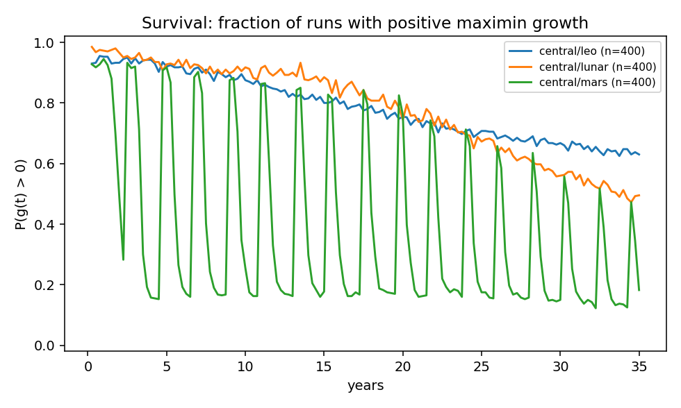

Figure 1. Survival curves, central assumption set: fraction of runs with positive realized maximin growth over time, by architecture. Ensemble frequencies under the stipulated assumption set, not empirical probabilities.

Balanced doubling is faster on the Moon but the endpoint is more sustained in LEO: among runs that ever reach λ ≥ 2, the central median is 5.0 years on the Moon versus 26.0 in LEO. These are balanced-capacity first passages, not construction records for complete second factories. LEO has no ore body, so growth is throttled by captured and recovered material. Recycling yield is below unity and recovery depends on loss type; recycling alone cannot fund net expansion. The LEO Earth-import-cut row therefore preserves capture feed and must not be described as autonomy. The lunar surface has regolith feed and can grow quickly when electronics permits, while the finite-response diagnostic assigns about 96% of central lunar co-binding credit to electronics. The spread is the result: current evidence does not close feasibility, but the model identifies the conditional measurements that would.

**Cut sets and the ensemble-frequent minimum cut.** At central anchor values no import cut set is fatal by year 30 anywhere — imports accelerate but are not load-bearing *at central values*. That statement misleads alone, because cuts appear near the feasibility margin. Over sampled anchors (n = 40 draws per cell), conditional on an otherwise-expanding draw, central lunar electronics and the all-import cut coincide in this regeneration; central LEO is more exposed to the feed loop as a whole than to electronics alone; and the small central Mars survivor set produces no fatal candidate cut in this regeneration. Exact conditional frequencies have moved materially across equally valid small-n regenerations. They are reported in `outputs/report_deep.md` for reproducibility, but the defensible claim is ordinal: cut dependence appears near the feasibility margin and is architecture-specific; this experiment does not estimate a stable real-world probability. Capacity knockouts at central values: the eight physical production sectors (power, mining, refining, robotics, machine tools, electronics, thermal, transport) are knockout-indispensable in both architectures tested; repair is additionally indispensable on the lunar surface. With LEO’s 5% capture feed, a recycling knockout is survivable at central values. The structural point is: the LEO architecture lives on recovered and captured mass (capture/mining receives 98% of central co-binding credit), so its dependency is the feed loop as a whole rather than any single import line.

**The clock-setting curve.** Expansion frequency against the e-folding time of Earth-supply withdrawal (n = 60 per grid point; machine-readable: Download original CSV (314 B)): on the lunar surface under central assumptions, the realized year-30 endpoint is 0.40, 0.57, 0.43, 0.57, and 0.73 at 4-, 7-, 10-, 15-, and 25-year e-folding times. The non-monotonic wobble is within binomial noise at this n. The experiment is suggestive of a penalty for withdrawing the umbilical faster than the closure ramp, with electronics stockpile shelf life as a plausible mechanism. At $n=60$ per point it does not estimate a stable response curve or its steepness; Figure 2 therefore preserves the observed sampling wobble.

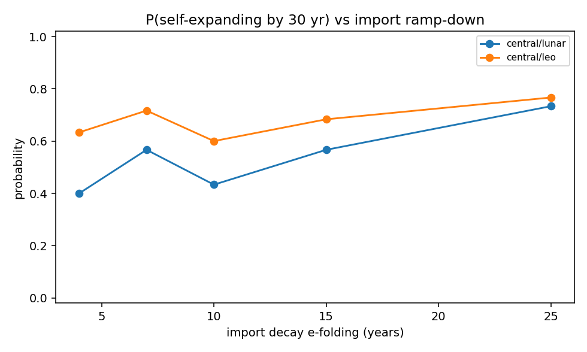

Figure 2. Expansion frequency at year 30 versus the e-folding time of Earth-supply withdrawal, central set, n = 60 per grid point. The wobble is within binomial noise at this n.

**Allocation-policy robustness.** The results above could in principle be an artifact of the myopic one-step maximin allocator — a forward-looking operator might accept lower current worst-case growth to build future capacity. Because the dynamics and balances are linear, the finite-horizon LP is solved exactly — though receding-horizon control remains an approximation to full-horizon optimization (truncation and terminal-value effects persist; an investment paying off after year six is invisible to a six-year window). On paired draws (identical parameter samples per policy, shocks off), a six-year receding-horizon maximin reproduces the myopic policy essentially exactly — 16/30 vs 16/30 sampled runs expanding on the lunar surface, 11/30 vs 11/30 in LEO, with co-binding shares computed under the same finite 1% response definition as the baseline. The absolute level is not stable at this small paired n — the lunar count has swung across equally valid regenerations, so the policy *equality* is the stable finding, not the level. The agreement holds because the maximin criterion already directs each step’s investment at the worst-off sector, which is the future bottleneck. A third policy, maximizing aggregate growth subject to no sector shrinking, collapses (0/30 in both architectures): worst-case allocation is load-bearing, not incidental. Bottleneck-first heuristics are subsumed by the maximin construction itself. The defensible conclusion is correspondingly scoped: under paired, shock-free draws for the tested LEO and lunar central cases, a six-year receding horizon did not materially change the outcomes; global allocation-policy robustness (longer horizons, perfect foresight, robust control under shocks) is not established — and the retooling analysis of Part IV exhibits one regime where allocation family genuinely matters. (`policies.py`; paired-draw comparison in `outputs/report_deep.md`.)

**Scalar-anchor sensitivity screening — with its scope stated.** The claim that the strategic-material gap and logistics penalty dominate is a computation, not an assertion, and it is a *scoped* one — central assumptions, lunar architecture, shocks off, scalar anchors only; it does not rank structural requirement-matrix uncertainty, policy choices, shock distributions, or interaction effects, and repeating it across environments and sets with interaction-capable methods remains open cross-environment work: Spearman rank correlation between each anchor’s shared draw and the worst-case growth rate at year 30 across the ensemble (n = 300, central/ lunar, shocks off; anchors are drawn independently, so per-anchor rank correlation needs no independence corrections beyond the null band of roughly ±0.11, wider under multiplicity). Two parameters tower above the band: the space-electronics closure fraction (ρ ≈ +0.80) and the space logistics penalty (ρ ≈ −0.48) — both ASSUMPTION-class, which is the epistemic point: within this scalar screen, variation in year-30 growth is dominated by exactly the two numbers no one has measured. Every other screened anchor sits at or near the null band. (`montecarlo.sensitivity`; ranked table in `outputs/report_deep.md`.)

**Integrated seed and aggregate-capacity results.** The integrated layer is a second, explicitly assumption-class model, not a relabeling of the ten-sector balanced-capacity runs. Structurally it is a two-stage hybrid: a multisector, multi-material seed-sizing LP, followed by sector-resolved capacity-growth dynamics. All 18 sector capacities retain their own commissioning lag, ramp, and depreciation; the continuous operating-cell equivalent is derived as the slowest normalized operating sector rather than advanced as the state. The published central trajectory orders balanced seed-composition packets for continuity, while diagnostics compare independent maximin-sector, surplus-preserving, shock-aware, and perfect-foresight allocation. Failures enter explicit repair queues whose return to service consumes parts, repair service, intervention capacity, and time. Construction and commissioning are cohort-resolved. A scenario is **LP-feasible** when the seed LP admits a solution satisfying every material, service, autonomy, intervention, and throughput constraint over the scenario horizon. The doubling metric is **first passage to two operating-cell equivalents** — a continuous aggregate crossing, not a discretely commissioned second factory. The year-40 and terminal-window endpoints are separate. Central deterministic scenarios and deterministic 200-draw assumption ensembles:

Table 12. Bootstrap architecture sizing and growth outcomes. Download original CSV (2 KB).

| bootstrap architecture | central minimum-mass installed seed | Earth strategic-material import stock (share of seed) | aggregate operating-capacity doubling, 80-year extension | sector-balanced cell-equivalents, year 40 | design-space occupancy (LP-feasible / 200) | feasible-draw seed p10 / p50 / p90 |
| --- | --- | --- | --- | --- | --- | --- |
| terrestrial closure rehearsal | 206.9 t | 48.1 t (23%) | — | 0.47 | 81/200 | 171 / 201 / 228 t |
| lunar strategic-material bridge | 217.0 t | 58.2 t (27%) | — | 0.54 | 126/200 | 181 / 212 / 248 t |
| strict lunar-only | infeasible | — | — | — | 0/200 | — |
| Moon–asteroid network | 187.9 t | 0.0 t | 35.25 yr | 3.28 | 187/200 | 156 / 207 / 322 t |

The occupancy column is a count under the declared log-uniform sampling measure. It is not a calibrated probability, posterior, or empirical success rate.

The strict lunar-only case is a structural infeasibility, not a sampled tail: the central LP is infeasible — the configured trace-material yields cannot supply the assumed electronics and process-equipment stack — and all 200 draws preserve that infeasibility, so 0/200 restates the structure rather than measuring an uncertainty. Substitution, a different electronics stack, a new refining route, or a richer measured deposit can change it; the result is not a proof that lunar-only industry is impossible. The Moon–asteroid case assumes a deliberately synthetic composite portfolio rather than a known accessible body: 187/200 states what a sufficiently diverse source network would have to supply, not that such a portfolio is accessible, jointly recoverable on the assumed timetable, or economical. In its central solution the Moon supplies 360.3 t/yr of feed and the asteroid portfolio 179.7 t/yr. Source occurrence [S51–S56] bounds plausibility; it does not validate recoverable yield, reserve, throughput, purity, or transfer cost. Figures 3 and 4 separate the installed-mass distributions from the resulting commissioning schedule.

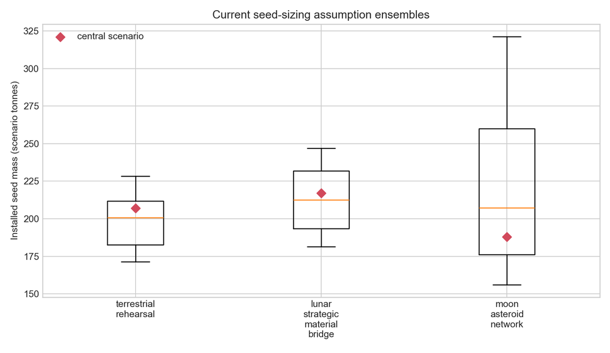

Figure 3. Installed seed mass across the 200-draw assumption ensembles, by scenario. Distributions describe the declared parameter box, not engineering uncertainty.

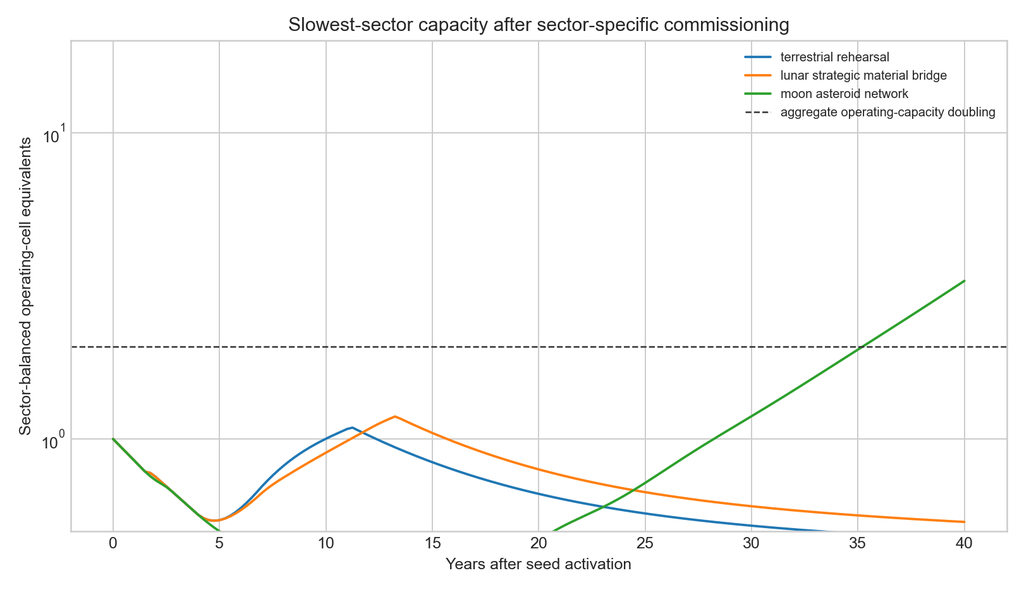

Figure 4. Operating cell-equivalents over time in the central scenarios: construction and commissioning lags separate ordering from operating capacity.

Figure 5 makes the limited timing benefit of scaling the unchanged seed composition visible.

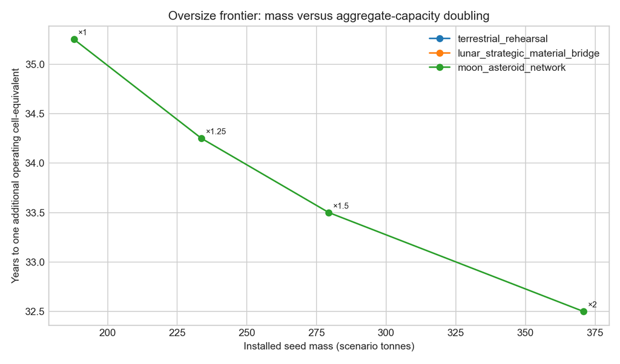

Figure 5. Oversize frontier: installed seed mass versus years to one additional operating cell-equivalent, central scenarios.

The coupled run distinguishes installed compute from the slowest-sector industrial aggregate. Figure 6 compares those endogenous trajectories with rate-limited Earth-fed deployment. At year 40, the Moon–asteroid scenario has 5.11 normalized total endogenous compute capacity while its balanced aggregate is 3.28; compute is an independently constrained sector rather than a copy of the scalar cell count. The run exports 0.66 normalized units to orbit. Constant-rate Earth-fed orbital deployment reaches 1.56, 2.81, or 4.99 units under the tight, base, and responsive rate cases. Those curves show the difference between rate-limited deployment and endogenous capacity growth under the configured coefficients; they do not forecast datacenter capacity.

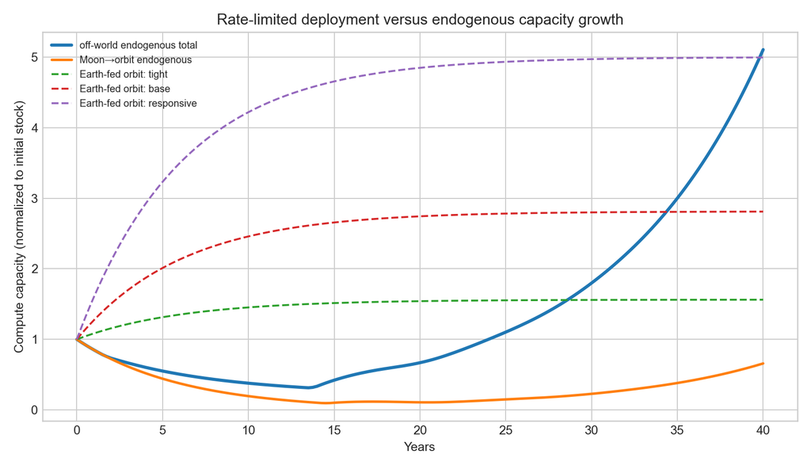

Figure 6. Rate-limited Earth-fed deployment versus endogenous capacity growth, normalized compute capacity under the configured coefficients.

The stateful debris stress test reports the **five-year fragment creation-to-clearance ratio** $R_{\mathrm{debris}}$ — fragments created divided by fragments cleared over the final five years, a flow ratio rather than a branching-process reproduction number:

Table 13. Debris creation and clearance under alternative deployment strategies. Download original CSV (534 B).

| deployment topology / mitigation | creation-to-clearance ratio, last 5 yr | fragment index, year 40 |
| --- | --- | --- |
| Earth-fed orbit / weak | 0.61 | 1.602 |
| Earth-fed orbit / strong | 0.35 | 0.284 |
| dense endogenous / weak | 4.40 | 3.179 |
| dense endogenous / strong | 3.97 | 1.687 |
| distributed endogenous / sparse topology | 1.00 | 0.000 |

A ratio above one means only that more fragments were created than cleared in the window; it is not a cascade threshold. Strong mitigation lowers the dense case’s fragment index (3.18 → 1.69) and its flow ratio (4.40 → 3.97), but neither output establishes shell safety. The sparse case’s exact 1.00 is a zero-stock boundary, not a computed equilibrium,[^1] and appears only under an assumed 0.01 collision-kernel multiplier. The result supports topology as a co-designed industrial constraint; it does not establish a safe orbit, validate a debris environment model, or locate a cascade threshold. Complete tables and figures are generated from the same run in `outputs/integrated/`; Figure 7 shows the stock trajectories behind the windowed ratios.

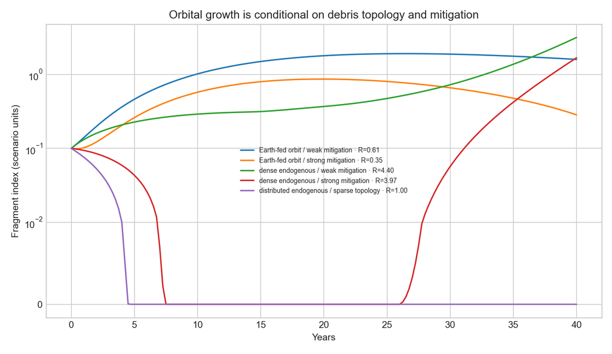

Figure 7. Fragment-index trajectories by deployment topology and mitigation: the debris stress test that produces the creation-to-clearance table above.

**What Part I establishes and does not.** It establishes structure: which sector binds, what the minimum cut is, how locations differ qualitatively (lunar fastest-doubling but hostage to the electronics cut; LEO feed-constrained but recycling-viable; Mars most path-dependent and import-fragile, with no normalized scalar robustness ranking), and where the feasibility margin lies — structure that survives the allocation-policy variation above. The integrated layer additionally establishes which declared material, autonomy, gravity, source, and commissioning constraints explain its own seed scenarios. Neither establishes point feasibility: both requirement matrices, element recipes and yields, strategic-material gap, repair efficiencies, stockpiles, autonomy coefficients, lags, source portfolio, and shock/debris rates are ASSUMPTION-class. Solar-array, regolith, sample, or satellite data do not establish the coupled behavior of mines, bearings, machine tools, electronics production, or dust-exposed radiators.

[^1]: Realized clearance is capped by the fragments available. When the stock is empty, the reported creation-to-clearance ratio lands at its boundary value even though no positive-stock equilibrium has been demonstrated.

## I.9 Development path, annotated

0. **Terrestrial autonomous-closure rehearsal.** Before launch, operate an integrated seed factory on Earth using only the material forms, energy intermittency, communications constraints, spares allowance, and production methods intended for the lunar deployment. Exclude routine human entry; route every human intervention through a logged maintenance interface; inject equipment faults and communication outages; and require the system to manufacture, assemble, calibrate, and commission a second production cell. This stage does not reproduce lunar gravity, vacuum, radiation, or abrasive dust, so environmental qualification remains separate. It does test whether the industrial graph and its encoded operating knowledge are autonomous enough to export. Report intervention hours per machine-hour, imported mass per unit of added local capacity, critical bill-of-material lines producible, autonomous recovery fraction, time to a commissioned second cell, and every remaining single-point dependency. The execution contract in `params/rehearsal_protocol.yaml` fixes the boundary, typed event schema, ten binary gates, threat-complete fault campaign, 30-day retained-cell test, and parameter-replacement rules. Its generated matrix remains entirely `execution_pending` or `data_pending`; it is a protocol, not a result.
1. **Earth-dependent operations.** Earth supplies vehicles, energy systems, consumables, spares, electronics, and nearly all machinery; space assets perform narrow missions.
2. **Local-resource supplementation.** Local water, oxygen, shielding, construction feedstock, and selected propellant inputs reduce imported mass without yet closing the industrial loop.
3. **Heavy-industry closure.** The network produces bulk metals, glass, ceramics, structural parts, tanks, simple mechanisms, roads, pads, and large power structures.
4. **Advanced-manufacturing closure.** It adds motors, actuators, sensors, precision tools, robots, spacecraft subsystems, computers, and factory machinery. Terafab is best read as a terrestrial rehearsal of this stage (Part III.2): advanced-manufacturing integration practiced on Earth before any attempt to export it.
5. **Self-sustenance.** Internal production replaces depreciation and failure across every mission-critical category; Earth supply becomes optional rather than load-bearing.
6. **Self-expansion.** The system builds more mines, refineries, factories, power systems, robots, transports, and compute than replacement requires.
7. **Intelligence-industry recursion.** Additional compute improves intelligence; improved intelligence raises industrial replication efficiency; higher output creates still more compute.

This is the implemented industrial branch of Equation (3): intelligence raises verified task coverage and replication efficiency; commissioned infrastructure adds usable compute; and that compute can support a further verified intelligence update.

The bridge economy maps onto the ladder: terrestrial products carry the early stages; launch and connectivity carry Stages 2–4; orbital compute is a candidate Stage 4–5 tread; and in-space industrial services carry Stages 5–6. The model adds stage warnings. The Stage 4→5 transition is where the strategic-material gap binds — no amount of Stage 3 bulk closure substitutes for an electronics tier. Stage 5 is location-dependent: LEO requires a sustained capture-and-recovery feed loop; under the present 5% capture assumption, recycling is valuable but not knockout-indispensable at central values. Mars requires electronics stockpiles engineered to synodic shelf life or a local electronics tier. The lunar surface has the fastest conditional balanced-doubling pathway when electronics closes sufficiently; LEO has the more sustained central endpoint under its continuing-capture assumption.

**Location sequence and the lunar hybrid.** The development ladder is not a ladder of orbital altitudes. In particular, *Sun-synchronous orbit* is a planet-centered orbit whose plane precesses to preserve approximately the same local solar time [S49]. The familiar dawn-dusk SSO is still LEO—the 650 km orbital-compute design assessed in Part II is an example—not the destination after a lunar surface base.

For closure, the more coherent topology is:

1. **LEO as a bridge, not the terminal reservoir.** Communications, observation, early compute, assembly demonstrations, and transport can earn revenue and test systems, but bulk growth remains exposed to finite imported/captured feed and density-dependent collision risk.
2. **Lunar surface as the material backbone.** Extraction, bulk refining, construction, durable storage, shielding, and long-life machinery use a physical foundation and local regolith. South-polar planning seeks the conjunction of long illumination intervals and access to shadowed volatile deposits, while leaving reserve size and extraction economics unresolved; dust and landing ejecta remain major surface penalties [S47].
3. **Sparse lunar/cislunar orbit as the service layer.** Communications, navigation, observation, reusable transports, depots, assembly, and selected compute occupy orbit only where zero-g or illumination benefits repay shielding, stationkeeping, and service costs. NRHO is a candidate gateway geometry designed for eclipse avoidance and low stationkeeping, not a substitute ore body or a passive maintenance-free base [S48].
4. **Distributed heliocentric expansion after lunar export closure.** Productive nodes then spread across separated Sun-orbiting trajectories and resource paths—potentially including near-Earth objects—rather than reproducing one dense shell. The point is diversity of orbital elements and feedstocks, not one privileged “solar orbit.” Moving inward raises solar flux but also heat-rejection, radiation, communications, and materials constraints, so no optimal solar radius is claimed.

**Material-source sequence.** The Moon is not chemically equivalent to Earth, but neither is it short of bulk machine-building elements. Its crust is dominated by oxygen, silicon, magnesium, iron, calcium, and aluminum, with smaller titanium-bearing and other phases; composition varies strongly between highlands and mare terrains [S51]. Those elements support oxygen, glass and ceramics, aluminum, iron-bearing alloys, silicon feed, shielding, structures, and many bulk machine parts, subject to extraction energy, purification, alloying, yield, and process-equipment constraints. The early system can therefore treat the lunar surface as a **bulk-material backbone** while importing low-mass, high-criticality **material vitamins** from Earth: advanced chips, dopants, catalysts, specialty chemicals, bearings, sensors, precision tools, metrology, and any alloying elements whose local recovery is not yet viable.

An order-of-magnitude inventory check prevents “no iron” from becoming a false premise. At an average regolith bulk density near 1.5 t/m³ [S52], one square kilometer excavated to one meter contains about 1.5 million tonnes of regolith. Applying the approximately 3 wt% iron reported for lunar highlands material [S53] gives roughly 45,000 tonnes of iron **in place**. This is an illustrative inventory, not an ore reserve: it says nothing about site homogeneity, mineral form, excavation losses, energy, recovery yield, environmental impact, economics, or how much is practically extractable. It does show why asteroid mining is not a prerequisite for initial lunar iron.

The harder question is diversity. Lunar carbon and nitrogen occur at low concentrations in returned fines, while polar water evidence remains spatially heterogeneous and does not yet provide a bankable reserve estimate [S54] [S55]. A robot-only ecology avoids agricultural and biosphere-scale demand, but it still uses volatiles and specialty elements for propellant, reduction chemistry, cooling, lubrication, polymers, process gases, electronics, and high-performance alloys. Carbonaceous asteroids and differentiated metal-rich bodies can eventually add water, carbon-bearing material, nickel, cobalt, and other feedstocks; returned Bennu material confirms carbon-rich organics and a history of water-related mineral chemistry in at least one carbonaceous body [S56]. Asteroids are therefore modeled as a **follow-on route to diversity and supply sovereignty**, not invoked as the first source of every machine metal.

Current demonstrations make individual conversion paths more concrete without closing the system. NASA describes integrated autonomous processing of regolith simulant into silicon solar cells, aluminum wire, oxygen, iron, and slag, alongside vacuum tests of molten-regolith electrolysis [S57]. These are meaningful subsystem demonstrations; they are not a lunar mine, an operational supply chain, a factory reproducing its own equipment, or an audited second production cell.

This ranks functions, not prestige destinations. Surface and orbit are complements: orbit is the transfer and service network; the surface supplies bulk matter and shielding. The ten-sector and Part II models cannot compare that hybrid directly: they isolate lunar-surface capacity, cislunar compute, and Earth-supplied lunar compute, and they aggregate elements into industries. The integrated layer adds material-category bills of material, source yields, Earth–Moon–orbit–asteroid arcs, and aggregate endogenous debris states. It therefore computes an explicit hybrid scenario, but its recipes, yields, transfer capacities, composite asteroid source, and collision kernels are declared assumptions. It does not establish lunar material sufficiency, a recoverable reserve, a launch date for asteroid supply, or an orbital safety case.

## I.10 Binding bottlenecks and failure modes

With model annotations:

- **Lithography and fabrication equipment** — the named residual chokepoint one layer below foundries, and the deepest single closure problem in this framework.
- **Reliability and repair** — the model makes mean-time-to-repair and spares closure first-class: repair is an explicit sector with an efficiency and a spares bill.
- **Thermal management** — radiators are launched mass; Part II’s radiator axis.
- **Energy storage and continuity** — the lunar night storage mass term; Mars dust-storm shocks.
- **Resource quality** — LEO has no ore body, so the sustained capture-and-recovery feed loop binds even though the separately modeled recycling sector is not knockout-indispensable at central values.
- **Verification and control** — Part III.4.
- **Political and legal environment.**
- **Economic survival of the transition** — Part II.1.
- **Concentrated coordination** — single points of failure a distributed competitor lacks.
- **Paradigm-shift stranding** — Part IV.3; exposure concentrated in the fabrication layer, while the fleet self-insures through its own 3–6-year depreciation.

# Part II — Comparative Economics

## II.1 The bridge economy

Each stage of the recursion must be independently profitable or deliberately financed: a staircase of self-supporting steps, not a single leap to closure. The first candidate tread is terrestrial output from the same machinery: vehicles, storage, and robots pay rent while turning the autonomous seed into an audited industrial experiment. Launch services and Starlink connectivity form the next tread by funding transport. Orbital compute, priced explicitly in II.2–II.4, could then become an anchor customer for launch, spacecraft production, power, thermal management, communications, silicon, autonomy, and servicing. In-space industrial services enter at higher closure.

The test of the staircase: at every stage, revenue plus strategic financing must exceed the burn required to reach the next stage before the clock-setting components of Part I.4 expire — and Part I.8 makes the clock concrete: the electronics stockpile shelf life against the import ramp. The commissioning trajectories in Figure 4 are the physical schedule that this bridge economy must finance.

Stage 0 has a second economic role. Building the candidate lunar industries first on Earth captures process knowledge, failure data, tool interfaces, simulation residuals, and commissioning procedures while the repair economy is still accessible. Selling terrestrial output can finance that learning, but the decisive deliverable is the measured ability to build and commission a second cell under lunar-palette and no-routine-entry constraints. A factory that is profitable yet requires tacit human rescue has not validated the exported loop.

The bridge-economy claim is therefore narrower than first-generation cost parity. Orbital compute could function as an industrial seed while remaining more expensive than Earth only if attributable learning, faster capacity activation, cross-program reuse, or declining external dependence earns the difference. Those terms receive no automatic credit in the levelized-cost model; II.2–II.4 price the delivered compute product, and the evidence needed to value shared-stack effects remains a separate measurement requirement.